# Fish

Meredith Osmond

## 1. Introduction

Proto Oceanic speaking communities subsisted on what they could grow and gather and what they could glean from the reef and sea.[^1]: Through their dependence on fishing, the inhabitants would have amassed knowledge of the environments favoured by particular fish, and awareness of fish habits as they related to such things as season of the year, the lunar and diurnal cycle, tidal movements, winds and currents. The times of certain fish to be fat, to be abundant, and to aggregate in a certain spot for spawning or feeding would have been marked.

This chapter deals mainly with the names of fishes. Paul Geraghty (1994) and Robin Hooper (1994) have provided a substantial starting point with their work on reconstructing fish names for Proto Central Pacific and Proto Polynesian respectively. Their data and lower-level reconstructions are reproduced here when included in a higher level reconstruction. Otherwise I simply record the existence of a PCP or PPn reconstruction.

In most Oceanic languages the lexicon of fish names is the largest of all faunal fields. The lists of local fish names available to me include almost 300 items for Mbunai Titan in the Admiralties (Akimichi & Sakiyama 1991), over 400 for both Marovo in the NW Solomons (Hviding 1996), and Wayan Fijian (Pawley & Sayaba 2003), 250 for Kapingamarangi in Polynesia (Lieber 1994) and around 400 for Satawalese in Micronesia (Akimichi & Sauchomal 1982). The evidence is overwhelming that knowledge of fish is, or has been until the breakdown of traditional lifestyles, extremely detailed, and one not restricted to a small group of people, but widespread among the majority of Oceanic communities.

A preliminary question that arises is: Do varieties of fishes in the tropical Pacific diminish in number the further one moves east from the major land masses? From linguistic evidence alone it appears that the major families continue to be represented throughout the region, but the number of genera and species diminishes. The greatest number of families noted in a wordlist available to me is from one of the more remote locations.[^2]:

Davis’s (1999) listing for Chuuk records 71 of the 78 families included in my survey.[^3]: Leach & Davidson (2000) have considered the question from an archaeological perspective. From fish remains identified from 24 different island groups in the tropical Pacific they list 48 families that were taken in any quantity by prehistoric people (p.414). Although they note signs of regional specialisation, they write that this ‘cannot be explained by changes in natural abundance of fish types from one place to another’ but is due rather to aspects of human behaviour (p.416). Thus it should be possible to reconstruct terms to at least the taxonomic level of family from the full range of linguistic subgroups including Micronesia and Polynesia, notwithstanding that the range of environment declines. This is in contrast to the land-based flora and fauna.

Although I have used western taxonomy as the basis of my classification, it should not be assumed that all Oceanic peoples used a similar system of organization. As an example, Edvard Hviding describes the system used by the people of the Marovo Lagoon, on the island of New Georgia, western Solomons. He writes:

> Marovo fish taxonomy has a structure that differs considerably from Linnaean or western scientific taxonomy. For instance, a number of Marovo fish taxa are highly general “lump” categories that cover a considerable number of Linnaean species under one name. The *temi kepe* (etymology uncertain) covers, without further specification, all (in western terms) ‘butterflyfish’ and ‘coralfish’, as well as any number of similar small, colorful reef fish with high and flat bodies. On the other hand, one Linnaean species may be subdivided in Marovo into a great number of named subtypes. One example is the skipjack tuna or makasi, which in Marovo has more than a dozen specific names that refer to growth stages, colorings, and more. Important food species are often finely subdivided in such a manner, in three-to-four-level taxonomic structures, while insignificant fishes, such as the small reef species just mentioned, are more commonly “lumped”. This does not imply that Marovo fishers do not generally and readily distinguish between similar looking fish species. They have names for at least four hundred Marovo “species”, and experienced people can easily single out and identify by name closely related fishes that differ only very subtly in color or general appearance. For example, at least twelve types of medium-sized parrotfish (no generic term in Marovo) are classified and named, as well as more than seventeen ‘trevallies’ [Carangids: *mara*] and at least twenty ‘groupers’ [Serranids: *pajara*] (Hviding 1996:192-193).

Primary lexemes can denote a fish at the species, the genus or the family level, and occasionally, as with sharks and rays, suborders or even orders. Particular species are more likely to be separately named if they are distinctive in appearance, like the bump-headed parrotfish, or valued food, like the great barracuda. At the species level or lower, names are more likely to be binomial. Some may be multimorphemic, reflecting attributes such as similarity of appearance, habit (schooling or not), environment (e.g. bottom-dwellers, pelagic, fresh-water, estuarine, reef or deep sea dwellers), whether diurnal or nocturnal, and nastiness (poisonous to eat, stingers). Distinctive appearance may be reflected, with terms for head, nose, eye, spikes, filaments, similarity to sail or palm leaf and so on being incorporated into the name. In Polynesian languages some colour terms, particularly reflexes of PPn *tea ‘white’, *quli ‘black’, *kefu ‘reddish-brown’, *kula ‘red’ and *mea ‘reddish’, are quite common. Wayan Fijian has *kati ni tanive*, lit. ‘biter of sardines’ for a medium sized trevally, after its feeding habits, while a scorpionfish whose poisonous spines can inflict severe pain is called *taŋitaŋi ga ua*, lit. ‘cry until high tide’. Niuean calls a species of parrotfish *mohe-aho* lit. ‘sleep by day’. Valued fish and fish whose appearance changes with age will often have names for particular growth stages. In Tonga, for instance, a species of mullet (*Valamugil cunnesius*) has six named stages, ranging from smallest to largest, *teʔevela*, *teʔekona*, *teʔefō*, *ʔunomoa*, *kanahe*, and *kanahe fau*.

A common difficulty in reconstructing the semantic range of a term is that although apparent cognate names may exist in, say, the Admiralties, the Solomons and Polynesia, the fishes bearing these names may belong to different species or genera. While some species are widespread, others are highly restricted in their geographic range, and the name of a fish in the Admiralties may well be given elsewhere to another species within the same family, or to an unrelated fish that resembles it in some aspect. As well, the western scientific taxonomy of fishes is subject to continuing revision and occasional name replacement. These are problems both for the wordlist compiler in identifying a fish by its Linnaean classification in addition to its common name, and for ourselves in tracing the somewhat fluid species association that a cognate set may produce.

## 2. Organisation

The cognate sets that follow are grouped in terms of Linnaean families and high order groupings. The ordering of groups substantially follows that of Ian Munro (1967) in his encyclopaedic volume *The Fishes of New Guinea*. However, since then there have been numerous revisions to fish taxonomy. In particular, I have been guided by the FishBase website (Froese & Pauly 2010) in tracing synonyms and revised scientific classification. Dictionary identifications have been retained, with any revision of terminology added in square brackets.

For descriptions of fish appearance and behaviour I have also relied heavily on Munro (1967) and Allen & Swainston (1993).

Terms for fish parts are included in this chapter. Marine mammals have been included in chapter 5.

## 3. Fish (generic)

It is likely that the POc term *ikan had both a narrow and a broad sense. The narrow sense applied to ‘typical’ fish, while the broad sense included some or all of the following: whales, dolphins, dugongs, eels, turtles, cephalopods and rays. Shellfish are generally excluded in daughter languages. See chapter 8 for a fuller discussion.

| **PAn** |  | *Sikan | ‘fish’ (ACD) |
| --- | --- | --- | --- |
| **PMP** |  | *hikan | ‘fish’ (ACD) |
| **POc** |  | *ikan | ‘fish (generic)’ |
| Adm | Nyindrou | *ni* | ‘fish’ |
| Adm | Lenkau | *nik* | ‘fish, excl. turtle, dolphin etc.’ |
| Adm | Penchal | *nii* | ‘fish, including turtle, dolphin, whale, octopus’ |
| NNG | Gitua | *iga* | ‘fish’ |
| NNG | Manam | *iʔa* | ‘fish’ |
| NNG | Takia | *i* | ‘fish’ |
| NNG | Yabem | *i* | ‘fish’ |
| PT | Ubir | *ian* | ‘fish’ |
| PT | Dobu | *iana* | ‘fish’ |
| PT | Tawala | *iyana* | ‘fish’ |
| PT | Kilivila | *yena* | ‘fish’ |
| MM | Ramoaaina | *ian* | ‘fish’ |
| MM | Nakanai | *ia* | ‘fish (generic)’ |
| MM | Mono-Alu | *iana* | ‘fish’ |
| MM | Roviana | *iɣana* | ‘fish (generic)’ |
| MM | Marovo | *iɣana* | ‘generic for all free-swimming creatures (e.g. fish, eels, stingrays, dolphins, whales, squids, jellyfish)’ |
| SES | Gela | *iɣa* | ‘a creature of the sea: fish, mollusc, crayfish, whale, squid, sea anemone, etc.’ |
| SES | ’Are’are | *iʔa* | ‘fish (generic)’ |
| SES | Sa’a | *iʔe* | ‘fish’ |
| SES | Arosi | *iʔa* | ‘fish, including sharks, rays, porpoises and possibly other main animals’ |
| SES | Lau | *iʔa* | ‘fish; any sea creature’ (Akimichi 1978:307 includes e.g. dugong, porpoise and whale) |
| SES | Kwaio | *iʔa* | ‘fish, porpoises, whales’ |
| NCV | Mota | *iɣa* | ‘fish’ |
| NCV | Raga | *iɣe* | ‘fish, including whales and porpoises but not eels, seasnakes, octopus, squid, cuttlefish jellyfish or balolo worms’ |
| NCV | Ambae | *ige* | ‘typical fishes, rays and dolphins but not sharks and whales (which are grouped together), eels or cephalopods’ (Hyslop, pers. comm.) |
| NCV | Nguna | *na-ika* | ‘fish’ |
| NCal | Nemi | *nuk* | ‘fish’ |
| NCal | Cèmuhî | *îkua* | ‘fish’ |
| Mic | Kiribati | *ika* | ‘fish: all swimming marine creatures including turtles, dugong, whales and porpoises, but not squid or octopus’ |
| Mic | Woleaian | *ix(a)* | ‘fish’ |
| Mic | Chuukese | *īk* | ‘general name for fish’ |
| Mic | Puluwatese | *yīk, yikan* | ‘fish, porpoises, whales, but not squid’ |
| Fij | Rotuman | *iʔa* | ‘fish: including also turtles, whales, alligators, etc., but not crabs, shellfish, etc.’ |
| Fij | Wayan | *ika* | (i) ‘fish, including eels, cetaceans, turtles and sometimes cephalopods’; (2) ‘true fish’ |
| Fij | Bauan | *ika* | ‘fish, including also eels, turtles, cetaceans, cephalopods’ |
| Pn | Tongan | *ika* | ‘fish, including also turtles (*fonu*) and whales (*tofuaʔa*) but not eels, cuttle-fish or jelly-fish’ |
| Pn | Niuatoputapu | *ika* | ‘fish, including eels, turtles, cetaceans, cephalopods’ |
| Pn | Niuean | *ika* | ‘fish, whales and dolphins’ |
| Pn | Rennellese | *ika* | ‘fish, turtle’ |
| Pn | Samoan | *iʔa* | ‘fish (including turtles and whales)’ |
| Pn | Tikopia | *ika* | ‘general category with reference to fish, but including allied creatures like turtle, cetaceans’ |
| Pn | Ifira-Mele | *ika* | ‘fish, whale, porpoise but not turtles, eels or octopus’ |
| Pn | Rarotongan | *ika* | ‘fish (generic)’ |
| Pn | Tahitian | *iʔa* | ‘fish, including porpoise, whale, turtle, octopus’ |
| Pn | Māori | *ika* | ‘fish’ |
| Pn | Hawaiian | *iʔa* | ‘fish or any marine animal, as eel, oyster, crab, whale; meat or any flesh food’ |

## 4. Sharks: Carcharhinidae, Sphyrnidae etc

In this section and in §5 on rays, I am dealing with sub-orders rather than families. Kailola (1987-1991) lists twelve shark families, the best-known probably being Carcharhinidae, the largest, with tiger sharks, black-tip and white-tip sharks among its species, and Sphyrnidae, hammerheads.

Most sharks inhabit shallow coastal waters around reefs. A number of species are regarded as dangerous, but in parts of the southeast Solomons sharks are thought to be the ghosts of men and are considered sacred. I have reconstructed one possible generic term, *bakewa, its cognates widespread, but undergoing a change of meaning in Central Pacific. Reflexes of *maŋewa have replaced *bakewa as the generic term in Polynesia. In Motu and Fiji the reflex of a POc term for shark has come to be applied instead to the remora or sucker fish which attaches itself to sharks and other large sea creatures (§65). This is the case with Motu *maɣoa* and PCP *bakewa. Tolai *gul* can be used to refer to either a ‘k.o. striped shark (tiger shark?)’ or ‘the pilotfish *Naucrates ductor*’, a fish which also stays in the close vicinity of sharks.

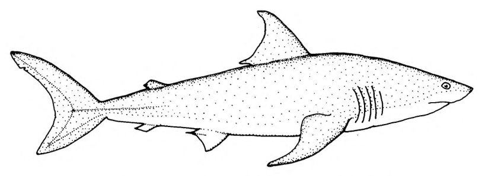

**Figure 2.1:** *Carcharodon carcharias*, great white shark

Proto Oceanic speakers undoubtedly distinguished many different species of sharks by name, as contemporary Oceanic speech communities do, but reconstructed terms have not been clearly identified with particular species at a level higher than Proto Central Pacific.

Cognates in the following set from the Admiralties, Papuan Tip, SE Solomons and Micronesia provide the strongest evidence for *bakewa as the generic term for ‘shark’ in POc.

| **POc** |  | *bakewa | ‘shark (generic)’ |
| --- | --- | --- | --- |
| Adm | Mussau | *baio* | ‘shark’ |
| Adm | Loniu | *pew* | ‘shark, generic. Used as first element in compound terms for kinds of’ |
| Adm | Nyindrou | *beʔeu* | ‘shark’ |
| Adm | Titan | *peu* | ‘shark’ |
| Adm | Lenkau | *paheu* | ‘shark (generic)’ |
| NNG | Yabem | *yakʷa* | ‘shark’ |
| NNG | Kove | *vaɣewa* | ‘shark’ |
| NNG | Bariai | *bakewa* | ‘shark’ |
| NNG | Wogeo | *bagewa* | ‘shark’ (*g* for †*k*) |
| PT | Wedau | *vaɣewa* | ‘shark’ |
| PT | Duau | *baewa* | ‘shark’ |
| PT | Misima | *baewa* | ‘shark (generic)’ |
| PT | Sinaugoro | *baɣewa* | ‘shark’ |
| MM | Patpatar | *baiawa* | ‘shark’ |
| MM | Lungga | *baɣea* | ‘shark’ |
| SES | Gela | *baɣea* | ‘k.o. shark, basking shark’ |
| SES | Gela | *bake-bake* | ‘*Carcharhinus melanopterus*, blacktip reef shark’ |
| SES | Lau | *baekʷa* | (i) ‘general term for shark’; (2) ‘any dreaded animal, crocodile, swordfish, poisonous snake etc’ |
| SES | Arosi | *baʔewa* | ‘shark. The shark was sacred. Men had familiar sharks which killed their enemies. A man and a shark sometimes exchanged souls’ |
| SES | Sa’a | *paʔewa* | (1) ‘shark’; (2) ‘generic term for all sea-ghosts, incarnations where sharks or swordfish or gropers are in question’ |
| SES | Kwaio | *baʔekʷa* | ‘shark (generic)’ |
| SES | Kahua | *pagewa* | ‘shark (generic)’ |
| NCV | Loh | *pəɣewa* | ‘shark’ |
| NCV | Mota | *paɣoa* | ‘shark’ |
| NCV | Mwotlap | *baɣo* | ‘Carcharhinidae spp.’ |
| NCV | Namakir | *bake* | ‘shark’ |
| NCV | South Efate | *pako* | ‘shark’ |
| SV | Ura | *(u)beu* | ‘shark’ |
| SV | Anejom̃ | *ne-pɣev* | ‘shark’ |
| Mic | Kiribati | *bakoa* | ‘shark (generic)’ |
| Mic | Marshallese | *pako* | ‘shark’ |
| Mic | Ponapean | *pako* | ‘shark (generic)’ |
| Mic | Woleaian | *paxow* | ‘shark’ |
| **PCP** |  | *bakewa | ‘k.o. fish that accompanies sharks’ |
| Fij | Bauan | *bākewa* | ‘remora or sucking fish’ |
| **PPn** |  | *pakewa | ‘*Carangoides orthogrammus*’ (Hooper: *Carangoides orthogrammus*) |
| Pn | Tuvalu | *pakeva* | ‘fish sp., *Carangoides orthogrammus*’ |
| Pn | Pukapukan | *pakeva* | ‘*Carangoides orthogrammus*’ |
| Pn | Takuu | *pakeva* | ‘name of principal sea deity’ |
| Pn | Tokelauan | *pakeva* | ‘black-spot jack, *Carangoides orthogrammus*’ |
| Pn | Tuamotuan | *pakeva* | ‘k.o. fish’ |

cf. also:

| TM | Buma | *boe~bʷoe* | ‘shark’ |
| --- | --- | --- | --- |

In Polynesian languages, reflexes of PPn *pakewa usually refer to a trevally (belonging to the same family as *Naucrates ductor*, the pilot fish), while reflexes of PPn *maŋō are the generic term for shark.

The next reconstruction, POc *maŋewa ‘shark’, appears to be a variant of *bakewa in which the stops are replaced by nasals. It is impossible to know how such a variant might have arisen, but the probability of two formally parallel homonymous trisyllables arising by chance is extremely low (Nichols 1996:50-51).

The reconstruction *maŋewa assumes that segment coalescence has occurred in both Motu and the SES languages. Motu *maɣoa* reflects coalescence of *-ew- as *-o-*, SES *maŋeo* coalescence of *-wa as *-o*. Note that a similar change occurred in NCV and Micronesian reflexes of *bakewa.

| **POc** |  | *maŋewa | ‘k.o. shark’ |
| --- | --- | --- | --- |
| PT | Motu | *maɣoa* | ‘suckerfish: *Phtheirichthys lineatus*, *Echeneis naucrates*, *Remora remora*’ |
| MM | Tomoip | *maŋ(gel)* | ‘shark’ |
| MM | Tolai | *moŋ* | ‘common shark, *Carcharinus* sp.’ |
| SES | To’aba’ita | *maŋeo* | ‘sp. of small shark’ |
| SES | Lau | *maŋeo* | ‘k.o. sea snake’ (also *baekʷa* ‘shark’, *baekʷa i asi* ‘sea snake’) |
| **PPn** |  | *maŋō | ‘general term for shark spp.’ (Hooper 1994) |
| Pn | Niuean | *maŋō* | ‘shark (generic)’ |
| Pn | Pukapukan | *maŋō* | ‘shark (generic)’ |
| Pn | Rennellese | *maŋō* | ‘shark (generic)’ |
| Pn | Samoan | *maŋō* | ‘k.o. shark’ |
| Pn | Tuvalu | *maŋō* | ‘shark’ |
| Pn | Tokelauan | *maŋō* | ‘shark’ |
| Pn | Kapingamarangi | *moŋo(henua)* | ‘grey shark’ |
| Pn | Tikopia | *maŋō* | ‘shark (generic)’ |
| Pn | Tahitian | *maʔo* | ‘shark (generic)’ |
| Pn | Māori | *maŋō* | ‘shark (generic)’ |
| Pn | Hawaiian | *manō* | ‘shark (generic)’ |

cf. also:

| Mic | Puluwatese | *məŋo(wur)* | ‘k.o. shark’ |
| --- | --- | --- | --- |

Reflexes of *kʷarawa serve as a generic term in parts of WOc, but in Polynesia refer to specific species.

| **POc** |  | *kʷarawa | ‘k.o. shark’ |
| --- | --- | --- | --- |
| NNG | Gitua | *arawa* | ‘shark’ |
| NNG | Kove | *kaluɣa* | ‘shark’ (borrowed from Bali below?) |
| NNG | Mutu | *korau* | ‘generic for several shark spp.’ |
| PT | Dobu | *kʷalawa* | ‘shark, general name’ |
| PT | Muyuw | *kʷaw* | ‘shark’ |
| PT | Kilivila | *kʷau* | ‘shark’ |
| PT | Lala | *olava* | ‘shark (generic)’ |
| PT | Motu | *karava* | ‘k.o. fish’ |
| MM | Bali | *kaluɣa* | ‘shark’ |
| MM | Vitu | *kaliɣa* | ‘shark’ |
| NCal | Nixumwak | *ārau* | ‘k.o. shark’ |
| Fij | Rakiraki | *karawa* | ‘*Isurus*, mako shark’ (Paul Geraghty pers. comm.) |
| **PPn** |  | *qalawa | ‘k.o. shark’ |
| Pn | East Uvean | *ʔalava* | ‘*Carcharhinus limbatus*, black-tipped shark’ |
| Pn | Tongan | *ʔalava* | ‘k.o. shark’ (marked with a wavy stripe) |
| Pn | Rennellese | *ʔagaba* | ‘large shark, probably black-tip or mullet shark, *Carcharhinus melanopterus*’ |
| Pn | Samoan | *alava* | ‘k.o. shark’ |
| Pn | Tuvalu | *alava* | ‘*Carcharhinus longimanus*, white-tipped shark’ |
| Pn | Kapingamarangi | *alawa* | ‘*Carcharhinus longimanus*, Oceanic white-tipped shark’ |
| Pn | Māori | *arawa* | ‘k.o. shark’ |

Geraghty (p. 143) also lists PCP *qaso ‘k.o. large shark, *Carcharhinus* sp.’ If the Taiof and Halia terms below are cognate, then POc *kaso(r,R) is reconstructable.

| **PCP** |  | *qaso | ‘k.o. large shark’ |
| --- | --- | --- | --- |
| Fij | Bauan | *yaso* | ‘k.o. shark, male, savage, big belly, short body’ |
| **PPn** |  | *qaso | ‘shark sp.’ (Hooper 1994) |
| Pn | Tongan | *ʔaho* | ‘k.o. shark’ |
| Pn | Pukapukan | *ayou* | ‘large deep-sea shark’ (final *-u* irregular) |
| Pn | Samoan | *aso* | ‘*Carcharhinus*, white-tipped shark’ (Rensch 1999: 19) |
| Pn | Tokelauan | *aho* | ‘huge, clumsy grey deep-sea fish about 5 metres long, probably shark family’ |
| Pn | Māori | *aho-aho* | ‘a fish’ |

cf. also:

| MM | Taiof | *kas* | ‘shark’ |
| --- | --- | --- | --- |
| MM | Halia | *kosoro* | ‘brown man-eating shark, plentiful around Nissan and associated with sorcery’ |

Languages frequently use binomial terms to refer to particular shark species, although sometimes the generic first element is regarded as optional. Fijian (unspecified) uses *gio*[^4]: + modifier, e.g, *gio uvi* ‘*Carcharhinus plumbeus*, sandbar shark’, *gio daniva* ‘*Galeo cerdo*, tiger shark’, *gio uluvai* ‘hammerhead shark’ (Geraghty pers. comm.). Modifiers tend to develop independently in different languages, although elements recur. Two of the Fijian modifiers, *uvi* and *daniva*, are found also in Polynesian terms, PPn *nai-ufi ‘k.o. large shark, probably tiger or grey reef shark’ and PPn *tanifa ‘tiger shark’. The latter is remarkably a reflex of POc *tanipa ‘sardine’ (§7), presumably because of similar iridescent zigzag vertical lines on both tiger sharks and sardines (Geraghty 1994: p. 143).

Probably because of similar wavy iridescent lines on the sides of Spanish mackerel, also a large predatory fish, reflexes of POc *taŋiRi ‘Spanish mackerel’ (§57) have been incorporated into names for a kind of shark in Muyuw (PT) and Marovo (MM).

| PT | Muyuw | *tagili gal* | ‘shark’ |
| --- | --- | --- | --- |
| MM | Marovo | *kiso taŋiri* | ‘*Galeocerdo cuvier*, tiger shark, the most dangerous shark in Marovo’ |

An obviously descriptive name, PCP *mata qi taliŋa ‘eyes of ears’ is used in Central Pacific languages to refer to the hammerhead shark, although the term has been lost in Eastern Polynesian. In Molima (PT), this shark is referred to as *mala balabala*, literally ‘eyes crosswise’, while in Gela (SES) it is *baɣea papala vohe* ‘paddle-handle shark’.

## 5. Rays: stingrays (Dasyatidae), eagle rays (Myliobatidae), manta rays (Mobulidae)

Stingrays and eagle rays inhabit sandy bottoms in the vicinity of coral reefs, and are common in estuaries where there is abundant mud. Eagle rays are so named because of their wide flaps and ability to leap from the water. Manta rays rank among the largest known fishes. They are specialised in having largely abandoned the bottom-living habit and usually swim near the surface, often leaping from the water. Manta rays inhabit open ocean, and are seldom seen near shore.

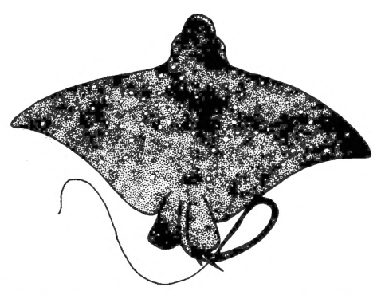

**Figure 2.2:** *Aetobatus narinari*, spotted eagle ray

Reflexes of POc *paRi are numerous and widespread. It seems that the POc term had both a generic and a specific sense. Although most of the reflexes listed below are glossed ‘stingray’, *paRi is used as the first element in compound terms for rays other than stingrays (see *paRi-manuk below). The same pattern occurs in Marovo (NW Solomonic) where *tape* is the term both for stingrays and other rays in general, giving rise to compounds like *tape kurukuru* ’spotted eagle ray, *Aetobatus narinari*`.

Oceanic languages usually distinguish several taxa, typically binomials, *paRi + modifier.

| **PAn** |  | *paRiS | ‘stingray’ (ACD) |
| --- | --- | --- | --- |
| **POc** |  | *paRi | (1) ‘stingray’; (2) ‘ray (generic)’ |
| Adm | Mussau | *pe* | ‘stingray’ |
| Adm | Titan | *pei* | ‘ray’ |
| Adm | Nali | *pei* | ‘stingray’ |
| Adm | Bipi | *pay* | ‘stingray’ |
| Adm | Wuvulu | *pai* | ‘stingray’ |
| Adm | Nyindrou | *bei* | ‘stingray’ |
| NNG | Gitua | *par* | ‘stingray’ |
| NNG | Manam | *paru* | ‘stingray’ |
| NNG | Bariai | *pali* | ‘stingray’ |
| NNG | Mangap | *par* | ‘stingray’ |
| PT | Dobu | *ali* | ‘stingray’ |
| PT | Molima | *vali* | ‘stingray’ |
| PT | Tawala | *wali* | ‘stingray’ |
| PT | Kilivila | *vai* | ‘stingray’ |
| MM | Tolai | *var* | ‘fish of the ray species’ |
| MM | Minigir | *vari* | ‘stingray’ |
| MM | Tabar | *vari* | ‘stingray’ |
| MM | Patpatar | *har* | ‘ray’ |
| MM | Roviana | *vari* | ‘wood rasp’ (from skin of sandpaper ray?) |
| MM | Marovo | *vari(popolo)* | ‘bull ray, *Mylobatus* sp.’ |
| SES | Gela | *vali* | ‘ray, skate’ |
| SES | Arosi | *hari* | ‘a fish, ray’ (*mara-hari* ‘k.o. shark’) |
| SES | Lau | *fali* | ‘general term for rays’ |
| SES | Kwaio | *fali* | ‘ray (fish) (generic)’ |
| NCV | Mota | *var, vari* | ‘stingray’ |
| NCV | Ambae | *vari* | ‘stingray’ |
| NCV | Raga | *vari* | ‘blue-spotted stingray’ |
| SV | Sye | *(u)var* | ‘stingray’ |
| SV | Ura | *(u)var* | ‘stingray’ |
| NCal | Nemi | *pe* | ‘stingray’ |
| NCal | Ajië | *pe* | ‘stingray’ |
| NCal | Xârâcùù | *pe* | ‘stingray’ |
| NCal | Iaai | *ve* | ‘stingray’ |
| Mic | Puluwatese | *fœyi* | ‘ray fish’ |
| Mic | Woleaian | *fai(ya)* | ‘file (a tool); rayfish (general term)’ |
| Fij | Rotuman | *hai* | ‘stingray’ |
| Fij | Bauan | *vai* | ‘a ray or skate’ |
| Fij | Wayan | *vai* | ‘generic for stingrays, manta or devil rays and eagle rays’ |
| **PPn** |  | *fai | ‘stingray, general term’ |
| Pn | Tongan | *fai* | ‘skate or stingray’ |
| Pn | East Uvean | *fai* | ‘stingray’ |
| Pn | Samoan | *fai* | ‘stingray’ |
| Pn | Pukapukan | *wai* | ‘stingray’ |
| Pn | Rennellese | *hai* | ‘generic for rays and skate-like fishes’ |
| Pn | Tikopia | *fai* | ‘various rays’ |
| Pn | Tahitian | *fai* | ‘stingray’ |
| Pn | Hawaiian | *hai(lepo)* | ‘stingray’ |

| **PMP** |  | *paRih manuk | ‘? ray’ (presumably ‘eagle ray’) (ACD) |
| --- | --- | --- | --- |
| **POc** |  | *paRi-manuk | ‘*Aetobatus narinari*, spotted eagle ray’ (*manuk ‘bird’) |
| PT | Dobu | *ali manu(wa)* | ‘eagle ray’ |
| MM | Patpatar | *har man* | ‘spotted eagle ray’ |
| **PEOc** |  | *vaRi manu | ‘*Aetobatus narinari*, eagle ray’ (Geraghty 1990) |
| SES | Kwaio | *fali manu* | ‘manta ray’ |
| SES | ’Are’are | *hari manu* | ‘spotted eagle ray’ |
| SES | Arosi | *hari manu* | ‘eagle ray’ |
| SES | Bauro | *hari manu* | ‘eagle ray’ |
| Fij | Bauan | *vai manu* | ‘skate or ray’ |
| **PPn** |  | *fai-manu | ‘*Aetobatus narinari*, eagle ray’ (Hooper 1994) |
| Pn | Tongan | *fai manu* | ‘eagle ray’ |
| Pn | Samoan | *fai manu* | ‘ray sp.’ |
| Pn | Tuvalu | *fai manu* | ‘spotted eagle ray’ |
| Pn | Kapingamarangi | *hai manu* | ‘*Aetobatis* sp., eagle ray’ |
| Pn | Tahitian | *fai manu* | ‘eagle ray’ |
| Pn | Māori | *whai manu* | ‘eagle ray’ |

Banks Islands languages (North Vanuatu) support Proto Banks *vaRi mala ‘eagle ray’, where the term for ‘hawk’ rather than ‘bird’ is the modifier (Alexandre François, pers. comm.).

Reflexes of POc *Ropok ‘to fly’ are sometimes used in compounds to distinguish rays that leap from the water. Examples are Nakanai (MM) *kova lovo-lovo* ‘ray with two wings’ (*kova* ‘stingray’) and Gela (SES) *vali-lovo* ‘eagle ray, manta ray, devil ray’.

Lower level reconstructions include PCP **vai bekʷa*, PPn *fai peka* ‘*Aetobatus narinari*, spotted eagle ray’ (PCP *bekʷa ‘bat’) (Geraghty 1994: p. 144); PPn *fai kili* ‘sandpaper ray’ (probably Himantura granulata, Dasyatidae) (*kili ‘file’); and PNPn *fāfā-lua* ‘*Manta birostris*. manta ray’ (lit. ‘full of holes’, presumably a description of the pitted appearance of the skin), the latter two from Hooper (1994: p. 197).

## 6. Bonefishes (Albulidae) and tarpons (Elopidae, formerly Megalopidae)

Bonefishes are coastal fishes, moderately sized and brilliantly silver, which often congregate in large schools. They are generally valued as food, but have many fine bones. Tarpons are also moderately large coastal game fishes which ascend rivers in search of food. The flesh is tough, with numerous fine bones. They are renowned as active strong fighters capable of swift movement, leaping ability and great endurance (Munro 1967: p.41).

The two families are treated together because the second reconstruction below, POc *pu-pulan, is based on cognates referring to both and seems a broader term than POc *kuRo, bonefishes and tarpons are similar in colour and habitat, and both are marked by the presence of many fine bones.

| **PMP** |  | *kuRaw | ‘edible marine fish’ (ACD: PWMP *kuRaw) |
| --- | --- | --- | --- |
| **POc** |  | *kuRo | ‘bony fish, probably *Albula*’ |
| MM | Tolai | *kura* | ‘k.o. fish’ |
| SES | Gela | *gulo* | ‘k.o. fish’ |
| NCal | Nyelâyu | *yhu* | ‘*Albula vulpes*’ |
| Mic | Puluwatese | *kuwɔ* | ‘k.o. small fish’ |
| Fij | Rotuman | *ʔuo* | ‘*Albula*’ |
| Fij | Bauan | *(yawa)kio* | ‘*Albula*’ (*yawa* ‘*Chanos chanos*’) |
| Fij | Lau (Eastern Fijian) | *kikio* | ‘*Albula*’ |
| **PPn** |  | *kiokio | ‘*Albula vulpes*, bonefish’ (Hooper 1994) [^5] |
| Pn | Tongan | *kio-kio* | ‘*Albula vulpes*, bonefish’ |
| Pn | Tokelauan | *kio-kio* | ‘*Albula vulpes*, bonefish’ |
| Pn | Tikopia | *kio-kio* | ‘*Chanos chanos*, milkfish’ (also a bony fish) |
| Pn | Mangarevan | *kio-kio* | ‘*Albula vulpes*, bonefish’ |

cf. also:

| NNG | Kove | *koha* | ‘bonefish’ |
| --- | --- | --- | --- |

| **PMP** |  | *bulan-bulan | ‘a white fish, *Megalops cyprinoides*’ (ACD) |
| --- | --- | --- | --- |
| **POc** |  | *pu-pulan | ‘bony fish, *Megalops*, *Albula* spp.’[^6] |
| NNG | Gitua | *vu-vula* | ‘spotted herring’ |
| NNG | Mutu | *ublan* | ‘herring’ (metathesis) |
| PT | Motu | *hu-hula* | ‘fish sp.’ |
| MM | Marovo | *vulu* | ‘*Albula vulpes*, bonefish, found in mangrove pools’ (*-w* unexplained) |
| NCal | Nemi | *pulōn* | ‘*Megalops cyprinoides*’ |
| NCal | Iaai | *hu* | ‘*Albula vulpes*, large’ |
| **PCP** |  | *vula | ‘Megalops’ (Geraghty 1994) |
| Fij | Wayan | *(a)vula* | ‘fish, possibly *Megalops cyprinoides*’ |
| Fij | Bauan | *vū-vula* | ‘*Megalops cyprinoides*, white, bony to eat, easily chokes people’ |
| Fij | Kadavu | *vū-vula* | ‘*Megalops*’ |
| Fij | Nadrogā | *(ya)vula* | ‘*Megalops*’ |

cf. also:

| Mic | Mokilese | *pallau* | ‘tarpon’ |
| --- | --- | --- | --- |

## 7. Sardines and herrings (Clupeidae) and anchovies (Engraulidae)

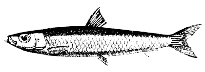

**Figure 2.3:** *Spratelloides delicatulus*, small round herring

Sardines and herrings are small migratory fishes which congregate in enormous shoals in shallow coastal waters. Flesh is oily but tasty (Munro 1967: p.50). They are taken in nets in Oceanic communities.

Anchovies also live in large schools in coastal waters and estuaries. They have a long slender maxillary (upper jaw) and protruding snout, and most are silvery or have a bright silvery lateral band. Some species migrate seasonally, and the schools come close inshore where they can be captured with seines (Munro 1967: p.43).

In the cognate sets which follow, terms show some crossover of meaning between sardines and anchovies. This is most likely due to looseness of definition of the English terms by the wordlist compilers, but it is possible that the two families are regarded as sufficiently similar in some languages for one term to cover both. The fact that we can reconstruct six POc terms indicates that speakers differentiated between the referents in some regard.

| **PMP** |  | *paya | ‘k.o. small fish, sardine or anchovy’ (ACD) |
| --- | --- | --- | --- |
| **POc** |  | *paya | ‘k.o. small fish, sardine or anchovy’ |
| Adm | Nyindrou | *ba* | ‘k.o. small fish’ |
| Adm | Ponam | *pa* | ‘anchovy’ |
| NNG | Gitua | *paya* | ‘anchovy, pilchard’ |
| NNG | Mutu | *pai* | ‘anchovy spp.’ |
| NNG | Manam | *waya-waya* | ‘sardine’ |
| PT | Bunama | *haya* | ‘k.o. anchovy’ (Mueller) |
| PT | Saliba | *haya* | ‘k.o. fish’ |
| PT | Dobu | *(ʔa)aya* | ‘k.o. anchovy’ |
| PT | Kilivila | *vaya* | ‘k.o. fish’ |
| MM | Patpatar | *haia* | ‘k.o. fish, small, black’ |
| MM | Nehan | *wai* | ‘fish fry, anchovy?’ |
| NCal | Nemi | *bac* | ‘sardine’ |
| NCal | Nêlêmwa | *ba* | ‘sardine’ |
| **PCP** |  | *vaya | ‘k.o. small school fish’ (Geraghty: ‘k.o. anchovy’) |
| Fij | Bauan | *vaya* | ‘small fish like the *daniva* (similar to a sardine), but with a red tail’ |
| Fij | Lau (Eastern Fijian) | *vaya* | ‘*Thrissina baelama*’ |
| Fij | Kadavu | *vaya* | ‘k.o. school fish’ |
| Pn | Samoan | *fā* | ‘Megalops (tarpon), found in marshes and river mouths’ |

| **POc** |  | *jaja | ‘small fish, herring or anchovy’ |
| --- | --- | --- | --- |
| NNG | Bing | *(yiy)zaz* | ‘k.o. fish, Clupeidae’ (*yiy* ‘fish’) |
| **PCP** |  | *ðaðā | ‘*Spratelloides* sp.’ (Geraghty 1994) |
| Fij | Verata | *ðaða* | ‘*Spratelloides*’ |
| **PPn** |  | *sasā | ‘anchovy’ (Hooper: ‘*Spratelloides* sp.’ [herring]) |
| Pn | Tongan | *hahā* | ‘k.o. small fish, anchovy’ |
| Pn | East Uvean | *hahā* | ‘k.o. fish’ |
| Pn | Tokelauan | *hahā* | ‘k.o. sprat’ |
| Pn | Tikopia | *sā* | ‘small reef fish of anchovy type’ |

In the next cognate set, there is reasonable consistency of meaning as far east as Fiji, but Polynesian reflexes undergo a striking change of meaning, referring to a kind of shark with similar markings to sardines (see p.33). Polynesian terms for sardine, together with a number of Fijian terms, have the same form minus the first syllable.

| **POc** |  | *tanipa | ‘Sardinella spp., sardine’ |
| --- | --- | --- | --- |
| Adm | Loniu | *tenih* | ‘sardine’ |
| Adm | Nyindrou | *drañip* | ‘sardine’ |
| Adm | Ponam | *hañef* | ‘anchovy’ |
| PT | Bunama | *taniha(na)* | ‘k.o. herring’ (Mueller 1985) |
| PT | Kilivila | *taninuva* | ‘sardine’ (for †*taniva*) |
| PT | Gumawana | *taninava* | ‘goldspot herring’ (for †*taniva*) |
| NCV | Raga | *tanive* | ‘*Hyperlophus vittatus*, sandy sprat’ |
| NCV | Tamambo | *tanive* | ‘sardine’ |
| NCV | Uripiv | *daniv* | ‘sardine’ |
| Mic | Puluwatese | *hanif* | ‘anchovy’ |
| Mic | Chuukese | *senif* | ‘*Herklotsichthys quadrimaculatus*, goldspot herring’ |
| Mic | Chuukese | *senifana* | ‘sardine’ |
| Mic | Ponapean | *saip* | ‘sardine’ |
| **PCP** |  | *taniva | ‘Sardinella’ (Geraghty 1994) |
| Fij | Nadrogā | *tanive* | ‘*Herklotsichthys*’ |
| Fij | Wayan | *tanive* | ‘generic for a number of species of small sardine-like fish’ |
| Fij | Kadavu | *daniva* | ‘schooling fish’ |
| **PPn** |  | *tanifa | ‘fierce shark’ |
| Pn | Tongan | *tanifa* | ‘k.o. large man-eating shark’ |
| Pn | Niuean | *tenifa* | ‘general name for shark’ |
| Pn | East Uvean | *tanifa* | ‘k.o. shark’ |
| Pn | Pukapukan | *taniwa* | ‘fierce shark’ |
| Pn | Samoan | *tanifa* | ‘large man-eating shark’ |
| Pn | Tahitian | *tanifa* | ‘k.o. fish’ |
| Pn | Māori | *tanifa* | ‘shark or any formidable marine creature’ (*maŋo tanifa* ‘white pointer shark’) |

| **PCP** |  | *niva | ‘*Sardinella* spp.’ (Geraghty 1994) |
| --- | --- | --- | --- |
| Fij | Verata | *niva* | ‘*Sardinella melanura*, *Sardinella fijiense*’ |
| Fij | Ovalau | *niva* | ‘*Sardinella melanura*, *S.fijiense*’ |
| Fij | Nadrogā | *nive-nive* | ‘*Sardinella fijiense*’ |
| **PPn** |  | *nifa | ‘*Sardinella* sp.’ (Hooper 1994) |
| Pn | East Uvean | *nifa* | ‘k.o. fish’ |
| Pn | Tahitian | *nifa* | ‘k.o. spotted fish’ |
| Pn | Tuamotuan | *nifa* | ‘juvenile *Albula*’ |
| Pn | Marquesan | *nifa* | ‘*Sardinella marquesensis*’ |

| **POc** |  | *kʷaru | ‘*Sardinella*, sardine’ |
| --- | --- | --- | --- |
| Adm | Titan | *kʷal* | ‘sardine’ |
| MM | Marovo | *karu(mehe)* | ‘anchovy, found in river mouths’ |
| Mic | Marshallese | *kʷaṛᵚ-kʷaṛᵚ* | ‘sardine’ |

| **POc** |  | *kepʷa | ‘Clupeidae, probably sardine sp.’ |
| --- | --- | --- | --- |
| Adm | Titan | *kepai* | ‘sardine-like fish’ (*-i* unexplained) |
| MM | Halia | *keho-keho* | ‘dark blue sardine’ |
| MM | Marovo | *kevo* | ‘*Stolephorus* sp., anchovy’ |
| MM | Maringe | *kʰefo* | ‘sardine’ |
| SES | Gela | *kepo* | ‘*Herklotsichthys quadrimaculatus*, fourspot herring’ |
| SES | Lau | *kefo* | ‘sardine’ |
| NCal | Nêlêmwa | *heva* | ‘sardine’ |

| **POc** |  | *s(a,i)waRa | ‘Clupeidae, sardine or herring’ |
| --- | --- | --- | --- |
| Adm | Loniu | *caway* | ‘k.o. sardine or anchovy’ |
| PT | Dobu | *siwala* | ‘gold-spot herring’ |
| PT | Molima | *siwala* | ‘sardine, fish which comes in *bolimana* (SW wind = May-June) time’ |
| PT | Kilivila | *lawiya* | ‘k.o. fish’ (vowel metathesis) |

| **PEOc** |  | *buma | ‘k.o. fish, possibly sardine’ |
| --- | --- | --- | --- |
| MM | Maringe | *buma* | ‘edible fish, frequently travels in schools’ (probably borrowed from Bugotu) |
| SES | Bugotu | *buma* | ‘sardine’ |
| SES | Gela | *buma* | ‘k.o. fish’ |
| SES | Lau | *buma* | ‘sardine’ |
| SES | Arosi | *buma* | ‘sardine, many taboos connected with it’ |
| SES | ’Are’are | *puma* | ‘k.o. fish’ |
| Pn | Luangiua | *puma* | ‘k.o. fish’ (probably loan from a Solomons language) |

cf. also: The items listed here other than from Ba are due to John Lynch (pers. comm.)

| NCV | Neve’ei | *na-buŋ* | ‘fish intermediate between sardine and mackerel’ |
| --- | --- | --- | --- |
| NCV | Nāti | *ni-ᵐpuŋ* | ‘mackerel’ |
| NCV | Southwest Bay | *ne-buŋ* | ‘mackerel’ |
| NCV | Nese | *na-buŋo* | ‘mackerel’ |
| NCV | South Efate | *na-pumʷ* | ‘Scombridae’ |
| SV | Anejom̃ | *(na-tic)pom* | ‘Scombridae’ |
| NCal | Nyelâyu | *bume* | ‘k.o. mackerel’ |
| Fij | Bā | *bima* | ‘k.o. middle-sized mullet’ |

## 8. Milkfishes (Chanidae)

This family consists of a single species, *Chanos chanos*. Fishes grow to around a metre in length, are finely scaled, silvery and toothless. They inhabit both open sea and brackish water and can ascend into rivers. They feed on crustaceans, worms and detritus. Although very bony, the flesh has soft texture and excellent flavour (Munro 1967: p.54).

There is a well-supported POc reconstruction continuing PMP *qawa or *qawan. New Caledonian reflexes provide support for final *-q. At least two SES cognates show confusion with terms for mullet (cf. POc *(k,q)aRua(s), §18).

| **PMP** |  | *qawa, *qawan | ‘*Chanos chanos*, milkfish’ (Blust 2002) |
| --- | --- | --- | --- |
| **POc** |  | *qawaq | ‘*Chanos chanos*, milkfish’ |
| NNG | Gedaged | *an* | ‘white marine fish about 50 cm long’ |
| NNG | Mutu | *an* | ‘*Chanos chanos*’ |
| SES | Gela | *oā* | ‘name given to bonefish and milkfish’ |
| SES | Lau | *hakʷa* | ‘*Chanos* sp.’ |
| SES | ’Are’are | *rawa* | ‘k.o. fish’ |
| SES | Sa’a | *sawa* | ‘freshwater mullet’ |
| SES | Arosi | *sawa* | ‘mullet’ |
| NCal | Nyelâyu | *kuak* | ‘adult milkfish’ |
| NCal | Nêlêmwa | *kua* | ‘adult milkfish’ |
| NCal | Nemi | *nu-hyaok* | ‘juvenile milkfish’ |
| Mic | Kiribati | *(bane)awa* | ‘*Chanos chanos*’ |
| Mic | Kiribati | *awa(tai)* | ‘adult milkfish’ |
| **PCP** |  | *qawa | ‘Chanos’ (Geraghty 1994) |
| Fij | Bauan | *yawa* | ‘milkfish, *Chanos chanos*’ |
| Fij | Wayan | *awa* | ‘k.o. fish, more than one metre long, bony, feeds in schools, good eating’ |
| **PPn** |  | *qawa | ‘*Chanos chanos*, milkfish or salmon herring’ (Hooper 1994) |
| Pn | Tongan | *ʔava* | ‘k.o. fish’ (*ʔava tahi* ‘sea *ʔava*’, *ʔava ʔuta* ‘land *ʔava*’) |
| Pn | Samoan | *ava* | ‘large fish, *Chanos* sp., caught by torchlight’ |
| Pn | Tokelauan | *ava* | ‘milkfish’ |
| Pn | Tuvalu | *ava* | ‘milkfish’ |
| Pn | Tahitian | *ava* | ‘milkfish’ |
| Pn | Hawaiian | *awa* | ‘*Chanos chanos*, milkfish’ |

cf. also:

| SES | Arosi | *ʔawa* | ‘k.o. fish’ |
| --- | --- | --- | --- |
| Mic | Kiribati | *tāwa* | ‘fry of milkfish’ |

## 9. Lizardfishes (Synodontidae)

Lizardfish are small, slender and cylindrical, with a rather wide mouth. Most are bottomliving inhabitants of muddy or sandy areas of shallow coastal waters. They are barred and mottled to blend in with bottom surroundings, and their general appearance suggests that of a lizard. The flesh is not very bony but insipid (Munro 1967: p.70).

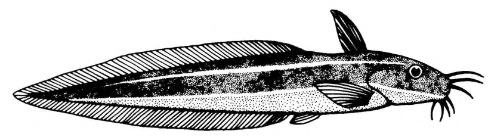

**Figure 2.4:** *Plotosus lineatus*, striped eel catfish

## 10. Catfish (Plotosidae)

Reflexes undergo a change of meaning in some Polynesian languages. Hooper (1994: p.221) suggests that an elongate shape may provide the semantic link with snake mackerels, and, although the two are found in very different environments, both are black and slimy (Geraghty pers. comm.).

| **POc** |  | *kaboRa | ‘*Plotosus* spp., catfish’ |
| --- | --- | --- | --- |
| Adm | Loniu | *kopow* | ‘catfish or catfish eel’ |
| NNG | Gedaged | *gabol̥* | ‘k.o. fish, to 7cm, usually in swarms’ (*g-* for †*k-* or zero)[^8] |
| PT | Misima | *kaboiya* | ‘*Plotosus lineatus*, striped catfish’ |
| MM | Patpatar | *uboro* | ‘catfish’ |
| SES | Gela | *(i)ɣabola* | ‘catfish spp.’ (*ya-* reanalysed as *iɣa* ‘fish’) |
| **PEOc** |  | *kaboRa | ‘Plotosus, catfish’ (Geraghty 1994) |
| NCV | Mota | *ɣapʷora* | ‘a fish, *Silurus* [*Plotosus*]’ |
| NCV | Lewo | *kapwo* | ‘catfish’ |
| NCV | Nguna | *(na-i)kapwoa* | ‘catfish’ (*ka-* reanalysed as *ika* ‘fish’) |
| SV | Anejom̃ | *n-ɣope* | ‘*Plotosus anguillaris*’ (*Plotosus lineatus*) |
| NCal | Pije | *sago* | ‘*Plotosus anguillaris*’ |
| NCal | Nyelâyu | *cago* | ‘*Plotosus anguillaris*’ |
| NCal | Iaai | *(wa)aba* | ‘*Plotosus anguillaris*’ |
| Fij | Bauan | *kaboa* | ‘small black shoal fish, catfish’ |
| Fij | Wayan | *kabō* | ‘*Plotosus* spp. Sharp spikes can inflict wound’ |
| **PPn** |  | *kapoa | ‘fish sp., probably *Plotosus* sp., catfish’ (Hooper 1994) |
| Pn | Tongan | *kopoa* | ‘catfish’ |
| Pn | East Uvean | *kapoa* | ‘*Plotosus lineatus*, catfish’ |
| Pn | Samoan | *ʔapoa* | ‘*Plotosus anguillaris*’ |
| Pn | Pukapukan | *kapoa* | ‘*Promethichthys prometheus*, snake mackerel’ |
| Pn | Tokelauan | *kapoa* | ‘*Promethichthys prometheus*, snake mackerel’ |

Geraghty (pers. comm.) notes that juvenile catfish do move in very dense populous swarms.

## 11. Eels

Eels are classified in a number of families within the Order *Anguilliformes*. The best known within the region are the freshwater eels (Anguillidae), and several sea eel families including morays (Muraenidae), pike eels (Muraenesocidae), congers (Congridae) and snake eels (Ophichthidae).

### 11.1. Freshwater eels (Anguillidae)

Although they spend most of their lives in fresh water, freshwater eels migrate to sea to spawn. In inland areas they constitute an important food item. POc *tuna is well supported as the generic term for all freshwater eels.

| **PAn** |  | *tuNa | ‘freshwater eel’ (Blust 2002) |
| --- | --- | --- | --- |
| **POc** |  | *tuna | ‘Anguillidae, freshwater eel (generic)’ |
| Adm | Mussau | *tuna* | ‘eel’ |
| Adm | Lenkau | *trun* | ‘large freshwater eel’ |
| Adm | Penchal | *run* | ‘large freshwater eel’ |
| NNG | Bilibil | *tuna* | ‘eel’ |
| NNG | Wogeo | *tuna* | ‘eel’ |
| NNG | Kairiru | *tun* | ‘freshwater eel’ |
| NNG | Bariai | *tuna* | ‘large eel’ |
| NNG | Lukep | *tunu* | ‘eel (generic)’ |
| NNG | Mutu | *tūn* | ‘*Anguilla reinhardti*, freshwater eel’ |
| PT | Tawala | *tuna* | ‘freshwater eel’ |
| PT | Lala | *kuna* | ‘eel’ |
| MM | Tolai | *(maleo) tuna* | ‘k.o. eel’ (maleo ‘generic for sea eels’) |
| MM | Tabar | *tuna* | ‘eel’ |
| MM | Nduke | *tuna(sa)* | ‘eel’ |
| Mic | Kosraean | *ton* | ‘freshwater eel’ |
| **PCP** |  | *tuna | ‘Anguillidae, freshwater eel’ (Geraghty 1994) |
| Fij | Rotuman | *funa* | (1) ‘freshwater eel’; (2) ‘similar saltwater eel’ |
| Fij | Wayan | *tuna* | (1) ‘freshwater eel’; (2) ‘generic for eels including morays and congers’ |
| Fij | Bauan | *duna* | ‘freshwater eel’ |
| Fij | Kadavu | *tuna* | ‘generic term for freshwater eels’ |
| **PPn** |  | *tuna | ‘*Anguilla* spp., freshwater eel’ (Hooper 1994) |
| Pn | Tongan | *tuna* | ‘k.o. eel’ (including *tuna tahi*, *tuna vai*) |
| Pn | Niuean | *tuna* | ‘freshwater eel’ |
| Pn | East Uvean | *tuna* | ‘freshwater eel’ |
| Pn | Rennellese | *tuna* | ‘k.o. lake eel’ |
| Pn | Pukapukan | *tuna* | ‘generic for several eels, both sea and fresh water’ |
| Pn | Samoan | *tuna* | ‘Anguilla, freshwater eel’ |
| Pn | Tikopia | *tuna* | ‘eel: generic term applied especially to lake eels’ |
| Pn | Māori | *tuna* | ‘generic for all freshwater eels’ |
| Pn | Hawaiian | *kuna* | ‘k.o. freshwater eel’ |

### 11.2. Morays (Muraenidae)

Morays are large, thick-skinned eels with sharp knife-like teeth but no pectoral fins. They can be pugnacious when confronted, although shy by nature. Many are nocturnal. They are often found in the crevices of coral banks. There are numerous species in New Guinea waters, many quite distinctive in colouring and markings.

POc *[la]bʷa(s,j)i ‘moray eel’ is reconstructable both with and without initial *la-.

| **POc** |  | *[la]bʷa(s,j)i | ‘moray eel’ |
| --- | --- | --- | --- |
| Adm | Titan | *pes* | ‘moray eel’ |
| Adm | Lenkau | *pes* | ‘moray eel’ |
| Adm | Nali | *pʷesi* | ‘moray eel’ |
| NNG | Psohoh | *basi* | ‘eel’ |
| PT | Sudest | *labʷadi* | ‘freshwater eel’ |
| Mic | Mokilese | *lapʷet* | ‘k.o. eel’ |
| Mic | Ponapean | *lapʷet* | ‘saltwater eel (generic)’ |
| Mic | Chuukese | *lopʷut* | ‘general name for moray eels’ |
| Mic | Woleaian | *rabʷuto* | ‘generic for snake, worm, eel’ (*-o* unexpected) |
| Fij | Lau (Eastern Fijian) | *pusi* | ‘*Echidna nebulosa*, starry or clouded moray’ |

| **PPn** |  | *pusi | ‘sea eel generic, *Gymnothorax* spp.’ (Hooper 1994) |
| --- | --- | --- | --- |
| Pn | Rennellese | *pusi* | ‘starry or clouded moray eel’ |
| Pn | Samoan | *pusi* | ‘generic for moray eels’ |
| Pn | Tokelauan | *puhi* | ‘generic for moray eels’ |
| Pn | Tikopia | *pusi* | ‘*Gymnothorax* sp., grey-brown reef eel’ |
| Pn | Māori | *puhi* | ‘very large variety of eel’ |
| Pn | Hawaiian | *puhi* | ‘eel (generic)’ |

The reconstruction below is weakly supported and it is uncertain what kind of eel it referred to. It is listed in this section as its Titan reflex refers to a kind of moray.

| **POc** |  | *bʷalup | ‘k.o. eel, moray eel ?’ |
| --- | --- | --- | --- |
| Adm | Titan | *pʷalu* | ‘*Echidna nebulosa*, starry or clouded moray’ |
| NNG | Mangga | *vayob* | ‘eel’ |
| NNG | Kumaru | *vyob* | ‘eel’ |
| NNG | Adzera | *bʷaruf* | ‘freshwater eel’ |

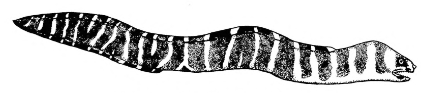

**Figure 2.5:** *Gynmothorax* sp., barred moray eel

The Micronesian evidence below points to a reconstruction with a single final vowel, while the PCP evidence reflects two.

| **PROc** |  | *dābea | ‘*Gymnothorax*, moray eel’ |
| --- | --- | --- | --- |
| Mic | Marshallese | *rāp* | ‘*Gymnothorax*, moray, large and black’ |
| Mic | Chuukese | *rāp* | ‘moray eel’ |
| Mic | Ponapean | *rap* | ‘saltwater eel, commonly found on barrier reef’ |
| **PCP** |  | *dābea | ‘k.o. sea eel or sea snake’ (Geraghty 1994) |
| Fij | Bauan | *dābea* | ‘conger eel, large and dangerous sea eel’ |
| Fij | Kadavu | *dabea* | ‘moray eel’ |
| **PPn** |  | *tāpea | ‘generic for morays’ |
| Pn | East Futunan | *tapea* | ‘*Gymnothorax* spp.’ |
| Pn | Bellona | *tāpea* | ‘generic for morays, reef eels’ |

Lower-level reconstructions include PCP *boila ‘moray eel’ and *dravua ‘*Gymnothorax* sp.’ (Geraghty 1994: p.145).

### 11.3. Pike eels (Muraenesocidae) and congers (Congridae)

Pike eels are large, with prominent canine teeth and a long slender snout. Conger eels are also large, with well-developed vertical and pectoral fins. The two are sometimes classified together. The flesh of both is excellent. Both occur in shallow water, although congers also have deep-water forms.

| **PROc** |  | *bonu | ‘k.o. eel, probably conger’ |
| --- | --- | --- | --- |
| Mic | Kiribati | *(ra)pʷono* | ‘moray eel’ (*ra-* ‘defective’?) |
| **PCP** |  | *bon(u,o) | ‘conger eel’ (Geraghty: *bonu ‘Ophichthidae, snake eel’) |
| Fij | Bauan | *bonu* | ‘*Scolecenchelys macropterus*, slender snake eel’ |
| Fij | Rewa | *bonu(ika)* | ‘*Conger* sp.’ |
| Fij | Wayan | *bonu* | ‘an eel of the mangrove swamp, probably conger’ |
| Pn | Tongan | *ponu(taliŋa)* | ‘k.o. eel, inedible’ |
| Pn | Tongan | *ponu-ponu* | ‘k.o. sea worm’ |
| Pn | Kapingamarangi | *pono* | ‘conger sp., white eel’ |

cf. also:

| PT | Ubir | *bonu-bonu* | ‘fish (freshwater)’ |
| --- | --- | --- | --- |

| **PROc** |  | *baku | ‘conger eel’ |
| --- | --- | --- | --- |
| SV | Sye | *poki* | ‘k.o. eel, possibly conger’ |
| SV | Lenakel | *pəku* | ‘k.o. eel’ |
| Fij | Rotuman | *paʔu* | ‘sea eel’ |
| Fij | Wayan | *bākū* | ‘*Conger cinerus*’ |
| Fij | Nadrogā | *baku* | ‘*Conger cinerus*’ |

### 11.4. Snake eels (Ophichthidae)

Snake eels tend to lie on sandy or muddy bottoms in the vicinity of reefs, often spending daylight hours completely buried, although they can swim to the surface at night when attracted by lights. They are difficult to trap, seldom taking a hook, while their slender bodies pass through the mesh of nets and traps (Munro 1967: p.91). No reconstructions have been made.

### 11.5. Other terms for eels

In a number of reconstructions it has proved difficult to link terms to particular kinds of eel. The following may be a generic term for sea eels.

| **POc** |  | *malayo | ‘sea eel, possibly generic’ |
| --- | --- | --- | --- |
| NNG | Kove | *maleu* | ‘freshwater eel’ |
| NNG | Mutu | *(az)mala* | ‘*Gymnothorax cribroris*. brown-flecked reef eel’ |
| MM | Lamasong | *male* | ‘eel’ |
| MM | Madak | *mele* | ‘eel’ |
| MM | Tolai | *maleo* | ‘generic name for sea eel’ |
| MM | Minigir | *malo* | ‘eel’ |
| MM | Ramoaaina | *maleu* | ‘eel’ |
| MM | Selau | *melio* | ‘eel’ |
| MM | Taiof | *mereou* | ‘eel’ |
| MM | Nehan | *malio* | ‘moray eel’ |
| NCV | Mota | *maleo* | ‘sea eel’ |

Mota has two similar terms, *maleo* and *marea*, and it is possible that the former is a borrowing from a Western Oceanic language. The next set is in complementary distribution to the one above, and it may be that we are dealing with a single cognate set, although we would expect PROc †*malaya if directly inherited. It is possible that PROc *maraya was borrowed from an unrecorded language’s reflex of POc *malayo. Arosi (SES) *marea* ‘k.o. eel’ also appears to reflect *maraya, but it is reasonably likely that this is a Mota borrowing introduced by missionaries, as Mota was a missionary lingua franca which was also used in parts of the Solomon Islands in the nineteenth century.

| **PROc** |  | *maraya | ‘sea eel’ (Clark 2009: 141) [^7] |
| --- | --- | --- | --- |
| NCV | Mota | *marea* | ‘sea eel’ |
| NCV | Tamambo | *marai* | ‘k.o. eel, not for eating’ |
| NCV | Ambae | *marae* | ‘eel’ |
| NCV | Raga | *marae* | ‘eel (generic)’ |
| NCV | South Efate | *mra (ni nai)* | ‘eel (generic)’ |
| Mic | Carolinian | *(li)mʷare-mʷar* | ‘white or yellow eel with black banded stripes’ (*li-* ‘attributive prefix’) |
| Mic | Puluwatese | *(li)mʷara-mʷar* | ‘k.o. eel’ (*li-* prefix to names of birds, eels, fish, lizards etc.) |

cf. also:

| SES | Arosi | *marea* | ‘k.o. eel’ (borrowed from Mota *marea*?) |
| --- | --- | --- | --- |

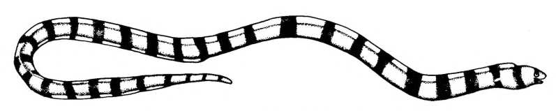

**Figure 2.6:** *Myrichthys colubrinus*, harlequin snake eel

| **PMP** |  | *kasuli | ‘Anguillidae, freshwater eel’ (ACD: PWMP *kasuli) |
| --- | --- | --- | --- |
| **POc** |  | *(k,q)asuli | ‘k.o. sea eel’ |
| **PCP** |  | *qasuli | ‘k.o. sea eel’ (Geraghty 1994) |
| Fij | Bauan | *suli* | ‘conger’ |
| Pn | Samoan | *asulu* | ‘*Strophidon*, moray eel’ (Rensch 1999: 20) |

cf. also:

| SES | Bugotu | *kasa* | ‘sea eel’ |
| --- | --- | --- | --- |
| Mic | Kiribati | *kuru-kuru* | ‘moray eel’ |

| **POc** |  | *(t,d)oloq | ‘k.o. eel’ |
| --- | --- | --- | --- |
| MM | Meramera | *tulu* | ‘k.o. eel’ |
| MM | Torau | *tolo(u)* | ‘k.o. eel’ |
| MM | Mono-Alu | *toloʔo* | ‘k.o. eel’ |
| MM | Vaghua | *toloko* | ‘k.o. eel’ |
| MM | Varisi | *toloko* | ‘k.o. eel’ |
| MM | Hoava | *toloko* | ‘k.o. eel’ |
| SES | Baegu | *dolo* | ‘k.o. eel’ |
| SES | Kwara’ae | *dōl* | ‘k.o. eel’ |
| SES | Kwai | *dolo* | ‘k.o. eel’ |
| SES | Langalanga | *dolo* | ‘k.o. eel’ |
| SES | Lau | *dolo* | ‘k.o. eel’ |

cf. also:

| Pn | Tikopia | *toro* | ‘lizardfish’ |
| --- | --- | --- | --- |
| Pn | Samoan | *tolo* | ‘small mud skipper’ |

The Polynesian terms may be linked through association with PPn *tolo ‘to crawl’. Some eels (particularly snake eels), lizardfish (§9) and mud skippers (§49) may all be described as mud dwellers.

The SES terms below show coalescence of *wa as *-o* as has been noted also in some shark terms.

| **PEOc** |  | *pulewa | ‘k.o. eel’ |
| --- | --- | --- | --- |
| SES | Gela | *puleo* | ‘k.o. eel’ |
| SES | Birao | *puleo* | ‘eel’ |
| SES | Lengo | *puleo* | ‘freshwater eel’ |
| SES | Longgu | *puleo* | ‘eel’ |
| **PCP** |  | *bulewa | ‘k.o. eel’ |
| Pn | Tuvalu | *puleva* | ‘k.o. eel’ |

cf. also:

| PT | Bunama | *pʷa-pʷalewa* | ‘k.o. lizardfish’ |
| --- | --- | --- | --- |
| Fij | Bauan | *bulewa* | ‘zoophyte that adheres to reefs’ |

PPn *toke ‘sea eel’ has also been reconstructed (Hooper 1994: p.198).

## 12. Flying fishes (Exocoetidae)

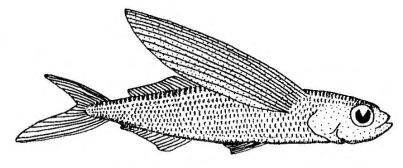

**Figure 2.7:** *Exocoetus volitans*, blue flying fish

These fish are pelagic, swimming near the surface and gliding above the water for considerable distances. They inhabit open coastal and oceanic waters, are attracted to light at night and often leap aboard vessels. Their flesh is of good quality (Munro 1967: p. 115). In Sa’a (Malaita), flying fish, like the bonito, require a certain supernatural power to be caught. Certain formalities must be followed and particular sacrifices made before a canoe can set out to catch flying fish (Codrington 1891:138).

Munro identifies more than a dozen species, but terms located have little elaboration of identity.

| **POc** |  | *mʷagaRut | ‘Exocoetidae, flying fish’ |
| --- | --- | --- | --- |
| Adm | Titan | *mokou* | ‘generic for flying fish, Exocoetidae’ |
| Adm | Lenkau | *mokow* | ‘flying fish’ |
| Adm | Lou | *mokou* | ‘flying fish’ |
| MM | Halia | *magalut* | ‘flying fish’ |
| SES | Arosi | *magaru* | ‘flying fish’ |
| NCV | Mwotlap | *na-mʷkey* | ‘*Exocoetidae* spp., flying fish’ |
| NCV | Ambae | *mʷakaru* | ‘flying fish’ |
| NCV | Raga | *maɣaru* | ‘generic for various flying fish’ |
| **PMic** |  | *maŋar | ‘flying fish’ (*-ŋ- for †*-g-) |
| Mic | Carolinian | *maŋar* | ‘flying fish’ |
| Mic | Woleaian | *meŋaz* | ‘flying fish’ |
| Mic | Mokilese | *mɔŋɔr* | ‘flying fish’ |

Lower-level reconstructions include PPn *mālolo ‘flying fish spp.’ and PPn *sasawe ‘*Exocoetidae* spp., flying fish’ (Hooper 1994 p.201). PPn *sipa ‘small or immature flying fish’ is considered to be a reflex of POc *sipa ‘Hemiramphidae’, proposed in §13.

## 13. Half beaks and garfishes (Hemiramphidae), needlefishes and long toms (Belonidae)

Adult halfbeaks and garfishes have an elongated shaft-like lower jaw and very short upper jaw, although in juveniles the mouth is symmetrical. Like needlefish they live near the surface and are semipelagic. They inhabit shallow water and estuaries. The flesh is delicate but full of fine bones. They are important food fishes (Munro 1967: p. 109). *Hemiramphus* is the most common genus.

Needlefish and long toms are very slender, elongated with forceps-like jaws, well-toothed with minute scales. They are both marine and estuarine, and a few live permanently in fresh water. They often congregate in schools. Generally voracious, they are potentially dangerous because of their great speed and habit of making sudden leaps, especially when attracted to lights at night. The flesh is excellent (Munro 1967: p. 105). Genera include *Belone*, *Platybelone*, *Strongylura* and *Tylosurus*.

The two families are here treated together because in a number of languages (Halia, Kiribati, Mokilese, Rennellese, Samoan, Tikopia) there is one term covering both, presumably reflecting similarities in shape and habitat.

| **POc** |  | *Rije | ‘*Hemiramphus*, halfbeak’ (Geraghty 1990) |
| --- | --- | --- | --- |
| MM | Nakanai | *lise* | ‘small fish which flies, has a sharp bill’ |
| Fij | Rotuman | *jija* | ‘*Hemiramphus*, garfish’ (*j-* for †*∅*) |
| Fij | Bauan | *sise* | ‘*Hemiramphus*, garfish’ (*s-* for †*∅*) |
| Fij | Lau (Eastern Fijian) | *sise* | ‘*Hemiramphus*, garfish’ (*s-* for †*∅*) |
| **PPn** |  | *ise | ‘halfbeak spp.’ (Hooper 1994) |
| Pn | Tongan | *ihe* | ‘*Hemiramphus*’ |
| Pn | Niuatoputapu | *ihe-ihe* | ‘growth stage of halfbeak’ |
| Pn | Samoan | *ise* | ‘*Hemiramphus* and *Belone* taxa’ |
| Pn | Tokelauan | *ihe* | ‘halfbeak spp.’ |
| Pn | Tikopia | *ise* | ‘garfish Belonidae or (??) small crocodile needlefish’ |
| Pn | Māori | *ihe* | ‘*Hemiramphus intermedius*’ (?) |
| Pn | Hawaiian | *ihe-ihe* | ‘any of several halfbeaks’ (*ihe* ‘spear, javelin, dart’) |

The change in gloss in PPn below can be explained because of close resemblance between garfishes and some flying fish, with the latter, such as the beaked flying fish, *Oxyporhamphus micropterus micropterus*, classified as Exocoetidae by Munro (p. 118) and more recently as Hemiramphidae (Kailola 1987-1991:153, FishBase). Half beaks, garfish and flying fish all belong to the same suborder.

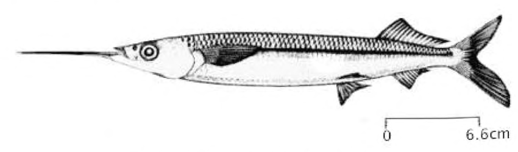

**Figure 2.8:** *Hemiramphus lutkei*, Lutke’s halfbeak

| **POc** |  | *sipa | ‘*Hemiramphus* spp.’ |
| --- | --- | --- | --- |
| PT | Kilivila | *seva(leya)* | ‘garfish’ |
| MM | Tolai | *ive* | ‘k.o. fish’ |
| **PPn** |  | *sipa | ‘young flying fish’ (Hooper 1994) |
| Pn | Niuean | *hipa* | ‘young small flying fish’ |
| Pn | Samoan | *sipa* | ‘young flying fish’ |
| Pn | Tokelauan | *hipa* | ‘young flying fish’ |
| Pn | Tikopia | *sipa* | ‘young flying fish’ |

| **POc** |  | *mʷakoR | ‘*Hemiramphus*, garfish’ |
| --- | --- | --- | --- |
| Adm | Titan | *makoi* | ‘*Hemiramphus* sp., garfish’ |
| NNG | Kela | *(i-)makʷaʔ* | ‘k.o. long tom’ (shift of labialisation) |
| PT | Hula | *muɣu* | ‘sea garfish’ |
| PT | Motu | *moa* | ‘*Hemirhamphus quoyi*, small white garfish’ (vowel metathesis) |
| PT | Lala | *moa* | ‘small garfish’ (vowel metathesis) |
| NCal | Nixumwak | *mʷāk* | ‘k.o. fish’ |
| NCal | Xârâcùù | *mʷē* | ‘k.o. fish’ |
| Mic | Kiribati | *mʷake* | ‘*Strongylura* sp., garfish’ |
| Mic | Marshallese | *mʷak* | ‘*Strongylura*, needlefish’ |
| Mic | Woleaian | *mʷaxi* | ‘young needlefish’ |
| **PCP** |  | *ŋʷa(k,x)a | ‘*Hemiramphus*’ (Geraghty 1994) |
| Fij | Kadavu | *ŋaxa* | ‘*Hemiramphus*’ |
| Pn | East Uvean | *ŋaʔa* | ‘*Rastrelliger* (Scombridae)’ |

cf. also:

| Mic | Mokilese | *mʷalak* | ‘k.o. needlefish (flat-sided garfish?)’ |
| --- | --- | --- | --- |

The following reconstruction is echoed in the transparent compound, PMP/POc *saku-layaR ‘sailfish, swordfish’, which contains as its second element *layaR ‘sail’ (§58 and vol.1,194-195).

| **PMP** |  | *saku | ‘needlefish’ (Blust 2002) |
| --- | --- | --- | --- |
| **POc** |  | *saku | ‘needlefishes, garfishes, long toms (Belonidae)’ |
| NNG | Manam | *saʔu* | ‘garfish’ |
| NNG | Lukep | *sau* | ‘needlenose fish’ |
| PT | Dobu | *sa-sau(li)* | ‘long tom when small’ |
| MM | Vitu | *saku* | ‘needlefish’ |
| MM | Patpatar | *sok* | ‘long tom’ |
| MM | Nehan | *hau* | ‘long tom (generic)’ |
| NCV | Namakir | *soka(raru)* | ‘garfish’ |
| NCal | Iaai | *(wa)saə* | ‘*Hemiramphus far*’ |
| Mic | Kiribati | *raku* | ‘swordfish’ |
| Mic | Kiribati | *rau(bara)* | ‘garfish’ (bara ‘small fry’) |
| Mic | Marshallese | *tak* | ‘*Belone platyura*’ |
| Mic | Ponapean | *tāk* | ‘needlefish’ |
| Mic | Mokilese | *tɔk* | ‘needlefish, barred long tom?’ |
| Mic | Puluwatese | *tāk* | ‘needlefish’ |
| Mic | Woleaian | *taxu* | ‘needlefish (generic)’ |
| Fij | Kadavu | *saxu* | ‘generic term for needlefishes’ |
| Fij | Bauan | *saku* | ‘swordfish’ |
| Fij | Wayan | *saku* | ‘generic for needlefish and longtoms’ |
| **PPn** |  | *haku | ‘garfish and needlefish’ (Hooper 1994) |
| Pn | Niuean | *aku* | ‘long tom, pipe fish, edible’ |
| Pn | Tongan | *haku* | ‘k.o. fish: a young *hakulā* ’swordfish’’ |
| Pn | Rennellese | *aku* | ‘general term for needlefish and garfish’ |
| Pn | Pukapukan | *aku* | ‘general name for needlefishes’ |
| Pn | Pukapukan | *aku-aku* | ‘*Platybelone* sp.’ |
| Pn | Samoan | *aʔu* | ‘*Strongylura*, fish said to attack humans’ |
| Pn | Tokelauan | *aku* | ‘needlefish, about 60 cm long’ |
| Pn | Tikopia | *aku* | ‘general term for needlefish and garfish’ |
| Pn | Tahitian | *aʔu-aʔu* | ‘*Platybelone* sp.’ |
| Pn | Marquesan | *aku* | ‘general term for needlefish and garfish’ |

| **POc** |  | *panapa | ‘garfish and needlefish taxon’ (ACD: ‘needlefish sp.’) |
| --- | --- | --- | --- |
| Adm | Loniu | *panah* | ‘*Hemiramphus commersoni*, barred garfish’ |
| Adm | Lou | *panap* | ‘small blue fish with long needle-like mouth’ |
| Adm | Likum | *panah* | ‘small blue and green marine fish with projecting lower jaw’ |
| Adm | Nyindrou | *banap* | ‘small dotted fish with needle nose’ |
| MM | Nehan | *pon(pou)* | ‘large barred garfish’ (smaller is *kohkoh*) |
| MM | Halia | *pon-pon* | ‘halfbeak’ |
| MM | Teop | *pon-pon* | ‘long-billed garfish, Quoy’s short-billed garfish, barred garfish’ |
| Mic | Kiribati | *anā* | ‘a fish, small slender species, needlefish, garfish, halfbeak’ (loss of initial *p-* unexpected) |
| Mic | Chuukese | *fanā* | ‘small needlefish’ |
| Mic | Mokilese | *pana* | ‘k.o. needlefish’ |
| Mic | Woleaian | *ferā* | ‘k.o. needlefish’ |

cf. also:

| Adm | Titan | *cinap* | ‘barred garfish’ |
| --- | --- | --- | --- |

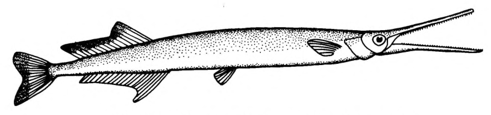

**Figure 2.9:** Tylosurus crocodilus crocodilus, giant long tom

Reduplicated reflexes of POc *sao in PPn below, refer instead to *Sphyraena*, the barracuda, and possibly its juvenile form. There is evidently some crossover of meaning between PPn *sao-sao ‘*Sphyraena* sp.’ and PPn *tao-tao ‘*Fistularia* spp., probably including trumpetfish’ (see §15). This may be because both barracuda and trumpetfish are, like the needlefish and garfish, long narrow fish, spear-like in shape.

| **POc** |  | *sao | ‘k.o. long tom’ |
| --- | --- | --- | --- |
| Adm | Titan | *co* | ‘generic for needlefish, long toms’ |
| Adm | Nali | *so* | ‘needlefish, ae’ |
| Adm | Loniu | *co* | ‘k.o. long tom’ |
| NNG | Gedaged | *sao* | ‘*Strongylura incisa*, long tom’ |
| NNG | Lukep | *sau* | ‘needlenose fish’ |
| NNG | Takia | *sao* | ‘k.o. long tom’ (Mueller) |
| NNG | Tami | *(i)-sa* | ‘k.o. long tom’ (Mueller) |
| MM | Halia | *soa-soa* | ‘garfish, needlefish’ (vowel metathesis) |
| MM | Marovo | *cho-cho* | ‘*Hemiramphus* spp., small garfish (generic)’ |
| **PPn** |  | *sao-sao | ‘juvenile *Sphyraena* sp.’ (Hooper: ‘*Sphyraena* sp.’) |
| Pn | Niuean | *hao-hao* | ‘trumpetfish’ |
| Pn | East Uvean | *sao-sao* | ‘juvenile *Sphyraena* sp.’ (*s* for †*h-*) |
| Pn | Samoan | *sao-sao* | ‘k.o. fish, said to be predatory and dangerous’ |
| Pn | Tokelauan | *hao-hao* | ‘*Sphyraena forsteri*’ |
| Pn | Tikopia | *sao-sao* | ‘juvenile *Sphyraena* sp.’ |

## 14. Squirrelfishes, soldierfishes (Holocentridae)

This family is well-represented through the region by most of the approximately 70 species known worldwide. Most are brilliant red, armoured with large rough scales with jagged edges. The head is extremely rough and spiny. They have large eyes, and are often longitudinally banded. Many species are nocturnal, living in holes in the reef during the day (Munro 1967: p. 138). Although most of the species are small, the flesh is considered good eating. In Niuatoputapu they are caught on moonlit nights either from a boat anchored near the reef or while standing on the reef edge (Dye 1983:250). Genera include *Sargocentron* [Holocentrus], *Myripristis* and *Flammeo*. *Adioryx* is now classified as a junior synonym of *Sargocentron*.

A number of taxa are typically distinguished in Oceanic languages. Three POc terms are reconstructable. Nuclear Micronesian reflexes in the following reconstruction confirm that this form was trisyllabic, as an original disyllable would be reflected without final vowel (ACD).

| **PMP** |  | *taRaqan | ‘*Holocentrus* spp., squirrelfish’ (ACD) |
| --- | --- | --- | --- |
| **POc** |  | *taRaqan | ‘*Sargocentron* spp., squirrelfish, including *Sargocentron spiniferum*’ (Geraghty 1990: PEOc *taRaʔa) |
| Adm | Loniu | *taʔay* | ‘squirrelfish or silver biddy’ (metathesis: for †*taya*(ʔ)) |
| NNG | Yabem | *talaŋ* | ‘a red sea fish’ |
| PT | Gumawana | *tayawana* | ‘squirrel fish’ |
| PT | Misima | *talayan* | ‘*Sargocentron* spp., spiny and blue-striped squirrelfish’ |
| PT | Motu | *tara* | ‘*Sargocentron violaceum*, violet squirrelfish’ |
| MM | Nakanai | *talaha* | ‘k.o. fish’ |
| MM | Lihir | *taran* | ‘*Sargocentron spiniferum*, spinecheek squirrelfish’ |
| MM | Roviana | *ta-tara* | ‘small reddish fish, easily hooked’ |
| SES | Gela | *talā* | ‘*Sargocentron spiniferum*, spinecheek squirrelfish’ |
| NCV | South Efate | *tra(kap)* | ‘squirrelfish’ |
| NCal | Pije | *jalā* | ‘*Holocentrus spinifer*’ |
| NCal | Jawe | *jarak* | ‘*Holocentrus spinifer*’ |
| **PMic** |  | *tarā | ‘squirrelfish’ (Bender et al. 2003) |
| Mic | Kiribati | *tā* | ‘*Sargocentron* spp.’ |
| Mic | Marshallese | *ceṛa* | ‘*Sargocentron*, *Myripristis* spp., squirrelfish’ |
| Mic | Ponapean | *sara* | ‘*Sargocentron spiniferum*, spinecheek squirrelfish’ |
| Mic | Chuukese | *sarā* | ‘*Sargocentron* sp., yellow-lined squirrel fish’ |
| Mic | Woleaian | *seẓā* | ‘*Adioryx spinifer*, spiny squirrel fish’ |
| Mic | Puluwatese | *haṛa* | ‘k.o. red fish’ |
| **PPn** |  | *taqa | ‘*Sargocentron spiniferum*, armoured soldierfish’ (Hooper 1994) |
| Pn | Tongan | *taʔa* | ‘*Sargocentron spiniferum*, red, edible’ |
| Pn | Niuean | *tā* | ‘*Myripristis violacea*, lattice soldierfish’ |
| Pn | Pukapukan | *tā* | ‘*Sargocentron spiniferum*’ |
| Pn | Samoan | *tā(malau)* | ‘name given to certain fishes of genus *Sargocentron* when about 30cm in length’ (See also under *malau below, p.55.) |
| Pn | Kapingamarangi | *tā* | ‘*Sargocentron ruber*, red squirrelfish’ |
| Pn | Tokelauan | *tā* | ‘*Sargocentron spiniferum*’ |
| Pn | Tuvalu | *tā(malau)* | ‘*Adioryx* spp.’ |
| Pn | Tikopia | *ta* | ‘sea fish, app. related to large squirrelfish’ |

cf. also:

| Pn | Rennellese | *tagae* | ‘general name for some squirrelfish’ (borrowed from a non-Polynesian language) |
| --- | --- | --- | --- |

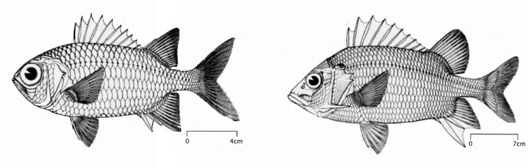

**Figure 2.10:** **Left** *Myripristis murdjan*, crimson squirrelfish. **Right** *Sargocentron spiniferum*, armoured soldierfish.

| **POc** |  | *kuru[ru] | ‘*Myripristis* spp., squirrelfish’ |
| --- | --- | --- | --- |
| Adm | Penchal | *kululu* | ‘squirrelfish, Holocentridae’ |
| Adm | Lou | *kurur* | ‘squirrelfish, Holocentridae’ |
| NNG | Gedaged | *ul̥u* | ‘*Myripristis murdjan*, crimson squirrelfish’ (Mueller) |
| NNG | Manam | *ididi* | ‘squirrelfish’ |
| NNG | Takia | *uru* | ‘k.o. squirrelfish’ |
| PT | Gumawana | *gilulu* | ‘squirrelfish’ (*g-* for †*k-* or †*∅-*) |
| PT | Iduna | *kululu (bawe)* | ‘k.o. fish’ (*bawe* ‘pig’) |
| PT | Kilivila | *kuyu* | ‘k.o. fish’ |
| PT | Motu | *kururu* | ‘squirrelfish’ (*kururu ioio*, *kururu matabada*) |
| MM | Vitu | *kururu* | ‘squirrelfish’ |
| MM | Patpatar | *kurur* | ‘red-orange squirrelfish’ |
| MM | Tolai | *kurur* | ‘k.o. fish’ |
| MM | Lihir | *kurur* | ‘Holocentridae, esp. Myripris’ |
| SES | Lau | *alulu* | ‘squirrelfish’ (*a-* for †*ʔu-*; *-l-* for †*-r-*: borrowed form?) |
| NCV | Loh | *wur-wur* | ‘*Myripristis berndti*’ |
| Mic | Kiribati | *kū* | ‘*Sargocentron* spp., soldierfish’ |
| Mic | Mokilese | *kīr* | ‘k.o. soldierfish’ |
| Mic | Marshallese | *kuṛ* | ‘*Sargocentron* binotatus’ |
| **PCP** |  | *kuru | ‘*Myripristis*’ (Geraghty 1994) |
| Fij | Rotuman | *ʔuru* | ‘red blunt-nosed fish’ |
| Fij | Bauan | *kuru* | ‘fish with a long snout’ |
| **PPn** |  | *kuru | ‘*Myripristis* sp.’ (Hooper 1994) |
| Pn | Niuean | *kū* | ‘small red fish’ |
| Pn | Pukapukan | *(malau) kulu* | ‘*Myripristis adusta*’ |
| Pn | Rapa | *kū* | ‘*Myripristis* sp.’ (loss of *-r- irregular) |
| Pn | Tahitian | *ʔū-ʔū* | ‘red-coloured fish’ (archaic; loss of *-r- irregular) |
| Pn | Hawaiian | *ʔū-ʔū* | ‘*Myripristis* sp.’ (loss of *-r- irregular) |

| **POc** |  | *jori | ‘squirrelfish, possibly generic’ |
| --- | --- | --- | --- |
| PT | Dobu | *doli* | ‘squirrelfish’ |
| MM | Nduke | *hori* | ‘general name for red squirrelfish’ |
| SES | Gela | *sori* | ‘*Myripristis* spp., soldierfish (generic)’ |
| SES | Arosi | *dori(awa)* | ‘k.o. fish’ |

cf. also:

| MM | Teop | *hori* | ‘squirrelfish (generic)’ |
| --- | --- | --- | --- |
| MM | Maringe | *sori* | ‘squirrelfish (generic)’ |
| MM | Marovo | *hori* | ‘*Sargocentron spiniferum*, spiny squirrelfish, bright red’ |

| **PROc** |  | *mʷalau | ‘squirrelfish, possibly generic for a number of spp.’ |
| --- | --- | --- | --- |
| Mic | Marshallese | *mʷən* | ‘*Myripristis* sp., squirrelfish’ |
| Mic | Woleaian | *mʷēri* | ‘red snapper, general term’ |
| Mic | Carolinian | *mʷēn* | ‘k.o. squirrelfish’ |
| Mic | Satawalese | *mʷən* | ‘*Myripristis* spp., squirrelfish’ |
| **PPn** |  | *malau | ‘general term for a number of fishes of the genera *Holocentrus*, *Adioryx*, *Myripristis* and *Flammeo*, soldier fishes and squirrel fishes’ (Hooper 1994) |
| Pn | Tongan | *malau* | ‘k.o. fish’ |
| Pn | East Uvean | *malau* | ‘*Adioryx* spp.’ |
| Pn | Rennellese | *magau* | ‘*Holocentrus* sp.’ |
| Pn | Tikopia | *marau* | ‘*Holocentrus spinifer*’ |
| Pn | Samoan | *malau* | ‘name given to red squirrelfish, *Holocentrus* and *Myripristis*’ |
| Pn | West Futunan | *marau* | ‘*Adioryx caudimaculatus* and others’ |
| Pn | Marquesan | *maʔau* | ‘*Myripristis* spp.’ |

Other reconstructions at PPn level include *malau taqa or *taqa malau ‘*Adioryx* sp.’ (*taʔa* from POc **taRaqan* above) and *tala-kisi ‘soldier or squirrelfish spp.’ (Hooper 1994 pp.201-202).

## 15. Trumpetfishes (Aulostomidae), cometfishes and flutemouths (Fistulariidae)

Trumpetfishes (Aulostomidae) have a long compressed body, long head and small mouth at the end of a long compressed snout. Colours change from green through orange to reddish-brown in harmony with surroundings. They are rather small, shallow-water fishes, frequently observed resting motionless on the bottom (Munro 1967: p.149). The family is widely distributed (Fowler 1928:6).

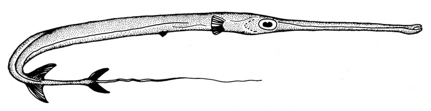

**Figure 2.11:** *Fistularia commersonii*, smooth flutemouth

Cornetfishes somewhat resemble long toms, but are readily distinguished by long flutelike snouts and whiplash-like filamentous prolongation of middle caudal (tail) fin rays (Munro 1967: p.149).

A lower-level reconstruction is PCP *baba ‘*Fistularia*, flutemouth’ (Geraghty 1994: p.148). Hooper 1994 (p.200) offers PPn *tao-tao ‘*Fistularia* sp., flutefish’, which no doubt reflects the fish’s spearlike form (PPn *tao ‘spear’).

## 16. Pipefishes, seahorses (Syngnathidae)

Most pipefishes (Syngnathidae) are long and thin, with a body covered in bony plates. Though poor swimmers and very sluggish, many are widely distributed by currents. Jointed bony armour of both species prevents active swimming. Fins are of little use and have degenerated (Munro 1967: p. 151).

The seahorse probably did not hold much interest for early Oceanic speakers, being neither economically useful nor dangerous. Collected terms for it are rare, as evidenced by responses to a request from Bruce Biggs on the an-lang e-mail list in 1999.[^8]: However, a common element is apparent from NNG, MM and SES terms, reinforced by a term from Yamdena (CMP), *bwa-watan* ‘seahorse’ (*bwaye* ‘crocodile’) which permits reliable reconstruction of the word for crocodile as the first element in an otherwise variable compound.

| **PMP** |  | *buqaya | ‘*Hippocampus* sp., seahorse’ (+ modifier) (Blust 2002) |
| --- | --- | --- | --- |
| **POc** |  | *puqaya | ‘seahorse’ (+ modifier) |
| NNG | Numbami | *yuwaya tina* | ‘seahorse’ (lit. ‘crocodile mother’) |
| NNG | Bariai | *puaea gerei-rei* | ‘seahorse’ (*puaea* ‘crocodile’, *gereirei* ‘newly-hatched’) |
| MM | Roviana | *vu-vua* | ‘seahorse’ (*vua* ‘crocodile’) |
| SES | Lau | *fuasa niʔafu* | ‘seahorse’ (lit. ‘crocodile of green seaweed’) |
| SES | Arosi | *bote huasa* | ‘seahorse’ (lit. ‘crocodile louse’) |

cf. also:

| SES | Gela | *hinapi ni vua* | ‘various pipefish spp.’ (lit. ‘crocodile limestick’) |
| --- | --- | --- | --- |

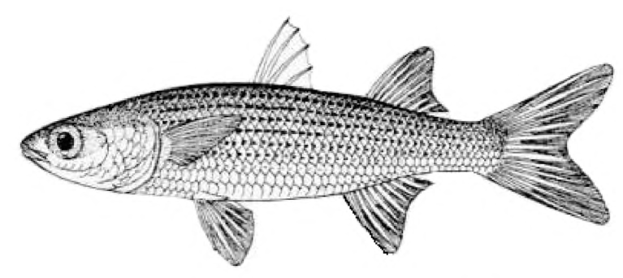

**Figure 2.12:** *Mugil cephalus*, flathead grey mullet

Kove (NNG) uses the same comparison, albeit with a non-cognate term for ‘crocodile’, *baɣele ele ɑto* ‘seahorse, pipefish’ (bayele ‘crocodile’, *ele* ‘its’,*ato* ‘messenger’) (Ann Chowning, pers. comm.[^9]:). In Dobu (PT) the term for crocodile is *warigoa*, and that for seahorse or pipefish *wari-warigoa*, reduplication of the first two syllables being a common way of indicating an inferior or diminutive form of the named item (Ross 2005b: 199).

## 17. Razorfishes (Centriscidae)

Razorfish are small, extraordinarily modified fishes which are extremely flattened and practically transparent. They swim in small schools, each in a vertical position with head downward among branching corals or sea urchins (Munro 1967: p. 148). The name in Gela for *Aeoliscus strigatus*, razorfish is *iya tuyuru*, literally ‘standing fish’. They also ‘sleep’ under the sand and will disappear under the sand when threatened by predators (Allen & Swainston 1993:82). No reconstructions have been made.

## 18. Mullets (Mugilidae)

Some mullet species are extremely abundant, occurring in large schools in coastal waters and estuaries. At least one species resides permanently in fresh water. The fish usually swim near the surface and congregate among grass-like plants on tidal flats. They are readily taken in hauling seines, although many possess great leaping powers and escape. The flesh is tasty and rich, with few bones (Munro 1967: p. 164).

Named growth stages of *Valamugil cunnesius* are listed from Dobu (PT) and three Polynesian languages. They run from from smallest to largest.

| Dobu: | *gwala*, *tonamua*, *iyakayo*. |
| --- | --- |
| Niuatoputapu: | *teʔefō*, *ʔaua*, *ʔauapuna*, *ʔualele*, *kanahe*. |
| Tongan: | *teʔevela*, *teʔekona*, *teʔefō*, *ʔunomoa*, *kanahe*, *kanahe fan*. |
| Hawaiian: | *pua* [child] *ʔama*, *puaʔamaʔama*, *pua po ʔolā*, *ʔoʔolā kahaha*, *ʔamaʔama, ʔanae*. |

| **PMP** |  | *kanasay | ‘mullet’ (ACD) |
| --- | --- | --- | --- |
| **POc** |  | *kanase | ‘mullet spp. including *Valamugil cunnesius*’ |
| Adm | Loniu | *kanas* | ‘sea mullet’ |
| Adm | Lou | *kanas* | ‘k.o. fish’ |
| Adm | Drehet | *kanah* | ‘k.o. fish, about 35cm, silvery, black-edged’ |
| MM | Patpatar | *anas* | ‘k.o. fish, small and white, salt and fresh water’ |
| MM | Teop | *anahi* | ‘mullet generic’ |
| SES | Sa’a | *ʔanate* | ‘mullet’ |
| SES | Arosi | *ʔanate* | ‘mullet’ |
| SES | Bauro | *ɣanate* | ‘*Liza cephalus*’ |
| SES | Kahua | *ɣanate* | ‘*Liza cephalus*’ |
| TM | Buma | *onole* | ‘bluespot mullet, *Valamugil seheli*’ |
| TM | Vano | *anala* | ‘bluespot mullet, *Valamugil seheli*’ |
| **PNCV** |  | *kanase | ‘mullet’ (Clark 2009: 107) |
| NCV | Mota | *ɣanase* | ‘mullet’ |
| NCV | Mwotlap | *na-ɣnah* | ‘*Chelon macrolepis*’ |
| NCV | Ambae | *ganahe* | ‘mullet’ |
| NCV | Paamese | *anase* | ‘mullet’ |
| NCV | Namakir | *kanah* | ‘mullet’ |
| SV | Sye | *(w)ane* | ‘mullet’ |
| SV | Ura | *(w)ana* | ‘mullet’ |
| NCal | Nêlêmwa | *hâlāt* | ‘adult mullet’ |
| NCal | Iaai | *enei* | ‘adult mullet’ |
| **PCP** |  | *kanaðe | ‘*Liza* spp.’ (Geraghty 1994) |
| Fij | Rotuman | *ʔanasi* | ‘jumping mullet’ |
| Fij | Bauan | *kanaðe* | ‘Mugilidae’ |
| Fij | Wayan | *kanaðe* | ‘certain grey and blue-tailed mullet species including *Valamugil* sp.’ |
| **PPn** |  | *kanahe | ‘*Liza cephalus*, *Crenimugil crenilabis* and other mullet spp.’ (Hooper 1994) |
| Pn | Tongan | *kanahe* | ‘mullet’ |
| Pn | Niuean | *kanahe* | ‘several species of mullet. Usually refers to full-grown fish (cf. *fua-fua*)’ |
| Pn | East Uvean | *kanahe* | ‘*Liza macrolepis*’ |
| Pn | East Futunan | *kanae* | ‘*Crenimugil crenilabis*’ |
| Pn | Pukapukan | *kanae* | ‘*Crenimugil crenilabis*’ |
| Pn | Samoan | *ʔanae* | ‘*Liza cephalus*, grey mullet’ |
| Pn | Tokelauan | *kanae* | ‘*Liza cephalus*’ |
| Pn | Tikopia | *kanae* | ‘*Liza cephalus*’ |
| Pn | Māori | *kanae* | ‘*Liza cephalus*’ |
| Pn | Hawaiian | *ʔanae* | ‘full-sized mullet’ |

| **PMP** |  | *qaRuas | ‘young growth stage of mullet, *Neomyxus chaptalii*’ (ACD) |
| --- | --- | --- | --- |
| **POc** |  | *(k,q)aRua(s) | ‘mullet (generic)’ |
| Adm | Seimat | *aw* | ‘k.o. mullet, about one metre in length’ |
| Adm | Titan | *(nian) kau* | ‘mullet (generic), Mugilidae’ |
| Adm | Ponam | *au* | ‘mullet’ |
| PT | Kilivila | *kauya* | ‘k.o. fish’ |
| MM | Bulu | *karua* | ‘mullet’ |
| MM | Tolai | *karua* | ‘k.o. fish, like pilchard’ |
| SES | Gela | *ɣalua* | ‘*Crenimugil crenilabis*, warty-lipped mullet’ |
| SES | To’aba’ita | *kalua* | ‘*Mugil cephalus*’ |
| SES | Lau | *kalua* | ‘*Mugil* spp.’ |
| Mic | Kiribati | *ana* | ‘mullet (generic)’ |
| Mic | Woleaian | *yaiuwa* | ‘*Neomyxus chaplahi*, silvery mullet’ |
| Mic | Satawalese | *yayuw* | ‘mullet, *Liza* spp. (generic)’ |
| **PCP** |  | *qaua | ‘juvenile mullet’ (Geraghty 1994) |
| Fij | Rotuman | *aua* | ‘very young mullet’ (Polynesian loan?) |
| **PPn** |  | *qaua | ‘mullet sp.’ (Hooper 1994) |
| Pn | Tongan | *ʔaua* | ‘mullet sp.’ |
| Pn | Niuatoputapu | *ʔaua* | ‘second of five growth stages of *kanahe*’ |
| Pn | East Uvean | *ʔaua* | ‘growth term of *kanahe*’ |
| Pn | Samoan | *āua* | ‘grey mullet, *ʔanae* when about 5-7 cm in length’ |
| Pn | Tokelauan | *aua* | ‘*Neomyxus chaptalii*, silvery mullet’ |
| Pn | West Uvea | *aua* | ‘small mullet’ |
| Pn | Māori | *aua* | ‘*Aldrichetta forsteri*, yellow-eye mullet’ |

cf. also:

| MM | Halia | *karua* | ‘small mullet, silversides’ (for †*kalua*) |
| --- | --- | --- | --- |

Blust (2002:128) reconstructs both PMP *qaRuas and PMP *qawas, but the reflexes of the latter are almost all from languages in which *R is lost, so it is reasonable to infer that they reflect PMP *qaRuas, and that *qawas is not reconstructable.

Although the following set of forms points to POc *kaRapa, the reference is consistent only for Remote Oceanic cognates. There is a single putative Western Oceanic reflex which refers to the mandarin fish (*Synchiropus splendidus*), a distinctive, brilliantly coloured but little-known fish, not more than 10 cm in length, and very dissimilar to mullets.

| **POc** |  | *kaRapa | ‘k.o. fish’ |
| --- | --- | --- | --- |
| PT | Balawaia | *kalava* | ‘mandarin fish’ |
| **PROc** |  | *kaRapa | ‘*Liza vaigiensis*, diamond-scaled mullet’ |
| SV | Anejom̃ | *kapa(n)* | ‘adult freshwater mullet’ |
| NCal | Nêlêmwa | *kʰolâp* | ‘*Mugil macrolepis*’ |
| Mic | Carolinian | *araf* | ‘mullet’ |
| Mic | Satawalese | *yaraf* | ‘*Liza vaigiensis*’ |
| Mic | Mokilese | *kap(ce)* | ‘*Liza vaigiensis*, diamond-scaled mullet’ |
| **PCP** |  | *kava | ‘*Liza vaigiensis*’ (Geraghty 1994) |
| **PCP** |  | *kava-kava | ‘juvenile *Liza vctigiensis*’ (Geraghty 1994) |
| Fij | Bauan | *kava* | ‘fish like the kanade’ |
| Fij | Wayan | *kava* | ‘*Liza vaigiensis*’ |
| **PPn** |  | *kafa | ‘*Liza vaigiensis*’ (Hooper 1994) |
| Pn | Tongan | *kafa-kafa* | ‘*Liza vaigiensis*’ |
| Pn | East Uvean | *kafa-kafa* | ‘*Liza vaigiensis*’ |
| Pn | Samoan | *ʔafa* | ‘fish similar to grey mullet’ |
| Pn | Tokelauan | *kafa* | ‘*Liza vaigiensis*’ |
| Pn | Mangarevan | *kaʔa* | ‘*Liza vaigiensis*’ |
| Pn | Pukapukan | *kawa* | ‘*Liza vaigiensis*’ |

Geraghty 1994 (p.157) reconstructs PCP *jeqevo(o,u), PPn *teqefō ‘juvenile mullet’. John Lynch (pers. comm.) suggests that a number of New Caledonian reflexes, Fwai, Nemi, Jawe *thiāp* ‘mangrove mullet’, may be related, thus indicating PROc *jeqevo(o,u).

Hooper 1994 (p.204) reconstructs PPn *fua-fua ‘juvenile mullet’. With the addition of Wayan Fijian *vua-vua* ‘small reef fish, 2-3 cm’ this reconstruction can be raised to PCP *vua-vua ‘k.o. small fish’.

## 19. Silversides, hardyheads (Atherinidae)

These are small silvery fishes occurring in large schools in shallow coastal waters and estuaries where they can be netted. Munro (p. 171) lists a dozen or so species and describes them as useful for bait. They are similar to sardines in appearance and behaviour.

| **POc** |  | *sara(Ra) | ‘sardine-like fish, possibly Atherinidae’ |
| --- | --- | --- | --- |
| NNG | Yabem | *(i)sala* | ‘a small slippery fish’ |
| MM | Halia | *sela* | ‘sardine’ |
| **PCP** |  | *sarā | ‘k.o. small schooling fish’ (Geraghty 1994) |
| Fij | Rotuman | *sarā* | ‘k.o. fish’ |
| Fij | Bauan | *sarā* | ‘small fish like daniva, but with round white body’ |
| Fij | Wayan | *sarā* | ‘Atherinidae sp., small silvery fish in coastal waters’ |
| **PPn** |  | *sarā | ‘small schooling fish’ (Hooper 1994) |
| Pn | Tongan | *hā* | ‘very small schooling fish, like whitebait’ |
| Pn | Nukuoro | *saiā* | ‘flying fish’ |
| Pn | Luangiua | *saiā* | ‘small blue fish’ |
| Pn | Sikaiana | *saiā* | ‘k.o. fish’ |
| Pn | Takuu | *sarā* | ‘k.o. small fish’ |

## 20. Barracudas, sea-pikes (Sphyraenidae)

Barracudas are fast-swimming, carnivorous, pike-like fish, elongated and slender, which slash their prey with sharp dog-like teeth. Larger ones are regarded as dangerous because they have been known to attack humans. Munro calls them good fighters. They have firm delicate flavoured flesh and are a valuable food fish. They are normally caught by trolling. Larger species occur in coastal waters over shoals and around reefs (Munro 1967: p.161).

Growth stages of *Sphyraena barracuda*[^10]: and *Sphyraena forsteri* in Lau (SES) are *ono*, *mamal-ito*, *ili* (Akimichi 1978:308). Dye (1983:261) lists four growth stages for barracuda in the Niuatoputapu dialect of Tongan: *tupuŋa-ʔono*, *momoto*, *hapatū*, *ʔono*.

Five POc terms are reconstructable, with *qonos possibly the generic. Final *-s is indicated by Nehan and the two Te Motu reflexes. Other reconstructions refer either to a particular species or to particular growth stages.

| **POc** |  | *qonos | ‘mature *Sphyraena* spp., possibly generic for all barracuda’ (ACD: POc *qono) |
| --- | --- | --- | --- |
| NNG | Mangseng | *ono* | ‘k.o. fish’ |
| PT | Motu | *ono* | ‘*Sphyraenella chrysotaenia*. When young, these fish are *tubiara*, when adult they are *ono*’ (Oram) |
| PT | Lala | *ono* | ‘k.o. fish’ |
| MM | Nehan | *onoh* | ‘barracuda, wahoo’ |
| SES | Gela | *ono* | ‘*Sphyraena barracuda*, great barracuda’ |
| SES | To’aba’ita | *ono* | ‘*Sphyraena jello*, pickhandle sea pike’ |
| SES | Ulawa | *ono (mʷa)* | ‘*Sphyraena jello*’ |
| SES | Ulawa | *ono (sau)* | ‘*Agrioposphyraena barracuda*’ |
| SES | Sa’a | *ono* | ‘a fish, the barracuda’ |
| SES | Lau | *ono* | ‘*Sphyraena picuda* and *Sphyraena forsteri* at growth stage’ |
| SES | Arosi | *ono* | ‘*Agrioposphyraena barracuda*, *Sphyraena jello*’ |
| SES | Bauro | *ono* | ‘*Agrioposphyraena barracuda*’ |
| TM | Buma | *onoro* | ‘barracuda, *Sphyraena genie*’ |
| TM | Tanema | *onara* | ‘barracuda, *Sphyraena genie*’ |
| NCV | Mwotlap | *n-on* | ‘*Sphyraena* spp., barracuda, sea pike’ |
| NCV | Lakon | *on* | ‘barracuda’ |
| **PPn** |  | *qono | ‘*Sphyraena* spp., barracuda’ (Hooper 1994) |
| Pn | Tongan | *ʔono* | ‘k.o. fish, the barracuda’ |
| Pn | Niuatoputapu | *ʔono* | ‘large growth stage of barracuda’ |
| Pn | Tokelauan | *ono* | ‘a fish, the barracuda’ |
| Pn | Tikopia | *ono* | ‘barracuda’ |
| Pn | Hawaiian | *ono* | ‘*Acanthocybium solandri*, large mackerel type fish up to 3 metres in length’ (wahoo) |

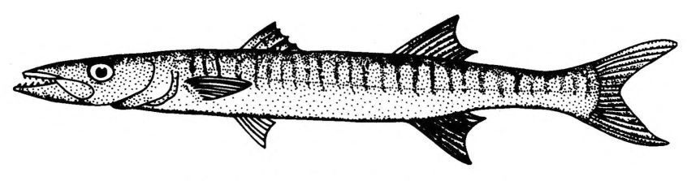

**Figure 2.13:** *Sphyraena jello*, slender sea pike

| **PMP** |  | *qalu | ‘barracuda’ (ACD) |
| --- | --- | --- | --- |
| **POc** |  | *qalu | ‘*Sphyraena* taxon, incl. *Sphyraena barracuda*, great barracuda’ |
| Adm | Titan | *al* | ‘*Sphyraena picuda*, giant sea-pike’ |
| Adm | Nauna | *kul* | ‘thick-bodied barracuda sp.’ |
| Adm | Penchal | *kul* | ‘thick-bodied barracuda sp.’ |
| Adm | Lou | *koi* | ‘thick-bodied barracuda sp.’ |
| Adm | Seimat | *al* | ‘thick-bodied barracuda sp.’ |
| Adm | Wuvulu | *alu* | ‘thick-bodied barracuda sp.’ |
| PT | Misima | *anu(wal)* | ‘*Sphyraena* spp., including giant sea-pike, chevron barracuda, striped seapike’ |
| SES | Gela | *alu* | ‘*Sphyraena putnamae*, chevron barracuda’ |
| SES | Langalanga | *ralu* | ‘*Agrioposphyraena barracuda*, giant sea pike’ |
| SES | ’Are’are | *raru* | ‘*Agrioposphyraena barracuda*’ |
| SES | Sa’a | *salu* | ‘barracuda’ |

cf. also:

| NNG | Bariai | *kalu(bia)* | ‘barracuda’ |
| --- | --- | --- | --- |

| **POc** |  | *malisa | ‘barracuda’[^11] |
| --- | --- | --- | --- |
| MM | Patpatar | *malisa* | ‘k.o. fish, big, long, black and white’ |
| MM | East Kara | *malesa* | ‘barracuda’ |
| SES | To’aba’ita | *ma-malita* | ‘*Sphyraena barracuda*’ (Barnett); ‘immature barracuda’ (Lichtenberk) |
| SES | Lau | *ma-malīto* | ‘*Sphyraena picuda* and *Sphyraena forsteri* at growth stage’ |
| Fij | Wayan | *sila-sila* | ‘largest barracudas, *Sphyraena barracuda* and possibly other *Sphyraena* spp.’ (metathesis) |

The cognate set below points to a four-syllable reconstruction *bʷara-wa(r,d,dr,R)a(q) As the parentheses indicate, the reflexes do not agree as to the identity of the second liquid. Admiralties and Papuan Tip languages reflect *d or *dr, Southeast Solomonic languages and Pije (New Caledonia) reflect *r, and Tikopia (Polynesian) reflects *R. However, it is so unlikely that this set of forms is the result of chance that we must infer that borrowing has taken place at some point. We also note that the Papuan Tip terms are glossed ‘moray eel’.

John Lynch (pers. comm.) points out that a four-syllable reconstruction is likely to be bimorphemic, i.e. *bʷara-wa(r,d,dr,R)a(q), and cites New Caledonian evidence in support of this. Nelemwa *bʷara-gom* ‘moray eel’ seems to reflect the first morpheme, and Fwai *walagan* ‘barracuda’ perhaps contains the second.

| **POc** |  | *bʷara-wa(r,d,dr,R)a(q) | ‘*Sphyraena* sp., possibly *Sphyraena jello*, the slender or pickhandle sea pike’ |
| --- | --- | --- | --- |
| Adm | Titan | *palawar* | ‘sea pike’ |
| Adm | Andra | *palawadi* | ‘k.o. fish’ |
| PT | Kilivila | *buliwada* | ‘eel’ |
| PT | Dobu | *bʷaluada* | ‘moray eel’ |
| PT | Molima | *boluwada* | ‘moray eel’ |
| PT | Tubetube | *bʷaluada* | ‘eel’ |
| SES | Longgu | *paraura* | ‘*Sphyraena barracuda*’ |
| SES | Langalanga | *barauro* | ‘*Sphyraena jello*’ |
| NCal | Pije | *barewalak* | ‘barracuda’ |
| Pn | Tikopia | *paravao* | ‘*Sphyraena jello*’ |

The next reconstruction, POc *qutur, shares the same form as a reconstruction for a very dissimilar fish, the jobfish, the latter reconstructable to PMP level (see §30). A competing gloss, ‘*Sphyraena* sp., barracuda’, is based on cognates from PT, NCV and Pn. These two etyma appear to be homonyms rather than cognates. Niuean retains a reflex of both etyma. PPT *qudur, rather than †*qutur, is reconstructable for both jobfish and barracuda.

| **POc** |  | *qutur | ‘*Sphyraena* sp., barracuda’ |
| --- | --- | --- | --- |
| PT | Muyuw | *kudu(wal)* | ‘barracuda’ |
| NCV | Mota | *utu* | ‘large long fish with very sharp teeth and small scales: a sphyraenid, barracuda’ |
| NCV | Ambae | *utu* | ‘*Sphyraena genie*, blackfm barracuda’ |
| NCV | Raga | *utu* | ‘*Sphyraena jello*, pickhandle barracuda’ |
| Pn | Niuean | *utu* | ‘*Sphyraena* spp., barracuda; *Aprion virescens*, grey jobfish’ |

| **PROc** |  | *moto | ‘k.o. fish’ |
| --- | --- | --- | --- |
| Mic | Kiribati | *moto* | ‘k.o. fish’ |
| **PCP** |  | *moto-moto | ‘growth stage of *Sphyraena* sp.’ |
| Fij | Wayan | *moto-moto* | ‘juvenile of barracuda spp.’ |
| **PPn** |  | *moto-moto | ‘*Sphyraena* sp., probably juvenile growth stage’ |
| Pn | Tongan | *moto-moto* | ‘k.o. swordfish’ |
| Pn | Niuatoputapu | *mo-moto* | ‘second growth stage of barracuda’ |
| Pn | East Uvean | *moto-moto* | ‘k.o. *Sphyraena*’ |
| Pn | Emae | *moto-moto* | ‘*Sphyraena bleekeri*’ |
| Pn | Tikopia | *moto* | ‘k.o. fish, small, light-coloured, not eaten; like lizardfish’ |

| **PMic** |  | *tarawa | ‘barracuda’ (Bender et al. 2003) |
| --- | --- | --- | --- |
| Mic | Kiribati | *tāwa* | ‘barracuda’ |
| Mic | Chuukese | *saraw* | ‘barracuda’ |
| Mic | Puluwatese | *haṛaw* | ‘great barracuda, *Sphyraena picuda*’ |
| Mic | Carolinian | *saraw* | ‘barracuda’ |
| Mic | Woleaian | *saẓawa* | ‘barracuda’ |
| Mic | Ponapean | *saraw* | ‘barracuda’ |
| Mic | Mokilese | *caraw* | ‘k.o. barracuda’ |

## 21. Sand basses, giant perches, barramundis (Centropomidae (Munro: Latidae))

These fish inhabit coastal waters, often penetrating into fresh water. They are noted for brilliant glassy eyes which glow at night. Although we have an apparent POc reconstruction, *mata-pula, lit ‘eyes’ + ‘shine’ (§24), the most consistent references of its reflexes are to *Priacanthus cruentatus* [now *Heteropriacanthus cruentatus*], ‘red globe-eye’ in Polynesian languages. The single non-Polynesian reflex, Kove (NNG) *matapula* ‘large freshwater fish’, may refer to Centropomidae.

## 22. Rock cods, reef cods, coral cods, groupers etc. (Serranidae)

These fish inhabit shallow coastal waters and estuaries, and are especially abundant around coral reefs and shoals. Many are brilliantly coloured in shades of red to brown, some with distinctive patterns. Nearly all are excellent eating. They are carnivorous and voracious, and one species, *Epinephelus lanceolatus*, the Queensland grouper, which can grow to three metres in length and up to 400 kg in weight, can be dangerous to divers (Munro 1967: p.264). Most, however, are under a metre in length. Genera include *Epinephelus*, *Cephalopholis* and *Plectropomus*, each with dozens of species. Oceanic languages typically distinguish many taxa.

Six POc reconstructions are supported. *kuRapu seems reliably to refer to the most distinctive member of the family, *Epinephelus lanceolatus*. Distinguishing the meanings of the other five reconstructions has proved difficult. The lack of conformity in glosses may be due to the possibility that the terms they represent are generic for particular groupings, with wordlists naming only the most familiar members of the set.

| **PMP** |  | *kuRapu | ‘*Epinephelus* sp.’ (Blust 2002) |
| --- | --- | --- | --- |
| **POc** |  | *kuRapu | ‘rock-cod, *Epiphenelus* sp. or spp. including *Epinephelus lanceolatus*, Queensland grouper’ |
| Adm | Mussau | *uou(na)* | ‘giant black rock cod’ |
| Adm | Titan | *apʷeu* | ‘Epinephelinae, rock cod, large’ (metathesis) |
| NNG | Tami | *gula* | ‘*Cephalopholis urodeta*, flag-tailed rock cod’ |
| NNG | Numbami | *kulawi* | ‘*Epinephelus* spp.’ |
| MM | Lihir | *kuroh* | ‘*Epinephelus polyphekadion*, camouflage rock cod’ |
| SES | Gela | *ɣulavu* | ‘sp. of large fish, young baŋa, a fish large enough to swallow a man’ |
| SES | Longgu | *ɣulava* | ‘*Cephalopholis argus*, peacock rock cod’ |
| SES | Lau | *ʔulafu* | ‘large fish, up to 2 metres long, brown or blue spots; grouper’ |
| SES | Kwaio | *ulafu* | ‘*Epinephelus* sp., giant grouper’ |
| SES | ’Are’are | *urahu* | ‘a fish, taboo for women and children’ |
| SES | Sa’a | *ulehu* | ‘*Oligorus gigas*. Six kinds of *ulehu* are named’ |
| SES | Arosi | *ʔurahu* | ‘*Oligorus gigas*, famous in tales’[^12] |
| NCV | Namakir | *kuav* | ‘grouper (generic)’ |
| SV | Sye | *uwop* | ‘grouper’ |
| NCal | Iaai | *oī* | ‘*Epinephelus hoedti*, adult/large grouper’ |
| Mic | Kiribati | *kuau* | ‘generic for rock cods, groupers’ |
| Mic | Mokilese | *kiro* | ‘large sea bass’ |
| Mic | Marshallese | *kūṛo* | ‘*E. fuscoguttatus*, grouper, rock cod’ |
| Fij | Wayan | *kʷavu* | ‘*Epinephelus hoedti*, *Epinephelus merra*, rock cod’ |

cf. also:

| NNG | Kove | *kaburū* | ‘enormous freshwater fish’ |
| --- | --- | --- | --- |
| MM | Teop | *rovu* | ‘rock cod generic’ |
| MM | Marovo | *rava* | ‘*Epinephelus lanceolatus*, found in rivers and estuaries as well as reef, including outer dropoff’ |

| **PMP** |  | *keRteŋ | ‘kind of striped or spotted marine fish, *Epinephelus* sp.’ (ACD) |
| --- | --- | --- | --- |
| **POc** |  | *koto(ŋ) | ‘large rock cod or grouper, *Epinephelus* sp.’ |
| Adm | Loniu | *kot* | ‘medium-sized rock cod or grouper’ |
| Adm | Likum | *ni-kok* | ‘large grouper, with marks like a snake’ |
| Adm | Nauna | *kot* | ‘largest kind of grouper, spotted’ |
| Fij | Wayan | *koto* | ‘largest kind of rock cod’ |
| Fij | Kadavu | *xoto* | ‘k.o. large fish’ |

| **PMP** |  | *baŋbaŋ | ‘fish sp.’ (ACD) |
| --- | --- | --- | --- |
| **POc** |  | *baba(ŋ) | ‘rock cod or grouper’[^13] |
| Fij | Bauan | *baba* | ‘large fish, like a snake, with a large mouth’ |
| Pn | Pukapukan | *papa* | ‘Variola iouti, lunar-tailed rock cod’ |
| Pn | Samoan | *papa* | ‘*Epinephelus* sp., grouper’ |
| Pn | East Uvean | *papa* | ‘generic for some *Cephalopholis* spp.’ |

| **POc** |  | *don(o,u) | ‘spotted rock cod, taxon including Cephalopholis and *Plectropomus* spp.’ |
| --- | --- | --- | --- |
| PT | Motu | *dono* | ‘brown spotted rock cod’[^14] |
| SES | Longgu | *ono(i)* | ‘fish like a shark that can swallow a man’ |
| **PCP** |  | *donu | ‘adult Plectropomus’ (Geraghty 1994) |
| Fij | Rotuman | *tonu* | ‘*Cephalopholis argus*, peacock rock cod’ |
| Fij | Bauan | *donu* | ‘Epinephelus maculatus, brown-spotted rock cod’ |
| Fij | Wayan | *donu* | ‘generic for several *Plectropomus* spp.’ |
| Fij | Kadavu | *donu* | ‘Erilepis zonifer’ |
| **PPn** |  | *tonu | ‘rock cod, when large’ (Hooper: ‘*Plectropomus leopardus*, *Plectropomus maculatus*, coral trout’) |
| Pn | Tongan | *tonu* | ‘k.o. fish, similar to *ŋatala* (rock cod)’ (*tonu puku*, *tonu kulī*, *tonu ʔuno*, *tonu ʔuli*, *tonu faŋamea*) |
| Pn | Niuatoputapu | *tonu* | ‘growth stage of rock cod, bit larger than *ŋatala*, not as big as *mala*’ |
| Pn | East Uvean | *tonu* | ‘*Plectropomus* spp.’ |
| Pn | Samoan | *tonu* | ‘*Epinephelus* sp., a metre or more long’ |
| Pn | Tokelauan | *tonu* | ‘*Plectropomus leopardus*, red-spotted rock cod’ |
| Pn | Tikopia | *tonu* | ‘*Plectropomus leopardus*, *ŋatara* when very large’ |
| Pn | Tahitian | *tonu* | ‘*Plectropomus leopardus*’ |

The gloss of ‘rock cod, grouper’ for the following reconstruction is based on reflexes from Dobu (PT) and Fiji. In Gitua, Arosi, Woleaian and Hawaiian, apparent reflexes refer to trevally, blenny, parrotfish or wrasse, while elsewhere in Polynesia they refer to the crescent perch, *Terapon jarbua* (§35). Such fish have little in common, and the similarity of name may be coincidental.

| **POc** |  | *kawa-kawa | ‘rock cod, grouper’ |
| --- | --- | --- | --- |
| PT | Dobu | *kawa(tabuya)* | ‘rock cod, coral cod, reef cod, coral trout’ |
| Fij | Bauan | *kawa-kawa* | ‘Serranidae, yellow-finned grouper’ (syn. *gawa-gawa*) |
| Fij | Wayan | *kawa-kawa* | ‘k.o. rock cod, poisonous’ |

cf. also:

| NNG | Gitua | *kawa-kawa* | ‘golden trevally’ |
| --- | --- | --- | --- |
| SES | Arosi | *ʔaʔawa* | ‘blenny’ |
| Mic | Woleaian | *xawe-xaw* | ‘*Chlorurus* spp.’ (parrotfish) |
| Pn | Tongan | *kava-kava* | ‘k.o. fish with small scales and longitudinal stripes, the scavenger fish’ (*Lethrinus* sp.? See *oka, §36) |
| Pn | Niuatoputapu | *kava-kava* | ‘*Terapon jarbua*’ |
| Pn | East Uvean | *kava-kava* | ‘*Terapon jarbua*’ |
| Pn | Samoan | *ʔava-ʔava* | ‘*Terapon* sp.’ |
| Pn | Hawaiian | *ʔaʔawa* | ‘*Bodianus bilunulatus*, wrasse’ |

| **POc** |  | *kalika | ‘Epinephelidae, rock cod’ |
| --- | --- | --- | --- |
| Adm | Wuvulu | *alia* | ‘grouper sp.’ |
| Adm | Titan | *kaliy* | ‘Epinephelidae, rock cod’ |
| Adm | Ere | *kaliy* | ‘grouper sp.’ |
| Adm | Nyindrou | *kalik* | ‘grouper sp.’ |
| Mic | Satawalese | *yaniy* | ‘Epinephelidae, rock cod (generic)’ |

Distinctive markings are often reflected in compound terms such as the following:

| MM | Patpatar | *mata girit* | ‘k.o. fish’ (*mata* ‘face’, *girit* ‘to sketch, draw’) |
| --- | --- | --- | --- |
| MM | Halia | *mata goumana* | ‘giant chanda perch, freshwater fish’ (*goum* ‘marking, scar’) |
| SES | Gela | *aŋora gere* | ‘*Cephalopholis sexmaculata*, six spotted rock cod’ (*gere* ‘to sketch, make lines’) |
| SES | Gela | *kusele gere-gerea* | ‘*Epinephelus quoyanus*, longfin rock cod’ (*gere-gere* ‘to sketch, make lines’) |

Lower level reconstructions include PNCV *tabʷale ‘grouper fish’ (François 2005:499), PCP *ŋʷajala ‘*Epinephelus* spp.’, PPn *ŋatala ‘Epinephelus, smaller stage’, PCP/PPn *munua ‘large *Epinephelus* sp.’, PCP *dralā ‘red *Cephalopholis* sp.’, PPn *lalī ‘red rock cod spp.’, PPn *fāpuku ‘*Epinephelus* sp., possibly *Epinephelus polyphekadion*. marbled sea bass’, PPn *loi ‘*Cephalopholis argus*, peacock rock cod’, PPn *mataele ‘Serranidae’ (Geraghty 1004: p.149, Hooper 1994: pp.204-205)

## 23. Flagtails (Kuhliidae)

Munro 1967 (p.254) describes Kuhliidae as small to moderate-sized fishes, generally inhabiting shallow coastal waters, with some species preferring brackish or fresh water, often in the vicinity of mangroves. Salt-water species are a brilliant silver. Our only reconstructions are lower-level: PCP *sere, PPn *sesele ‘immature Kuhlia rupestris’, PCP *drava ‘k.o. small freshwater fish, possibly *Kuhlia* sp.’ (Geraghty 1994: p.150) and PPn *safole ‘*Kuhlia* spp., flagtail’ (Hooper 1994: p.206).

## 24. Bigeyes, bullseyes (Priacanthidae)

These are small to moderate-sized fishes of distinctive appearance. All are bright rosy with a rough sandpapery skin. The eye is large, about half head size. They are nocturnal, typically spending daylight in caves or under ledges (Munro 1967: p.284).

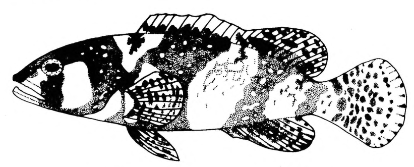

**Figure 2.14:** *Epinephelus lanceolatus*, Queensland grouper

The PPn term, *mata-pula ‘*Priacanthus cruentatus*, red globe-eye’ is a descriptive compound (lit. *mata* ‘eye’ + *pula* ‘shine, glow’) (Hooper 1994: p.202). The same compound is found in Kove (NNG), where the referent is a large freshwater fish, probably Centropomidae (§21).

## 25. Cardinalfishes (Apogonidae)

Cardinalfish are small carnivorous fishes. Many are vividly coloured, with striking patterns of bands, stripes or spots. Most live in or around coral reefs and amongst weeds, and in shallow tidal pools, although some prefer brackish water and others inhabit deeper water. Like the Priacanthidae, they are nocturnal, hiding under ledges or in crevices during daylight. The male usually carries the eggs and newly hatched young in its mouth (Munro 1967: p.241). No reconstructions have been made.

## 26. Jacks, trevallies, scads, horse mackerels, kingfishes, darts, rainbow runners and leatherskins (Carangidae)

This is a large, widely distributed family of fast-swimming surface predators which generally inhabit the coastal edge of the deep water. Larger species frequent edges of reefs. Most congregate in schools, and can be caught along beaches with seines. Their flesh is of good texture and flavour (Munro 1967: p.221). Oceanic languages typically distinguish many taxa.

In Niuatoputapu, deep sea anglers take pride in withstanding the rigours of a dusk to dawn session of *lauʔotule*, fishing from an anchored boat in around 17 fathoms of water, and using a pressure gas lamp to attract the fish (big-eyed scad, *Selar crumenophthalmus*) (Dye 1983:250).

I have six POc reconstructions, but can be confident of matching terms with specific genera for only four, POc *qatule ‘Selar spp., scad’, POc *pilu ‘Caranx spp., trevally’, POc *lasi ‘*Scomberoides* spp., leatherskin’ and POc *kamaRi ‘*Elagatis bipinnulata*, rainbow runner’. Other genera include *Carangoides*, *Trachinotus*, *Gnathanodon*, and *Decapterus*. Where the reflexes cover a range of genera, the reconstructions are simply labelled carangid. The popularity of these fish both as sporting fish and as food, and their role in places as appropriate tribute for chiefs, are reflected by the number of terms for their growth stages. Here I can reconstruct PPn terms for growth stages, *lupo-lupo for the smallest and *qulua for a large caranx, (not necessarily the largest).

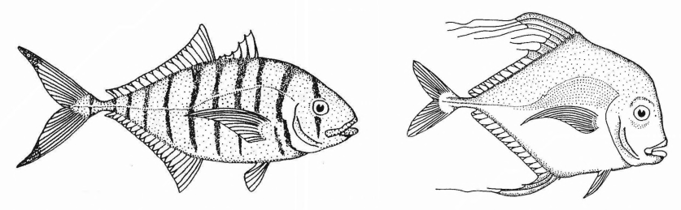

**Figure 2.15:** **Left** *Gnathanodon speciosus*, golden trevally. **Right** *Alectis indica*, plumed trevally.

| **PMP** |  | *qatulay | ‘*Trachurops crumenophthalmus*, the big-eyed scad’ (ACD) |
| --- | --- | --- | --- |
| **POc** |  | *qatule | ‘*Selar* spp. including *Selar crumenophthalmus*, big-eyed scad’ |
| Adm | Titan | *atul* | ‘scad (generic)’ |
| PT | Molima | *ʔatune* | ‘fish that looks like pilchard’ |
| PT | Muyuw | *geytula* | ‘trevally, scad’ (Damon) |
| PT | Misima | *atuni* | ‘generic for trevally, scad’ |
| Mic | Kosraean | *œtol* | ‘large mackerel’ |
| Mic | Sonsorolese | *adir* | ‘caranx’ |
| **PCP** |  | *qatule | ‘*Selar crumenophthalmus*’ (Geraghty 1994) |
| Fij | Rotuman | *afule* | ‘kind of fish (silver bream?)’ |
| Fij | Wayan | *atule* | ‘*Selar crumenophthalmus*’ |
| Fij | Kadavu | *ātule* | ‘Caesio, *Rastrelliger* spp.’ |
| **PPn** |  | *qatule | ‘Selar crumenopthalmus, silver scad’ (Hooper 1994) |
| Pn | Niuatoputapu | *ʔolule* | ‘*Selar crumenophthalmus*’ |
| Pn | Niuean | *atule* | ‘big-eyed scad’ |
| Pn | East Uvean | *ʔatule* | ‘*Selar crumenophthalmus*’ |
| Pn | Anutan | *ature* | ‘type of small fish that comes into the shallow reef water in large schools. Ranges in size from about one to one and a half pounds’ |
| Pn | Tahitian | *ature* | ‘horse-mackerel’ |
| Pn | Hawaiian | *akule* | ‘big-eyed or goggle-eyed scad, *Selar crumenophthalmus*’ |

| **PMP** |  | *bilu[bilu] | ‘*Caranx* spp., trevally’ (ACD; Blust 2002: *pilu ‘*Gnathanodon* sp.’) |
| --- | --- | --- | --- |
| **POc** |  | *pilu | ‘*Caranx* sp. or spp., trevally’ |
| NNG | Gitua | *pilu* | ‘k.o. trevally’ |
| NNG | Gitua | *pilu-pilu* | ‘small trevally varieties’ |
| PT | Misima | *vilu* | ‘*Gnathanodon speciosus*. golden trevally’ |
| NCV | Lakon | *vʊl* | ‘*Caranx ignobilis*, giant trevally’ |
| NCV | Dorig | *vʊl* | ‘*Caranx ferdau*, blue trevally’ |
| NCal | Iaai | *vine(s)* | ‘large *Caranx* sp.’[^15] |
| **PCP** |  | *vilu | ‘Gnathanodon, Trachinotus’ (Geraghty 1994) |
| Fij | Bauan | *vilu* | ‘small deep-bellied fish like the saga (trevally, *Caranx* spp.), but dark in color and with no teeth’ |
| Fij | Wayan | *vilu* | ‘*Gnathanodon speciosus*’ |
| **PPn** |  | *filu | ‘Carangidae’ (Hooper 1994) |
| Pn | Tongan | *filu* | ‘k.o. fish’ |
| Pn | East Uvean | *filu* | ‘Trachinotus’ |
| Pn | Samoan | *filu* | ‘Carangoides’ |
| Pn | Hawaiian | *hilu* | ‘various species of reef fishes of the genus Coris’ |

Reflexes of the next set have consistent reference to larger species only in the Central Pacific. *Caranx ignobilis* and *Caranx sexfasciatus* are among the largest of the trevallies.

| **POc** |  | *qulua | ‘carangid’ (ACD: ‘*Caranx* spp.’) |
| --- | --- | --- | --- |
| NNG | Gedaged | *ulua* | ‘white marine fish about 20 cm long’ |
| PT | Dobu | *ʔuliya* | ‘*Decapterus macarellus*, mackerel scad’ |
| **PPn** |  | *qulua | ‘*Caranx* sp., probably mature phase of *Caranx ignobilis*’ (Hooper 1994) |
| Pn | Tongan | *ʔulua* | ‘very large fish: a full-sized *lupo* (trevally)’ |
| Pn | Niuatoputapu | *ʔulua* | ‘largest growth stage of trevally’ |
| Pn | Niuean | *ulua* | ‘*Caranx ignobilis*, *Caranx sexfasciatus*’ |
| Pn | Samoan | *ulua* | ‘name given to two species of fish of genus Caranx when about a metre long, and considered to be a present fit for a chief’ |
| Pn | Rennellese | *ʔugua* | ‘generic name for some crevalles (or trevallies), e.g. plumed trevally, mirrorfish, long-finned trevally’ |
| Pn | Tahitian | *urua* | ‘cavalla’ (Henry 1971:390) |
| Pn | Marquesan | *uʔua* | ‘*Caranx ignobilis*’ |
| Pn | Hawaiian | *ulua* | ‘general name for *Caranx* spp.’ |

cf. also:

| Mic | Kiribati | *urua* | ‘adult trevally’ (for †*unua*) |
| --- | --- | --- | --- |

| **POc** |  | *mamula | ‘carangid’ |
| --- | --- | --- | --- |
| NNG | Tami | *mamul* | ‘*Gnathanodon speciosus*, golden trevally’ |
| PT | Kilivila | *mamila* | ‘*Chorinemus tolooparah*, queenfish’ |
| MM | Lihir | *mamul* | ‘*Carangoides* spp., small trevallies’ (*mamul* is generic for trevally in Solomons Pidgin) |
| SES | Gela | *mamula* | ‘k.o. small fish’ |
| SES | To’aba’ita | *mamula* | ‘*Caranx melampygus*, bluefin trevally’ |
| SES | Kwaio | *mamula* | ‘k.o. fish’ |
| SES | Lau | *mamula* | ‘k.o. fish’ (=*ʔeda-ʔeda*) |
| SES | Arosi | *mamura* | ‘k.o. fish’ |
| SES | ’Are’are | *mamu* | ‘*Caranx melampygus*’ |
| Mic | Woleaian | *mamʷu(six)* | ‘mackerel scad, Decapterus’ (*-six* ‘small’) |

Oceanic reflexes of the next set refer fairly consistently to *Scomberoides* spp. (=Chorinemus), fishes known variously as leatherskin, whitefish, queenfish, skinnyfish or giant dart. They can grow to over a metre in length. Blust (ACD) has reconstructed PMP *lajih ‘dolphinfish’ and PMP *daRi ‘leatherskin’, with Oceanic reflexes of the former apparently referring to the leatherskin. The two Mutu (NNG) terms below suggest that the dolphinfish may sometimes be referred to as the leatherskin’s mother. For dolphinfish sets, see §27 below.

| **PMP** |  | *lajih | ‘dolphinfish’ (ACD) |
| --- | --- | --- | --- |
| **POc** |  | *laci | ‘*Scomberoides* spp., leatherskin, including *Scomberoides lysan*’ |
| Adm | Ere | *las* | ‘flat fish found in river mouths’ |
| Adm | Loniu | *las* | ‘flatfish fish similar to a mackerel’ |
| Adm | Leipon | *las* | ‘k.o. flat, silvery fish’ |
| Adm | Titan | *las* | ‘*Scomberoides lysan*, skinnyfish or giant dart’ |
| Adm | Andra | *las(ei)* | ‘*Ulua mandibularis*’ |
| NNG | Mutu | *las* | ‘*Scomberoides commersonnianus*, leatherskin’ |
| NNG | Mutu | *las tina* | ‘*Coryphaena hippurus*, dolphinfish’ |
| NNG | Gedaged | *las* | ‘whitish-grey marine fish about 2.5 metres long’ |
| NNG | Bing | *lās* | ‘leatherskin’ |
| PT | Motu | *ladi* | ‘*Chorinemus* spp., leatherskin’ (Scomberoides) |
| MM | Patpatar | *lasis* | ‘k.o. fish, big and white’ |
| MM | Lihir | *las* | ‘*Scomberoides lysan*, double-spotted queenfish’ |
| MM | Nehan | *lah* | ‘leatherskin, giant dart’ |
| MM | Marovo | *lasi-lasi* | ‘*Scomberoides commersonnianus*, leatherskin’ |
| SES | Gela | *lai-lahi* | ‘Scomberoides generic’ |
| SES | Arosi | *rasi* | ‘fish sp.’ |
| Mic | Kiribati | *nari* | ‘*Scomberoides lysan*’ |
| Mic | Ponapean | *lāc̣* | ‘*Atule mate*, jack’ |
| Mic | Mokilese | *lāt* | ‘fish sp., kind of skipjack’ |
| **PCP** |  | *laði | ‘*Scomberoides* sp.’ (Geraghty 1994) |
| Fij | Wailevu | *laði* | ‘Scomberoides tol’ |
| **PPn** |  | *lai | ‘Scomberoides’ (Hooper 1994) |
| Pn | Tongan | *lai* | ‘k.o. fish’ |
| Pn | Niuean | *lai(loa)* | ‘*Scomberoides lysan*, leatherskin or leatherback’ (*loa* ‘long’) |
| Pn | Samoan | *lai* | ‘*Scomberoides* sp.’ |
| Pn | Hawaiian | *lai* | ‘*Scomberoides* sp.’ |

| **POc** |  | *kamaRi | ‘*Elagatis bipinnulata*, rainbow runner’ |
| --- | --- | --- | --- |
| Adm | Titan | *kamei* | ‘*Elagatis bipinnulata*’ |
| Adm | Nali | *kemei* | ‘*Elagatis bipinnulata*’ |
| Mic | Kiribati | *kamā* | ‘*Elagatis bipinnulata*’ |

Malcolm Ross (vol.2,49-50) reconstructs POc *mala ‘resembling’ which occurs in plant names and occasionally, it seems, in fish names as well. Of the terms listed in the set below, those consisting of a compound *mala* + modifier could all be considered ‘resembling’ examples. If this is the common meaning of *mala we would expect it to be reflected in terms for fishes not necessarily related.[^16]: The fact that the most frequent reference in this set is to carangids suggests that a similar form was a POc fish name. However, because the carangid examples are largely restricted to the Solomons (the only exception being Samoan), it may be that *mala came to be used in the Solomons as a generic for carangids, as Hviding has suggested for Marovo. For this reason no POc reconstruction is proposed.

| MM | Patpatar | *mala(la)* | ‘k.o. fish’ |
| --- | --- | --- | --- |
| MM | Nehan | *mala(ŋuh)* | ‘*Trachinotus russelli*, common dart’ (*ŋuh* ‘kiss’; *Trachinotus botla*) |
| MM | Marovo | *mara* | ‘generic for all Carangids (trevallies etc.)’ (15 compound terms for kinds; for †*mala*) |
| SES | Gela | *mala(boro)* | ‘*Selaroides leptolepis*, smooth-tailed trevally’ (*mala* ‘as, like’; boro ‘bottom, keel of canoe’) |
| SES | Gela | *mala(hau)* | ‘various kingfish and jack spp.’ (*hau* ‘old’) |

| **PPn** |  | *mala | ‘k.o. fish’ |
| --- | --- | --- | --- |
| Pn | Tongan | *mala* | ‘large serranid’ |
| Pn | Niuatoputapu | *mala* | ‘k.o. fish’ |
| Pn | Samoan | *mala(uli)* | ‘certain fish of genus Caranx (considered fit for chiefs) when about 30cm long’ (*uli* ‘black’) |
| Pn | Tokelauan | *mala(tea)* | ‘*Cheilinus undulatus*’ (*tea* ‘white’) |

| **PEOc** |  | *taliku | ‘Carangid’ |
| --- | --- | --- | --- |
| SES | Gela | *taliɣu(mane)* | ‘*Caranx ignobilis*, giant trevally’ (*mane* ‘male’) |
| SES | Arosi | *ariu* | ‘k.o. fish, kingfish’ |
| SES | Kahua | *ariu* | ‘jack, Carangidae (generic)’ |
| NCV | Ambae | *taliu* | ‘trevally, Carangidae’ (loss of *k* unexplained) |

| **PROc** |  | *lubo | ‘*Caranx* spp.’ |
| --- | --- | --- | --- |
| SV | Anejom̃ | *ne-ropʷ* | ‘*Caranx melampygus*’ |
| **PPn** |  | *lupo | ‘*Caranx* spp.’ (Hooper 1994) |
| **PPn** |  | *lupo-lupo | ‘juvenile *Caranx* spp.’ (Hooper 1994) |
| Pn | Tongan | *lupo* | ‘mature Caranx’ |
| Pn | Tongan | *lupo-lupo* | ‘juvenile Caranx’ |
| Pn | Niuean | *lupo-lupo* | ‘juvenile *Caranx* spp.’ |
| Pn | Pukapukan | *lupo-lupo* | ‘juvenile Caranx’ |
| Pn | Rennellese | *gupo* | ‘juvenile Caranx’ |
| Pn | Tokelauan | *lupo-lupo* | ‘juveniles of all *Caranx* spp.’ |

Lower level reconstructions include PNCV *dilit(i,u) ‘*Caranx* spp.’ (François 2005:494), PCP *i-kata, PPn *kata ‘growth term for Caranx sp’, PCP/PPn *laweŋa ‘*Alectis indicus*, plumed trevally or mirrorfish’, PCP *jeu, PPn *teu ‘Carangid’, PPn *aseu ‘*Caranx* sp.’, PPn *tafaquli ‘*Caranx* sp., possibly *C. lugubris*’ and PPn *soke(lau) ‘Carangid’ (Geraghty 1994: pp.150-151, Hooper 1994: pp.206-210).

## 27. Dolphinfishes (Coryphaenidae)

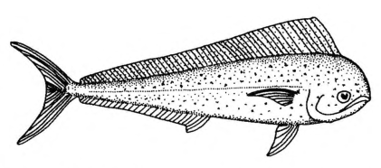

**Figure 2.16:** *Coryphaena hippurus*, common dolphinfish

Dolphinfish are large swift-swimming powerful fish, pelagic and mostly oceanic, but sometimes found around reefs. They are spectacular fighters which leap from the water when hooked. They have brilliant colouration and excellent flesh. Munro (1967: pp.218-219) records two species for the family, with *Coryphaena hippurus* being larger and better known than *Coryphaena equiselis*. They are not to be confused with dolphins, cetaceans of the family Delphinidae, although some Polynesian dictionaries gloss their term for *Coryphaena hippurus* as ‘dolphin’.

| **PMP** |  | *palata | ‘fish sp.’ (ACD: PWMP *palata) |
| --- | --- | --- | --- |
| **POc** |  | *palata | ‘*Coryphaena hippurus*, dolphinfish’ |
| MM | Marovo | *palata* | ‘*Coryphaena hippurus*’ |
| SES | Arosi | *harata* | ‘a fish sp.’ |
| Mic | Ponapean | *palac̣* | ‘fish, about 30 cm, longish nose, body light red, head salmon-pink, tail and fins dark red’ (Christian 1899) |

cf. also:

| NNG | Kove | *palaŋa* | ‘dolphinfish’ |
| --- | --- | --- | --- |
| MM | Tolai | *palatāga* | ‘k.o. fish’ |

Hooper 1994 (p.210) reconstructs PPn *masi-masi ‘*Coryphaena hippurus*, dolphinfish’, but we have found no non-Polynesian cognates.

## 28. Ponyfishes, slimys (Leiognathidae)

Ponyfishes are all very small, with a highly protractile mouth, the feature which is reflected in an alternative name, pouters. Slime is exuded in large quantities after capture. Large schools can be caught along sheltered beaches and estuaries (Munro 1967, p.237). In Lau (Malaita) they are freshwater fish, moving between the rivers and the lagoon (Akimichi 1978:310). Few terms have been located and no reconstructions made.

## 29. Fusiliers (Caesionidae)

Most fusiliers are brilliantly coloured with iridescent blue and yellow. They can be taken in great abundance near coral reefs and rocky shores. Very large schools migrate for long distances. They swim with synchronised quick precision. Flesh is coarse but not unpalatable (Munro 1967: p.300). Hooper quotes Lewis et al. as describing them as important tuna baitfish in many areas (Hooper 1994: p.192). This may explain why the Tokelauan term for mackerel scad, a different fish but also a tuna baitfish, is cognate with terms for fusilier species in the following set.

| **PMP** |  | *sulig | ‘*Caesio* sp., fusilier’ (Blust 2002) |
| --- | --- | --- | --- |
| **POc** |  | *suli(k) | ‘Caesionidae, fusilier’ |
| Adm | Loniu | *(ña)cun* | ‘fusilier’ |
| MM | Lihir | *sil* | ‘Caesionidae (generic)’ |
| Mic | Satawalese | *tīn* | ‘*Caesio* spp., fusilier’ |
| **PPn** |  | *huli | ‘fusilier sp.’ (Hooper 1994: ‘fusilier or mackerel sp.’) |
| Pn | Tongan | *huli* | ‘k.o. fish’ |
| Pn | Samoan | *uli(sega)* | ‘*Caesio* sp.’ |
| Pn | Tokelauan | *uli* | ‘*Decapterus pinnulatus*, mackerel scad’ (*Decapterus macarellus*) |
| Pn | Kapingamarangi | *uli* | ‘*Caesio coerulaureus*, gold-banded fusilier’ |
| Pn | Pukapukan | *uli* | ‘large size of *tikava*, *Pterocaesio tile*, tricoloured fusilier’ |

PCP/PPn *tikawa ‘*Caesio* sp.’ is reconstructed by Geraghty (1994: p.152), Hooper (1994: p.210).

## 30. Snappers or sea-perch, basses, jobfishes (Lutjanidae)

Snappers are rather large fish with a sheathed maxillary, typically red or yellow in colouring. Although known largely as reef fishes inhabiting rocky bottoms, the family includes deep sea snappers. Their flesh is highly esteemed, although a few have been implicated in ciguatera poisoning (Munro 1967: p.288).

There are many species of Lutjanidae, some quite distinctive in markings, and Oceanic languages typically distinguish several taxa. I have seven possible POc reconstructions but, except for POc *qutur ‘*Aprion virescens*, green jobfish’, it is difficult to give precise glosses. Some are probably names of particular species, one or two are generic for two or more species, others may be names of particular species at a certain stage of growth.

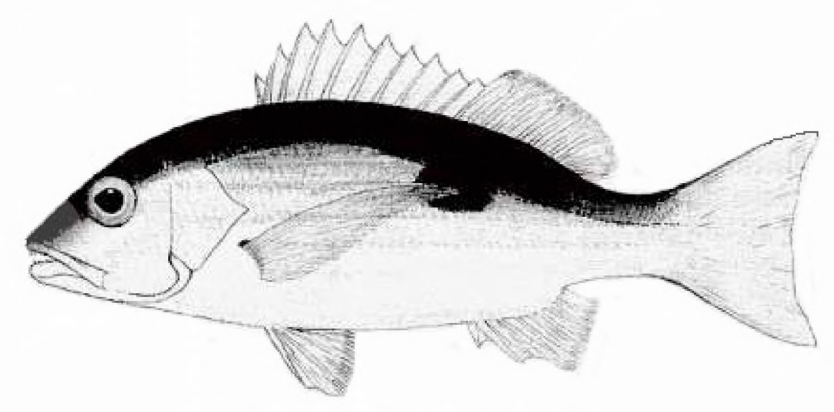

**Figure 2.17:** *Lutjanus fulviflamma*, Dory snapper

The proposed gloss of POc *qutur is based on the agreement of non-Oceanic cognates with those of the Central Pacific.[^17]: *Aprion virescens*, the green jobfish, is found at depths that vary from 0-180 metres (FishBase). See §20 regarding the homophony of this etymon with POc *qutur ‘k.o. fish, possibly *Sphyraena* sp., barracuda’ .

| **PMP** |  | *qutur | ‘green job fish’ (Blust 2002: *qutun) |
| --- | --- | --- | --- |
| **POc** |  | *qutur | ‘*Aprion virescens*, green job fish’ |
| PT | Misima | *utul* | ‘*Aprion virescens*, green jobfish’ |
| MM | Tolai | *ut* | ‘k.o. fish’ |
| SES | Arosi | *uu* | ‘k.o. freshwater fish’ |
| **PCP** |  | *qutu | ‘*Aprion virescens*, grey jobfish’ (Geraghty 1994: *quto) |
| Fij | Wayan | *otu* | ‘grey snapper, *Aprion virescens*’ |
| **PPn** |  | *qutu | ‘*Aprion virescens*, grey jobfish’ (Hooper 1994) |
| Pn | Tongan | *utu* | ‘k.o. fish’ |
| Pn | Niuean | *utu* | ‘*Sphyraena* spp., barracuda; *Aprion virescens*, grey jobfish’ |
| Pn | East Uvean | *ʔutu* | ‘*Aprion virescens*’ |
| Pn | Rennellese | *ʔutu* | ‘large fish with a long body, probably green jobfish. *Aprion virescens*’ |
| Pn | Pukapukan | *(palu) wutu* | ‘*Aprion virescens*, green jobfish’ |
| Pn | Samoan | *utu* | ‘*Aprion virescens*’ |
| Pn | Tahitian | *utu* | ‘*Aprion virescens*’ |
| Pn | Hawaiian | *uku* | ‘a deep-sea snapper, *Aprion* spp.’ |

In the set below, the Andra, Kilivila and Temotu items reflect *bʷapa rather than *bʷawa. I have no explanation for this variation. The Fijian and Polynesian reflexes show coalescence of *-wa as *-o*.[^18]:

| **POc** |  | *bʷa[p,w]a | ‘*Lutjanus* spp., snapper’ |
| --- | --- | --- | --- |
| Adm | Andra | *pʷah* | ‘*Lutjanus ehrenbergi*, snapper’ |
| Adm | Titan | *pʷa* | ‘*Lutjanus fulviflamma*, blackspot sea-perch’ |
| NNG | Yabem | *(i)bɔa* | ‘Terapon perch’ |
| PT | Kilivila | *bʷava* | ‘*Lutjanus fulviflamma*’ |
| TM | Buma | *bavolo* | ‘*Lutjanus fulvus*’ |
| NCV | Vera’a | *bawa* | ‘*Lutjanus fulviflamma*’ |
| NCV | Mwotlap | *na-baw* | ‘*Lutjanus fulvus*, *Lutjanus kasmira*’ |
| NCV | Olrat | *paw* | ‘*Lutjanus monostigma*’ |
| Fij | Kadavu | *bō* | ‘*Lutjanus adetii*, yellow-banded snapper’ |
| Fij | Wayan | *bō* | ‘*Lutjanus gibbus*, paddletail’ |
| Pn | Niuean | *(palu) pō* | ‘*Aphareus furca*, blue smalltooth jobfish’ |

cf. also:

| NNG | Bukawa | *(i)bɔʔ* | ‘Terapon perch’ |
| --- | --- | --- | --- |
| NCV | Mota | *pawa* | ‘Serranus’ |

Lutjanidae and Lethrinidae are from the same sub-order of perch-like fishes. It is possible that the next reconstruction included members of both families.

| **POc** |  | *sabutu | ‘snapper (*Lutjanus* sp. or *Lutjanus* spp.) or emperor (*Lethrinus* sp. or *Lethrinus* spp.)’ |
| --- | --- | --- | --- |
| Adm | Loniu | *saput* | ‘*Lethrinus kallopterus*, yellow-spotted emperor’ |
| PT | Sinaugoro | *rabutu* | ‘a reef fish’ |
| PT | Motu | *dabutu* | ‘Acanthopagrus berda, black bream’ |
| **PCP** |  | *(ð,s)abutu | ‘*Lutjanus* spp. and *Lethrinus* spp.’ (Geraghty 1994) |
| Fij | Rotuman | *saputu* | ‘k.o. fish’ |
| Fij | Wayan | *ðābutu* | ‘generic for several species of Lutjanidae and Lethrinidae, including *Lutjanus sebae*, red emperor, and *Lethrinus nebulosus*, spangled emperor’ |
| **PPn** |  | *s(a,ā)putu | ‘*Lutjanus* and *Lethrinus* spp.’ (Hooper 1994: ‘*Lutjanus* sp.’) |
| Pn | Tongan | *hoputu* | ‘*Lethrinus miniatus*, possibly also *Lutjanus gibbus*’ |
| Pn | Tikopia | *saputu* | ‘*Lethrinus kallopterus*’ |
| Pn | Kapingamarangi | *hāpoto* | ‘*Lutjanus rivulatus* or *Lethrinus*’ |
| Pn | Tahitian | *haputu* | ‘*Lutjanus rivulatus*’ |

cf. also:

| MM | Teop | *kabusi* | ‘*Lutjanus* (generic)’ |
| --- | --- | --- | --- |

| **POc** |  | *ta(Ra)qea | ‘*Lutjanus* spp., snapper, sea perch’ |
| --- | --- | --- | --- |
| Adm | Titan | *dra* | ‘*Lutjanus rufolineatus*, yellow-lined snapper, *Lutjanus kasmira*, yellow-and-blue seaperch’ |
| Adm | Loniu | *ta* | ‘k.o. fish’ |
| Adm | Lenkau | *dak* | ‘*Lutjanus* spp., seaperch’ |
| NNG | Yabem | *(i)tɛʔ* | ‘k.o. snapper’ |
| NNG | Bukawa | *(i)taʔ* | ‘k.o. snapper’ |
| NCV | Lakon | *tā-tā* | ‘*Lutjanus kasmira*’ |
| **PPn** |  | *tāqea | ‘*Lutjanus* sp., probably *Lutjanus gibbus*’ (Hooper reconstructs *tāeqa) |
| Pn | East Uvean | *tāeʔa* | ‘*Lutjanus fulviflamma*, blackspot seaperch’ (metathesis) |
| Pn | Pukapukan | *tāea* | ‘*Lutjanus gibbus*, paddle-tail snapper’ |
| Pn | Tokelauan | *tāea* | ‘*Lutjanus gibbus*’ |
| Pn | Tuvalu | *taea* | ‘*Lutjanus fulvus*, yellow-margined seaperch, *Lutjanus gibbus*, paddletail’ |
| Pn | Mangarevan | *tāea* | ‘*Lutjanus gibbus*’ |
| Pn | Tahitian | *tāea* | ‘*Lutjanus gibbus*’ |

| **POc** |  | *tasiwa | ‘*Lutjanus* spp.’ |
| --- | --- | --- | --- |
| Adm | Loniu | *tus* | ‘*Lutjanus sebae*, red emperor’ |
| PT | Motu | *tadiva* | ‘*Lutjanus gibbus*, paddle-tail’ |
| SES | Lau | *akʷasi (mai)* | ‘generic for four *Lutjanus* spp.’ (Akimichi; reflects metathesised form *tawasi) |
| **PCP** |  | *tasiwa | ‘*Lutjanus* sp.’ (Geraghty 1994) |
| Fij | Rotuman | *sasiva* | ‘*Lutjanus fulviflamma*, black spot seaperch’ |
| **PPn** |  | *tahiwa | ‘*Lutjanus monostigma*, one spot seaperch’ (Hooper 1994: *taqiwa) |
| Pn | Niuatoputapu | *tāiva* | ‘*Lutjanus* sp.’ |
| Pn | Pukapukan | *tāiva* | ‘*Lutjanus monostigma*’ |
| Pn | Samoan | *tāiva* | ‘*Lutjanus* sp. when about 60 cm long’ |
| Pn | Samoan | *taiva uli-uli* | ‘*Lutjanus monostigma*’ |
| Pn | Tokelauan | *tāiva* | ‘*Lutjanus monostigma*, one spot seaperch’ |
| Pn | Tahitian | *tāiva-iva* | ‘*Lutjanus monostigma*’ |

| **POc** |  | *p(a,e)ŋa | ‘red *Lutjanus* spp.’ |
| --- | --- | --- | --- |
| Adm | Titan | *peŋa* | ‘*Lutjanus sebae*, red emperor, *Lutjanus sanguineus*, seaperch’ |
| **PPn** |  | *faŋa-mea | ‘red *Lutjanus* spp., especially *Lutjanus bohar*, red bass or red snapper’ (*-mea* ‘reddish’) (Hooper 1994) |
| Pn | Tongan | *faŋa-mea* | ‘*Lutjanus bohar*’ |
| Pn | Niuean | *(palu) faŋa-mea* | ‘*Etelis carbunculus*, ruby snapper’ |
| Pn | East Uvean | *faŋa-mea* | ‘growth term of *Lutjanus bohar*’ |
| Pn | Tokelauan | *faŋa-mea* | ‘*Lutjanus bohar*’ |
| Pn | Tuamotuan | *faŋa-mea* | ‘*Lutjanus bohar*’ |

| **POc** |  | *k(i,e)pV | ‘*Lutjanus* spp., sea perch’ |
| --- | --- | --- | --- |
| Adm | Penchal | *kip* | ‘*Lutjanus* spp., sea-perch’ |
| Adm | Lou | *kip* | ‘*Lutjanus* spp., sea-perch’ |
| Adm | Lenkau | *kep* | ‘*Lutjanus* spp., sea-perch’ |
| Adm | Andra | *kih* | ‘*Lutjanus bohar*, red bass’ |
| Adm | Loniu | *keh* | ‘sea perch spp.’ |
| NNG | Takia | *kef-kef* | ‘black reef fish’ |

cf. also:

| Pn | East Uvean | *kivi* | ‘*Lutjanus bohar*’ (for †*kifi*) |
| --- | --- | --- | --- |

Also reconstructed are PCP *batisai ‘*Lutjanus monostigma*’, PCP *kʷak(a,e) ‘*Lutjanus monostigma*’ (Geraghty 1994: pp. 152-153), PPn *sawane ‘*Lutjanus kasmira*, blue-lined sea perch’ and PPn *taŋaqu ‘*Lutjanus* spp. including *Liza vaigiensis* and probably other yellow or yellow-red species’ (Hooper 1994: pp.210-211 and A. Hooper & Huntsman (1991:120).

PPn *palu is included here with supporting evidence as an unusual case. Hooper and Huntsman (1991:119-127) write that in Polynesia the two fishes which are associated most strongly with the name *palu* are unrelated: the oilfish *Ruvettus pretiosus* and the deep sea snappers (ruby snapper *Etelis carbunculus*, flower snapper *Pristipomoides zonatus*, big-eyed snapper *Pristipomoides argyrogrammicus*, and the small-toothed jobfish *Aphareus furca*). These fishes share deep water habitats, being caught at depths of 200 metres or more by handline fishing, with the long line carrying a series of spaced hooks. The technique requires great strength and skill, and Hooper quotes Roger Green as believing that it was probably a late Samoic-Outlier innovation, depending as it does on suitable deepwater environments where the fish can be found, calm water, adequate tackle and appropriate ocean-going canoe skills. We have no evidence that POc speakers fished at this depth. See §56 for Gempylidae, snake mackerels, oilfish.

| **PPn** |  | *palu | ‘oilfish; deep-sea snapper’ (Hooper 1994: ‘*Ruvettus pretiosus*, oilfish’) |
| --- | --- | --- | --- |
| Pn | Tongan | *palu* | ‘k.o. fish’ |
| Pn | Niuean | *palu* | ‘generic for a number of fish spp., mainly snapper and jobfish’ (many compounds withpalu as first element) |
| Pn | Niuean | *palu tēh* | ‘*Ruvettus pretiosus*, castor oil fish’ (lit. younger sibling of palu’) |
| Pn | Niuatoputapu | *palu* | ‘deep sea snapper’ |
| Pn | Pukapukan | *palu* | ‘*Ruvettus pretiosus*’, also first element in terms for a number of mainly deep-sea fish spp. including snapper and jobfish’ |
| Pn | Samoan | *palu* | ‘k.o. fish, *Aphareus* sp., up to a metre long’ (jobfish) |
| Pn | Tokelauan | *palu* | ‘*Ruvettus pretiosus*’ (oilfish) |
| Pn | Kapingamarangi | *palu* | ‘*Aphareus* sp.’ |
| Pn | Tikopia | *paru* | ‘several kinds of large sea fish of reddish colour, including golden-lined sea perch and snapper’ |

## 31. Monocle breams, threadfin breams, sea breams, butterfly breams (Nemipteridae)

Most are brilliantly coloured, inhabiting sand and rubble areas around reefs. The flesh is of good flavour (Munro 1967: p.308). One weakly supported reconstruction is proposed.

| **POc** |  | *marotV | ‘*Nemipterus* spp.’ |
| --- | --- | --- | --- |
| Adm | Titan | *maros* | ‘*Nemipterus* spp., butterfly bream’ |
| MM | Nehan | *marot* | ‘two-lined monocle bream; silver biddy’ |

## 32. Threadfins (Polynemidae)

These are a small family frequenting sandy shores and muddy estuaries, and at times, coral reefs. They are known chiefly for the free filaments in the pectoral fin, a feature which is reflected in its name as a reduplicated term for ‘beard’. They also have a projecting snout and large adipose eyelids, which reflect adaptation to muddy environments where sense of touch compensates for loss of vision. The flesh has excellent flavour and texture (Munro 1967: p. 189).

Our only reconstruction is at PPn level, PPn *kumi-kumia ‘*Polydactylus sexfilis*. *Polydactylus plebeius*: threadfin’ (from POc *kumi ‘beard’ (Hooper 1994:p.204). Hooper notes that the Tokelauan word for *Polydactylus sexfilis* is *ava-ava*, also meaning ‘beard’.

Misima (PT) has a term *kum-kum* ‘generic for damselfish, *Chromis* spp. and others’, considered a chance resemblance.

## 33. Mojarras, silver biddies (Gerreidae)

The mojarras are small silvery fish with very protractile jaws, superficially resembling pouters (Leiognathidae). They move in large schools, mostly along sandy shores (Munro 1967: p.331).

| **PROc** |  | *matu | ‘*Gerres* spp., silver biddy’ |
| --- | --- | --- | --- |
| NCal | Iaai | *(o)mök* | ‘*Gerres* sp.’ |
| Mic | Marshallese | *mec-mec* | ‘*Lethrinus microdon*; snapper’ |
| **PCP** |  | *matu | ‘Gerres’ (Geraghty 1994) |
| Fij | Rotuman | *mafu* | ‘k.o. fish’ |
| Fij | Wayan | *matu* | ‘*Gerres* spp.’ |
| Fij | Bauan | *matu* | ‘Gerridae’ |
| **PPn** |  | *matu | ‘*Gerres* spp., mojarras’ (Hooper 1994) |
| Pn | Tongan | *matu* | ‘k.o. fish like a silver bream’ |
| Pn | Samoan | *matu* | ‘*Gerres* sp., when about 15 cm’ |
| Pn | West Uvea | *matu* | ‘*Gerres* sp.’ |

## 34. Sweetlips, javelinfishes (Haemulidae, formerly Plectorhynchidae and Pomadasyidae)

These moderate-sized fish inhabit coastal waters around coral reefs. Some, particularly the juveniles, are strikingly marked and brightly coloured, but colour pattern varies greatly with age. The flesh flavour is good (Munro 1967: p.315).

Some of the following forms attributed to POc *(k,q)umutuR show loss of the first syllable. The only languages which disambiguate *k- from *q- are Nakanai, where *k is reflected and Wayan, where *q is reflected. The Gela term is apparently borrowed from a Northwest Solomonic language as it retains final consonant with echo vowel.

| **POc** |  | *(k,q)umutuR | ‘*Plectorhinchus* spp., sweetlips’ |
| --- | --- | --- | --- |
| Adm | Penchal | *kumut* | ‘*Plectorhinchus* spp.’ |
| Adm | Lenkau | *kumut* | ‘*Plectorhinchus* spp.’ |
| Adm | Lou | *kumut* | ‘*Plectorhinchus* spp.’ |
| Adm | Titan | *kamot* | ‘Pomadasyidae, sweet lip (generic)’ |
| Adm | Nali | *komwet* | ‘*Plectorhinchus* spp.’ |
| NNG | Mutu | *umut* | ‘*Plectorhinchus* spp.’ |
| NNG | Kove | *mutur(iŋo)* | ‘*Plectorhinchus chaetodonoides*, harlequin sweetlip’ |
| MM | Patpatar | *a-umut* | ‘many kinds spotted sweetlips’ (*a* article) |
| MM | Nakanai | *kumu* | ‘demoiselle’ |
| MM | Nehan | *mutur* | ‘sweetlip’ |
| SES | Gela | *kometulu* | ‘*Plectorhinchus* spp.’ |
| SES | Lau | *mumu* | ‘*Plectorhinchus* spp., sweetlip’ (for †*lumu*) |
| Fij | Wayan | *umotu* | ‘*Plectorhinchus flavomaculatus*’ |

| **POc** |  | *lau | ‘*Plectorhinchus* spp., banded sweetlips’ |
| --- | --- | --- | --- |
| Adm | Lenkau | *lou* | ‘*Plectorhinchus* spp.’ |
| Adm | Lou | *lo* | ‘sweetlip’ |
| Adm | Loniu | *low* | ‘sweetlip or sea bream’ |
| NNG | Manam | *lau* | ‘banded sweetlip’ |

cf. also:

| Adm | Titan | *loloi* | ‘*Plectorhinchus* spp.’ |
| --- | --- | --- | --- |
| NCV | Ambae | *lulu(kala)* | ‘oriental sweetlip’ |

## 35. Grunters, terapon perches (Teraponidae)

Teraponidae are small Indo-Pacific fish occurring in shallow tidal, brackish or fresh water. Species differ greatly in proportions and colour, some plain and others conspicuously banded. Some species make grunting noises (Munro 1967: p.320).

There is a PPn reconstruction, *kawa-kawa ‘*Terapon jarbua*, crescent perch’, based on Niuatoputapu and E Uvean *kava-kava*, Samoan *ʔava-ʔava*, all ‘*Terapon jarbua*’ but none for a higher order interstage. POc *kawa-kawa ‘rock cod, grouper’ (§22) is considered unrelated.

## 36. Emperors and large-eyed breams (Lethrinidae)

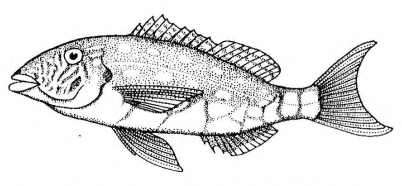

**Figure 2.18:** *Lethrinus variegatus*, variegated emperor

Emperors inhabit shallow coastal waters around rocky outcrops and coral reefs, moving in schools. Most are fairly brightly coloured in shades of red and green. Their flesh is excellent (Munro 1967: p.324). Four genera are identified, *Lethrinus*, *Gnathodentex*, *Gymnocranius* and *Monotaxis*. We have seven POc reconstructions, but in a number of instances their reflexes have come to be applied to different referents in daughter languages. In such cases reconstructions are simply labelled Lethrinidae or *Lethrinus* spp.

In the following set there has been confusion with reflexes of POc *(k,q)ulapi ‘parrotfish’ (§47) in Tokelauan.

| **PMP** |  | *kulambar | ‘*Gnathodentex* spp., *Scolopsis* spp.’ (Blust 2002: PWMP) |
| --- | --- | --- | --- |
| **POc** |  | *kulabo | ‘Lethrinidae’ |
| Adm | Lenkau | *kulom* | ‘Lethrinidae, emperor’ |
| Adm | Lou | *kulom* | ‘*Monotaxis grandoculis*, hump-nose sea bream’ |
| Adm | Titan | *kulap* | ‘Lethrinidae, sea bream’ |
| Fij | Lau (Eastern Fijian) | *kulabo* | ‘*Lethrinidae* sp.’ |
| **PPn** |  | *kulapo | ‘fish sp.’ (Hooper 1994) |
| Pn | Tongan | *kulapō* | ‘k.o. fish’ |
| Pn | Niuean | *kulapu* | ‘*Paracaesio* sp., k.o. snapper’ |
| Pn | East Uvean | *kulapo* | ‘*Lethrinus nematacanthus*, threadfin emperor’ |
| Pn | Tokelauan | *kulapo* | ‘Scants harid, juvenile; *Hipposcarus harid*’ |

cf. also:

| Fij | Rotuman | *ulapu* | ‘k.o. fish’ (*∅-* for †*ʔ-*) |
| --- | --- | --- | --- |
| Pn | Samoan | *ulapo* | ‘lighter coloured species of genus Scarus (parrotfish) when about 15 cm long’ (*∅-* for †*ʔ-*) |

Western Oceanic reflexes in the next set show unexpected loss of final syllable.

| **POc** |  | *kasika | ‘large emperor, *Lethrinus* sp.’ |
| --- | --- | --- | --- |
| Adm | Titan | *kasi* | ‘*Lethrinus miniatus*’[^19] |
| Adm | Andra | *kasi* | ‘emperor, five *Lethrinus* spp.’ |
| PT | Sinaugoro | *ari* | ‘a reef fish’ |
| PT | Motu | *adia* | ‘*Aprion virescens*, green jobfish, *Lethrinus microdon*, small-tooth emperor’ (Oram) |
| MM | Teop | *ahi-ahi* | ‘*Lethrinella miniatus*, long-nosed emperor (*Lethrinus miniatus* or *Lethrinus olivaceus*)’ |
| SES | Kahua | *ɣasiɣa* | ‘*Lethrinus elongatus*’ |
| NCV | Mwotlap | *na-wawsɪ* | ‘*Lethrinus harak*’ (thumbprint emperor) |
| NCV | Dorig | *wawsɪɣ* | ‘*Lethrinus harak*’ |
| Mic | Mokilese | *katek* | ‘k.o. emperor’ |
| Mic | Satawalese | *yœtik* | ‘*Lethrinus* sp.’ |
| Fij | Rotuman | *ʔasiʔa* | ‘snapper’ |
| Fij | Wayan | *kaðika* | ‘*Lethrinus variegatus*’ |

| **POc** |  | *surup | ‘*Lethrinus* spp.’ |
| --- | --- | --- | --- |
| MM | Tolai | *urup* | ‘k.o. large fish’ |
| MM | Lihir | *curu(bian)* | ‘*Lethrinus harak*’ |
| SES | Gela | *huru* | ‘k.o. fish with scarlet splashes on fins, head and snout’ (Fox); ‘*Lethrinus harak* and *Lethrinus obsoletus*’ (Foale) |
| SES | Lau | *suru* | ‘small sp. of reef fish (Lethrinidae); generic for Lethrinidae?’ (Akimichi 1978) |
| SES | Kwaio | *sulu* | ‘k.o. fish used in ritual’ |
| SES | Longgu | *suru* | ‘*Lethrinus elongatus*, long-nosed emperor’ |
| SES | To’aba’ita | *suru (kʷatoa)* | ‘*Lethrinus elongatus*’ (*suru* generic; *kʷatoa* ‘digging stick’ The shape of *Lethrinus elongatus* is distinctive and the specific names often refer to the pointed snout.) |
| SES | ’Are’are | *suru (horau)* | ‘*Lethrinus elongatus*’ |
| SES | Ulawa | *suru (wotola)* | ‘*Lethrinus elongatus*’ |

Despite their similarity to items reflecting POc *surup, members of the set below apparently reflect a separate etymon, since the sound correspondences of the two sets cannot be reconciled.

| **POc** |  | *susul | ‘*Lethrinus* spp.’ |
| --- | --- | --- | --- |
| NNG | Lukep | *susul* | ‘emperor’ |
| NNG | Mutu | *sul(ŋab)* | ‘*Lethrinus variegatus*, variegated emperor’ |
| NNG | Mutu | *sul(xil)* | ‘*Lethrinus elongatus*’; ‘*Lethrinus ramak*’; ‘*Lethrinus nematacanthus*’ |
| NCV | Vera’a | *(wu)sulʊ* | ‘*Lethrinus harak*’[^20] |
| NCV | Dorig | *(w)sʊl* | ‘*Lethrinus miniatus*’ |
| NCV | Lakon | *(wo)hol* | ‘*Lethrinus miniatus*’ |
| NCV | Uripiv | *no-jil* | ‘emperor’ |
| NCV | South Efate | *n-sul* | ‘emperor’ |
| SV | Anejom̃ | *ni-θiθ* | ‘*Lethrinus mahsena*’ |
| NCal | Nemi | *diruk* | ‘*Lethrinus miniatus*’ |
| NCal | Nyelâyu | *dim* | ‘*Lethrinus miniatus*’ |
| Fij | Wayan | *ðuðu* | ‘*Lethrinus variegatus*’ |

cf. also:

| Mic | Carolinian | *ulu-ul* | ‘*Lethrinus elongatus*, long-nosed emperor’ |
| --- | --- | --- | --- |

| **POc** |  | *[oka]oka | ‘k.o. fish, possibly *Lethrinus* spp.’ (ACD) |
| --- | --- | --- | --- |
| PT | Bwaidoga | *oka* | ‘fish sp.’ |
| MM | Tolai | *ok* | ‘fish sp.’ |
| Mic | Kiribati | *oka-oka* | ‘reef fish, scavenger fish, *Lethrinus obsoletus*’ |
| Pn | Kapingamarangi | *oko-oko* | ‘scavenger fish, *Lethrinus miniates*’ |

| **POc** |  | *koraŋ | ‘emperor, Lethrinidae’ |
| --- | --- | --- | --- |
| Adm | Titan | *kolaŋ* | ‘emperor, Lethrinidae’ |
| Adm | Nali | *kolan* | ‘emperor, Lethrinidae’ |
| Adm | Loniu | *walaŋ* | ‘emperor sp.’ |
| Adm | Andra | *oleŋ* | ‘*Lethrinus semicinctus*, reticulated emperor’ |
| MM | Marovo | *kora-koraŋa* | ‘small emperor’ |

It is possible that the items in the set below are related to those above through a borrowing in early Oceanic.

| **POc** |  | *kawaŋo | ‘k.o. fish, probably *Lethrinus* sp.’ |
| --- | --- | --- | --- |
| MM | Nehan | *aŋ-uaŋ* | ‘k.o. fish, probably *Lethrinus* sp.’[^21] |
| SES | Lau | *ʔakʷaŋo* | ‘k.o. large fish’ |
| SES | Sa’a | *awaŋo* | ‘k.o. fish eaten only by older men’ (*∅-* for †*ʔ-*) |
| **PCP** |  | *kawaŋo | ‘*Lethrinus nebulosus*’ (Geraghty 1994) |
| Fij | Wayan | *kawaŋo* | ‘*Lethrinus nebulosus*, spangled emperor’ |
| Pn | Tongan | *koaŋo* | ‘k.o. fish like snapper, but bluish in colour’ |
| Pn | East Uvean | *kuaŋo* | ‘*Lethrinus xanthocheilus*, yellowlip emperor’ |

| **PEOc** |  | *n(u,o)sa | ‘*Lethrinus* sp.’ |
| --- | --- | --- | --- |
| SES | Kahua | *nuta* | ‘*Lethrinus miniatus*’ |
| NCV | Ambae | *noha* | ‘*Lethrinus* spp.’ |

Also reconstructed are PCP *ŋujula ‘*Lethrinus elongates*’, PCP *kabatiko ‘*Lethrinus sp.*’, and PCP *(m,b)ū, PPn *mū ‘*Monotaxis grandoculis*, large-eyed sea bream’ (Geraghty 1994: p. 153, Hooper 1994: p.212). POc *sabutu ‘*Lutjanus* or *Lethrinus* sp.’ has also been reconstructed (see cognate set in §30)

## 37. Goatfishes (Mullidae)

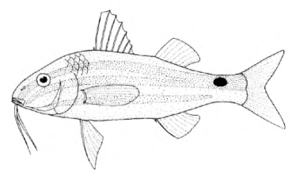

**Figure 2.19:** *Parupeneus signatus*, black-spotted goatfish

The Mullidae have large scales and two barbels at the chin. Small to moderate in size and usually red or gold, they are bottom-dwellers, often occurring in large schools (Munro 1967: p.334). Genera include *Mulloidichthys*, *Parupeneus*, *Upeneus* and *Pseudupeneus*. Both in Andra (Adm) (McEldowney 1995) and Kapingamarangi (Pn) (Lieber 1994), goatfish are reported as particularly numerous in stone fishtrap catches. Most species are considered good eating. We have five POc reconstructions, one of which is traceable with consistent referent back to PAn, and one which probably refers to a growth stage.

| **PAn** |  | *Ciqaw | ‘goatfish’ (Blust 2002; Zorc 1994) |
| --- | --- | --- | --- |
| **PMP** |  | *tiqaw | ‘goatfish’ (ACD) |
| **POc** |  | *tiqo | ‘goatfish sp. or spp.’ |
| Adm | Loniu | *tiw* | ‘goatfish sp.’ |
| Adm | Seimat | *tio-ti* | ‘barbelled fish four to five feet in length’ |
| NNG | Gedaged | *tik* | ‘k.o. goatfish’ (Mueller 1985) |
| NNG | Bing | *tiy* | ‘goatfish, commonly found in shallow waters and bays’ |
| PT | Motu | *sio* | ‘*Parupeneus* spp.’ (Oram n.d.) |
| PT | Roro | *sio* | ‘k.o. fish’ |
| PT | Gumawana | *siwo-siwo* | ‘goatfish’ |
| MM | Nehan | *tio* | ‘k.o. goatfish’ |
| MM | Teop | *sio* | ‘*Parupeneus* spp.’ |
| SES | Gela | *tio* | ‘*Parupeneus* spp.’ |
| SES | Arosi | *siʔo* | ‘k.o. fish with barbels’ (for †*sio*) |
| NCV | Mota | *tio* | ‘k.o. fish with barbels’ |
| NCV | Mwotlap | *tɪ* | ‘*Mulloidichthys flavolineatus*, yellowstripe goatfish’ |
| NCV | Raga | *sio* | ‘*Mulloidichthys flavolineatus*’ |
| Mic | Kiribati | *tewe* | ‘k.o. barbelled fish, goatfish’[^22] |
| Mic | Marshallese | *co* | ‘*Parupeneus* barberinus, goatfish’ |
| Mic | Mokilese | *ce* | ‘k.o. goatfish’ |
| Mic | Carolinian | *sōw* | ‘lagoon fish, perhaps goatfish’ |
| Mic | Woleaian | *sōwe* | ‘k.o. fish’ |
| **PCP** |  | *teu | ‘k.o. goatfish’ (Geraghty 2010) |
| Fij | Nadrogā | *seu* | ‘goatfish’ |
| Fij | Bauan | *deu* | ‘goatfish’ |

| **PPn** |  | *wete | ‘k.o. goatfish, including *Mulloidichthys*’ (Geraghty 2010) [^23] |
| --- | --- | --- | --- |
| Pn | Tongan | *vete* | ‘goatfish, *Mulloidichthys*’ |
| Pn | Rennellese | *bete* | ‘goatfish’ |
| Pn | Tikopia | *vete* | ‘goatfish’ |
| Pn | Hawaiian | *weke* | ‘*Mulloidichthys* sp.’ |

| **POc** |  | *mʷacasi | ‘goatfish’[^24] |
| --- | --- | --- | --- |
| Adm | Lou | *mʷarase* | ‘goatfish’ |
| Adm | Nali | *mʷalasei* | ‘goatfish’ |
| Adm | Loniu | *mʷasas* | ‘goatfish sp.’ (*-s-* for †*-ʔ-*) |
| Adm | Penchal | *mʷaracei* | ‘goatfish’ (*-r-* for †*-l-*) (Akimichi 1978) |
| Adm | Lenkau | *mʷasei* | ‘goatfish’ (*-∅-* for †*-h-*) |
| MM | Lihir | *mawis* | ‘*Parupeneus bifasciatus*, doublebar goatfish’ (*-w-* for †*-s-*) |
| MM | Nehan | *maheh* | ‘goatfish’ |
| SES | ’Are’are | *matasi* | ‘mullet fish’ (goatfish are sometimes known as red mullet) |
| SES | Lau | *matasi* | ‘goatfish (generic)’ |
| SES | Sa’a | *matasi* | ‘small shore fish’ |
| NCV | Vera’a | *mʷasa* | ‘*Mulloidichthys flavolineatus*, yellow-stripe goatfish’ |
| NCV | Lakon | *mʷah* | ‘*Mulloidichthys flavolineatus*’ |
| Mic | Kiribati | *māwa* | ‘goatfish’ |
| **PCP** |  | *ŋʷaðaði | ‘*Parupeneus* sp.’ (Geraghty 1994) |
| Fij | Rotuman | *vasasi* | ‘fish with small eyes and two beard-like antennae under its mouth’ |

| **POc** |  | *sua-sua | ‘goatfish’ |
| --- | --- | --- | --- |
| NNG | Manam | *sua-sua* | ‘goatfish, catfish’ |
| MM | Marovo | *sua(ra)* | ‘generic for goatfish’ |
| NCV | South Efate | *sus* | ‘goatfish’ |
| SV | Kwamera | *(ie)su* | ‘goatfish’ |
| NCal | Iaai | *(wa)si* | ‘*Mulloidichthys flavolineatus*’ |
| Fij | Wayan | *ðū-ðū* | ‘*Parupeneus* spp., goatfish’ |

The PPn reconstruction in the next set appears to be an old compound, but the meaning of *-ama is unknown.

| **POc** |  | *kalo | ‘growth stage of goatfish’ |
| --- | --- | --- | --- |
| Adm | Andra | *kale-el* | ‘*Upeneus*, goatfish’ (unexplained vowels) |
| MM | Nakanai | *kalo-kalo* | ‘little fish’ |
| Pn | Tuvalu | *kalo* | ‘*Mulloides auriflamma*’ (golden-banded goatfish) |
| **PPn** |  | *kaloama | ‘growth stage of goatfish’ (Hooper 1994) |
| Pn | Tongan | *kaloama* | ‘young goatfish’ |
| Pn | Niuean | *kaloama* | ‘yellowstripe goatfish’ |
| Pn | Niuatoputapu | *kaloama* | ‘middle growth stage of goatfish’ (*tusia* ?) |
| Pn | Pukapukan | *kalōma* | ‘young goatfish’ |
| Pn | Samoan | *ʔaloama* | ‘k.o. fish’ |
| Pn | Tikopia | *karoama* | ‘small stage of goatfish’ |

The zero reflex of initial *s- in the Ponapean, Mokilese and Lau Fijian reflexes below suggests that they are borrowings from a Polynesian language.

| **POc** |  | *sapulu | ‘goatfish spp.’ |
| --- | --- | --- | --- |
| PT | Motu | *dahuru* | ‘k.o. fish’ (*-r-* for †*-l-*) |
| Mic | Ponapean | *epil* | ‘*Mulloidichthys vanicolensis*, yellowfin goatfish’ |
| Mic | Mokilese | *ɔpil* | ‘goatfish’ |
| Fij | Lau (Eastern Fijian) | *yavulu* | ‘*Mulloidichthys vanicolensis*’ |
| **PPn** |  | *hafulu | ‘growth stage of goatfish’ (Hooper 1994: ‘goatfish, most likely *Parupeneus* spp. and *Upeneus* spp.’) |
| Pn | Niuean | *hafulu* | ‘goatfish’ |
| Pn | Samoan | *afulu* | ‘*Mulloidichthys vanicolensis*, juvenile’ |
| Pn | Tuvalu | *afulu* | ‘yellow-banded goatfish’ |
| Pn | Tikopia | *afuru* | ‘goatfish, larger stage of vete’ |
| Pn | Tahitian | *ahuru* | ‘goatfish spp.’ |
| Pn | Hawaiian | *ʔāhulu-hulu* | ‘*Parupeneus porphyreus*, juvenile’ |

cf. also:

| MM | Marovo | *ululo* | ‘*Parupeneus* spp., small types’ |
| --- | --- | --- | --- |

| **PWOc** |  | *pʷi(r,R)itu(r,R,s) | ‘k.o. goatfish’ |
| --- | --- | --- | --- |
| NNG | Lukep | *biritou* | ‘k.o. fish’ |
| PT | Misima | *pilihul* | ‘generic for goatfishes, *Mulloidichthys* spp., *Parupeneus* spp., *Upeneus* spp.’ |
| MM | Patpatar | *birite* | ‘*Parupeneus jansenii*, rosy goatfish’ |

Also reconstructed are PNCV *taŋitaŋi ‘goatfish’ (François 2005:500), PCP *oje ‘Mullidae’ and PCP *matu-xurau ‘*Parupeneus* sp.’ (Geraghty 1994: p. 154). Hooper (1994: p.214) lists PPn *memea ‘*Mulloides* sp., goatfish’ (*mea* ‘reddish’), *malili ‘goatfish taxon’ and PNPn *moaŋa ‘*Parupeneus* spp.’.

## 38. Sweepers (Pempheridae)

Sweepers are a small family of nocturnal fishes that spend daylight hours in caves and crevices of the reef. They sometimes form large aggregations which disperse after dusk and feed on zooplankton during the night (Allen & Swainston 1993:58). They are dusky silver or bright red, most with very large eyes (Munro 1967: p.349).

No POc reconstruction has been made. A lower level reconstruction includes PCP *manivi ‘*Pempheris* sp.’ (Geraghty p.155), PPn *manifi ‘*Pempheris oualensis*’ (Hooper 1994: p.213) (cf. POc *manipis ‘thin’- vol.2,202).

## 39. Drummers, rudderfishes (Kyphosidae)

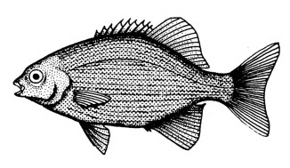

**Figure 2.20:** *Kyphosus cinerascens*, ashen drummer

Drummers or rudderfishes are a small family. Fishes are typically small, finely and closely scaled, and dull in colour. Most species are pelagic, often found under floating medusae. They are herbivorous fish, feeding chiefly on algae and seaweed. The flesh is regarded as edible but of poor quality (Munro 1967: p.352).

| **POc** |  | *maka(o,u)r | ‘Kyphosidae, drummer’ |
| --- | --- | --- | --- |
| Adm | Titan | *makao* | ‘Kyphosidae’ |
| Adm | Penchal | *makau* | ‘drummer’ |
| Adm | Nali | *makao* | ‘drummer’ |
| NNG | Kove | *makau* | ‘k.o. fish’ |
| MM | Nakanai | *makau* | ‘bream-like fish’ |
| NCV | South Efate | *(wak)makur* | ‘Kyphosidae’ (*wak* ‘pig’) |

In the next set, PPn *ranue is proposed rather than *nanue. This would have become *anue* in Pre-Tongic (where *r* > ∅), with later loss of initial *a-*. In PNPn *ranue > *lanue by regular sound change, then *nanue by assimilation.

| **PROc** |  | *r(a,e)nu(a,e) | ‘*Kyphosus*, rudderfish’ |
| --- | --- | --- | --- |
| Mic | Marshallese | *ṛənna* | ‘*Kyphosus vaigiensis*, Waigeu drummer’ |
| Mic | Carolinian | *rēl* | ‘rudderfish’ |
| Mic | Satawalese | *rə̄n* | ‘*Kyphosus* spp., drummer’ |
| **PCP** |  | *r(a,e)nu(a,e) | ‘*Kyphosus*’ (Geraghty 1994) |
| Fij | Lau (Eastern Fijian) | *rēnua* | ‘*Kyphosus*’ |
| **PPn** |  | *ranue | ‘Kyohosidae’ |
| Pn | Tongan | *nue* | ‘k.o. fish’ |
| Pn | Niuean | *nue* | ‘rudderfish or drummer, *Kyphosus* sp.’ |
| Pn | East Uvean | *nue* | ‘*Kyphosus vaigiensis*’ (possibly loan from Tongan) |
| Pn | Pukapukan | *nanue* | ‘*Kyphosus* sp.’ |
| Pn | Samoan | *nanue* | ‘*Kyphosus* sp.’ |
| Pn | Tokelauan | *nanue* | ‘*Kyphosus cinerascens*, ashen drummer’ |
| Pn | Tikopia | *nanue* | ‘*Kyphosus cinerascens*’ |
| Pn | Tahitian | *nanue* | ‘*Kyphosus* sp.’ |
| Pn | Hawaiian | *nanue, nenue* | ‘rudder or pilotfish’ |

## 40. Silver batfishes, diamondfishes (Monodactylidae)

These are small, deep-bodied, compressed fishes, distinguished by their diamond shape and silvery colour and superficially resembling the juveniles of batfishes. They inhabit shallow coastal waters, preferring brackish water and sometimes penetrating into fresh water (Munro 1967: p.348). No widespread cognate sets have been found.

## 41. Batfishes (Ephippidae (formerly Platacidae))

Allen & Swainston (1993:58) describe the batfishes of the genus *Platax* as among the most graceful of coral reef fishes. They are characterised by long, flowing fins, particularly in their juvenile and sub-adult stages. Adults have almost round bodies. Young ones resemble a leaf in colour and can sink inertly through the water, becoming difficult to see. Batfish are often extremely tame and curious. They are found both on sheltered inshore reefs and on outer slopes.

| **PMP** |  | *buna | ‘batfish’ (Blust 2002) |
| --- | --- | --- | --- |
| **POc** |  | *bunaR | ‘batfish, *Platax* sp. or spp., possibly *Naso* sp. or spp.’[^25] |
| Adm | Seimat | *pun* | ‘large flat white pelagic fish’ |
| Adm | Aua | *puna* | ‘large flat fish sp.’ |
| Adm | Andra | *(ku)punu-pun* | ‘*Platax*’ (irregular vowel) |
| NNG | Mutu | *bunar* | ‘*Platax* spp.’ |
| NNG | Kove | *buna-buna* | ‘batfish’ |
| PT | Gumawana | *bunali* | ‘batfish’ |
| PT | Motu | *buna* | ‘*Psenes arafurensis*, eyebrowfish’ (Oram n.d.) |
| MM | Nehan | *bunar* | ‘*Platax teira*, round-faced batfish’ |
| MM | Teop | *burara* | ‘batfish (generic)’ (*-r-* for †*-w-*: consonant assimilation) |
| TM | Buma | *bunero* | ‘batfish, *Platax* sp.’ |
| Mic | Mokilese | *pʷūn* | ‘batfish’ |
| Pn | Rennellese | *puna* | ‘general name for Moorish idols, batfish and some high, flat coral fish with extended fins’ |
| Fij | Wayan | *vuna-vuna* | ‘juvenile phase of seabat or angelfish, *Platax pinnatus*’ (for †*buna*) |

## 42. Butterflyfishes, coralfishes (Chaetodontidae)

Butterflyfish are among the most readily recognised of coral reef fishes due to their graceful shapes and wide range of brilliant colour patterns. Colours are usually combinations of black, red, orange, yellow and white. The fishes are diurnal and some species are extremely territorial, inhabiting one or more heads of plate coral. At dusk they retreat to reef crevices where they remain motionless until dawn (Allen & Swainston 1993:60).

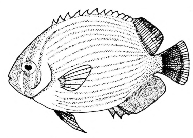

**Figure 2.21:** *Chaetodon* sp., coralfish

Both Hooper (1994: p. 188) and Hviding (1996:192) have commented on the fact that in Oceanic languages butterflyfish, coralfish and angelfish are sometimes lumped together under one generic term, although angelfish belong in a separate family, Pomacanthidae. Chaetodontidae are of little value for food, and there is apparently little point in distinguishing species or growth stages. I have two POc reconstructions, which presumably contrasted in meaning, but reflexes of both *bebek and *tipi-tipi have in some languages been used as the generic form for butterflyfish, coralfish, and perhaps others, and I have been unable to differentiate between their meanings. Although the final *-k of *bebek is not supported by the evidence given here, there can be no doubt that the same word in POc referred to both ‘butterfly’ and ‘butterflyfish’.

| **POc** |  | *bebek | ‘generic for Chaetodontidae, coralfish and butterflyfish’ (also ‘butterfly’; ch.7, §3) |
| --- | --- | --- | --- |
| Adm | Penchal | *pʷep* | ‘Chaetodontidae, coralfish’ |
| Adm | Nali | *pep* | ‘Chaetodontidae, coralfish’ |
| PT | Motu | *bebe* | ‘*Chaetodon* spp.’ (*kau-bebe* ‘butterfly’) (Oram n.d.) |
| MM | Bola | *bebe* | ‘butterflyfish’ |
| MM | Nakanai | *bebe(o)* | ‘k.o. fish’ (*bebe* ‘butterfly’) |
| SES | Kwaio | *bebe* | ‘tropical reef fish, including several species such as Moorish idol’ |
| SES | Lau | *bebe* | ‘generic for coralfish, *Chaetodon*’, butterfly’ |
| NCV | Mwotlap | *bem* | ‘*Chaetodon lineolatus*, lined butterflyfish’ |
| NCV | Lakon | *pep* | ‘*Chaetodon* (generic)’ |
| Mic | Kiribati | *(i)pʷa-pʷa* | ‘generic for coralfish, butterflyfish and some batfish’ |

| **POc** |  | *tipi-tipi | ‘Chaetodontidae’ |
| --- | --- | --- | --- |
| MM | Teop | *(ke)tepe-tepe* | ‘coralfish (generic)’ |
| NCV | Mota | *tivi-tivi* | ‘*Chaetodon*’ |
| NCV | Dorig | *tiv-tiv* | ‘*Chaetodon* spp.’ |
| **PCP** |  | *tivi-tivi | ‘*Chaetodon* spp.’ (Geraghty 1994) |
| Fij | Wayan | *tivi-tivi* | ‘butterflyfish (generic)’ |
| **PPn** |  | *tifi-tifi | ‘butterflyfish (generic)’ (Hooper 1994) |
| Pn | Niuean | *tifi-tifi* | ‘*Chaetodon* sp., butterflyfish, edible’ |
| Pn | Samoan | *tifi-tifi* | ‘general name for Chaetodontidae’ |
| Pn | Tikopia | *tifi-tifi* | ‘angelfish or butterflyfish’ |
| Pn | Kapingamarangi | *tihi-tihi* | ‘*Chaetodon* spp., *Heniochus* spp., butterflyfishes’ |

## 43. Angelfishes (Pomacanthidae)

Angelfish are small to moderate-sized marine fish, frequenting coral reefs. They are close relatives of butterflyfish and the two families are sometimes included within the same term in local nomenclature. Like butterflyfish, they have extremely brilliant colours and complicated patterns. However, they can be distinguished by possession of a prominent cheek spine which can inflict a painful wound if handled carelessly. Some undergo astonishing changes in colour and markings with age. Larger ones are valued as food (Munro 1967: p.371).

| **POc** |  | *buRi-buRi | ‘k.o. fish, possibly angelfish’ |
| --- | --- | --- | --- |
| NNG | Gedaged | *bul-bul* | ‘bluish-grey marine fish about 10 cm long’ |
| PT | Molima | *buli-buli* | ‘emperor angel fish’ |
| SES | Gela | *buli-buli* | ‘fish sp.’ |
| NCV | Uripiv | *ni-ʙi* | ‘angelfish, *Pomacanthus sexstriatus*’ |

## 44. Damselfishes or demoiselles, anemonefishes, sergeant-majors, pullers (Pomacentridae)

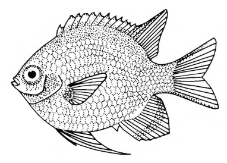

**Figure 2.22:** *Adudefduf* sp., sergeant-major

These are very active brilliant little fishes of the coral reefs, seeking shelter among branches of coral and in crevices. They are often left in tide pools. They are trim and shapely, greatly suggesting butterflyfish in mode of life. Coloration is highly variable, ranging from grey to yellow to blue. Genera include *Pomacentrus* (damselfish), *Amphiprion* (anemonefish, clownfish), *Abudefduf* (sergeant-majors) and *Chromis* (pullers), and there are dozens of species. Two POc terms are reconstructed, the second one, *taku-takuŋ, possibly the term for juveniles, those of many species being distinctively marked by a yellow body with bright blue stripes (Allen & Swainston 1993:74).

| **PMP** |  | *mutu | ‘damselfish’ (ACD) |
| --- | --- | --- | --- |
| **POc** |  | *mutu | ‘Pomacentridae, particularly *Abudefduf*’ |
| MM | Nakanai | *mutu* | ‘k.o. fish’ |
| MM | Bola | *mutu* | ‘k.o. fish’ |
| SV | Anejom̃ | *n-mʷot(anɣat)* | ‘*Abudefduf* sp.’ |
| Mic | Satawalese | *mmœs* | ‘*Abudefduf* and *Amblyglyphidodon* spp. sergeant-majors’ |
| **PPn** |  | *mutu[mutu] | ‘Pomacentridae’ (Hooper 1994) |
| Pn | Tongan | *mutu-mutu* | ‘k.o. fish’ |
| Pn | Niuean | *mutu-mutu* | ‘small grey fish with dark vertical bands, also known as *kāmuta*’ |
| Pn | East Uvean | *mutu-mutu* | ‘*Abudefduf sordidus*’ |
| Pn | Rennellese | *mutu* | ‘general name for sergeant majors and pullers (damselfish)’ |
| Pn | Samoan | *mutu* | ‘*Abudefduf* sp.’ |
| Pn | Tikopia | *mutu* | ‘Pomacentridae, coralfish, small, striped, edible’ |
| Pn | Anutan | *mutu* | ‘Pomacentridae (generic)’ |
| Pn | Māori | *mutu-mutu* | ‘fish prized for its delicacy’ |

Reflexes of POc *taku-takuŋ, reconstructed below, have been reduplicated in various ways. Gumawana and PPn both reflect *t(o,u)kukuŋ, where the first syllable, *t(o,u)- is perhaps itself a reduction of *taku-. Bing and Takia both reflect full reduplication after loss of *-k- Only Teop reflects the more usual Oceanic reduplication in *taku-takuŋ. Central Pacific terms show assimilation of the first vowel *a > *u*.

| **POc** |  | *taku-takuŋ | ‘small coral fish, damselfish or similar’ |
| --- | --- | --- | --- |
| NNG | Bing | *tuŋ-tuoŋ* | ‘sergeant-major, green and white’ |
| NNG | Takia | *doŋa-doŋ* | ‘*Pomacentrus littoralis*, brown demoiselle’ |
| PT | Gumawana | *tokuku* | ‘angelfish’ |
| MM | Teop | *tagu-tagun* | ‘angelfish (generic)’ |
| **PCP** |  | *dukuku | ‘Pomacentridae’ (Geraghty: *duku) |
| Fij | Rotuman | *tu-tuʔu* | ‘small black fish’ |
| Fij | Kadavu | *duxi-duxi* | ‘*Abudefduf*’ |
| **PPn** |  | *tukuku | ‘Pomacentridae’ |
| Pn | Tongan | *tukuku* | ‘k.o. fish, very small’ |
| Pn | Niuatoputapu | *tukuku, tokuku* | ‘*Abudefduf* *Pomacentrus* and *Chromis*’ |
| Pn | Pukapukan | *tutuku* | ‘*Dascyllus* spp.’ |
| Pn | Samoan | *tuʔuʔu* | ‘certain small queer fishes of genera *Abudefduf*, *Pomacentrus* and *Chromis*’ |
| Pn | Kapingamarangi | *takuku* | ‘*Abudefduf* sp., blue-banded damselfish’ |

## 45. Hawkfishes (Cirrhitidae)

Many Cirrhitidae are richly coloured and abundant about coral reefs and rocks. They are solitary and sedentary, frequently seen sitting on top of coral heads, from which they make quick short darts for food (Munro 1967: p.442). Two reconstructions are possible at PPn level, *patuki (Geraghty 1994: p.157) and *qulu-tuki (Hooper 1994: p.206). Their association with *tuki ‘to beat, pound’, is not understood.

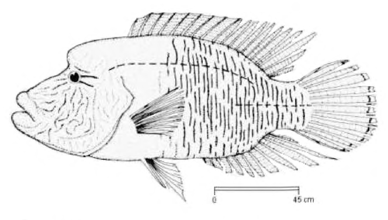

**Figure 2.23:** *Cheilinus undulatus*, double-headed Maori wrasse

## 46. Wrasses, tuskfishes (Labridae)

There are over 400 species of Labridae, falling into some 60 genera which include *Anampses*, *Bodianus*, *Cheilinus* (Maori wrasse), *Choerodon* (tuskfish), *Coris*, *Epibulus*, *Gomphosus*, *Halichoeres* and *Thalassoma*. Wrasses are brilliantly coloured, living around coral reefs and amongst weeds. Juvenile wrasses often differ from adults, and in some the sexes differ in colour and pattern. Some change colour and pattern with great rapidity (Munro 1967: pp.402, 405). They are active during daylight hours, retiring to the shelter of the reef at night. Some species, such as members of the genus *Coris*, bury themselves in the sand. Most are medium sized fishes (about 20-40 cm), but the double-headed Maori wrasse, *Cheilinus undulatus*, is notable for its size, growing to over two metres in length. Oceanic languages typically distinguish many wrasse taxa. Although I have a number of POc reconstructions, there is little consistency of reference within cognate sets, other than within Polynesia. So, although in each case the POc meaning may have been restricted to one or more species, or even to growth stages, I am obliged to reconstruct in very general terms. In the following set, the Rotuman reflex of *mamin refers not to the Maori wrasse, but to the largest parrotfish, the hump-headed parrotfish, *Bolbometopon muricatum*, which resembles it. Although Geraghty (1994: p.159) reconstructs PCP *mami ‘*Bolbometopon*, hump-headed parrotfish’, he does so presumably on Rotuman evidence alone.

| **PMP** |  | *mamin | ‘wrasse, *Cheilinus* spp.’ (ACD) |
| --- | --- | --- | --- |
| **POc** |  | *mamin | ‘*Cheilinus undulatus*, double-headed Maori wrasse and possibly other wrasse spp.’ |
| Adm | Nali | *mam* | ‘*Cheilinus undulatus*’ |
| Adm | Titan | *mam* | ‘*Cheilinus undulatus*’ |
| Adm | Loniu | *mam* | ‘wrasse’ |
| NNG | Mutu | *mam(lau)* | ‘*Coris aygula*, hump-headed wrasse; *Oxycheilinus digramma*, violet-lined Maori wrasse’ |
| PT | Gumawana | *mamina* | ‘wrasse fish’ |
| PT | Kilivila | *mamila* | ‘k.o. fish’ |
| PT | Motu | *mami* | ‘various k.o. wrasse’ |
| MM | Lihir | *mamil* | ‘*Cheilinus undulatus*, Maori wrasse’ (*-l-* for †*-n-*) |
| MM | Tolai | *mamin* | ‘*Anampses pterophthalmus*, ocellated chisel-tooth wrasse’ |
| MM | Maringe | *mamini* | ‘salt-water fish, incl. various wrasse, esp. *Cheilinus* sp.’ |
| MM | Marovo | *mimina* | ‘wrasse, prob. *Cheilinus undulatus*’ |
| NCal | Iaai | *mem* | ‘large *Cheilinus undulatus*’ |
| Mic | Chuukese | *mœ̄mi* | ‘large wrasse’ |
| Mic | Puluwatese | *mœm* | ‘k.o. fish, large, perhaps wrasse’ |
| Mic | Carolinian | *mœ̄m* | ‘*Cheilinus undulatus*’ |
| Mic | Satawalese | *mœm* | ‘*Cheilinus undulatus*’ |
| Fij | Rotuman | *mami* | ‘*Bolbometopon*, k.o. blue-green fish’ |

Both POc *mamin and POc *taŋapa(R,r) have reflexes which refer specifically to *Cheilinus undulatus*. It is possible that both POc terms referred to growth stages.

| **POc** |  | *taŋapa(R,r) | ‘large wrasse, including *Cheilinus* sp.’ |
| --- | --- | --- | --- |
| Adm | Andra | *draŋah* | ‘wrasse’ |
| Adm | Titan | *draŋ* | ‘wrasse, *Bodianus* spp.’ |
| NNG | Gitua | *taŋavaru* | ‘k.o. fish’ (*-u* unexpected) |
| MM | Ramoaaina | *taŋara* | ‘k.o. fish’ |
| NCV | Vera’a | *ʔaŋava* | ‘*Cheilinus undulatus*’ |
| **PCP** |  | *taŋava | ‘*Cheilinus undulatus*’ (Geraghty 1994) |
| Fij | Wayan | *tāŋava* | ‘*Cheilinus undulatus*’ |
| Fij | Rotuman | *fahaŋa* | ‘k.o. fish’ (metathesis) |
| **PPn** |  | *taŋafa | ‘*Cheilinus* sp.’ (Hooper 1994) |
| Pn | Tongan | *taŋafa* | ‘k.o. fish’ |
| Pn | Niuatoputapu | *(meai)taŋafā* | ‘wrasse’ |
| Pn | Samoan | *taŋafa* | ‘name given to fishes of genus *Cheilinus* when three feet long or more’ |
| Pn | Tuvalu | *taŋafu* | ‘*Cheilinus undulatus*’ |
| Pn | Tikopia | *taŋafā* | ‘sea fish, apparently a wrasse’ |

| **POc** |  | *babu | ‘*Cheilinus* spp., Maori wrasse’ |
| --- | --- | --- | --- |
| Adm | Titan | *papu(niu)* | ‘*Cheilinus trilobatus*, tripletail Maori wrasse, medium’ |
| **PPn** |  | *papu | ‘*Cheilinus* sp.’ (Hooper 1994: PNPn *pap(o,u)) |
| Pn | Rennellese | *papu* | ‘several kinds of dark brown wrasse’ |
| Pn | Pukapukan | *papo* | ‘*Cheilinus fasciatus*’ |
| Pn | Pukapukan | *papo-papo* | ‘*Cheilinus fasciatus*, juvenile’ |
| Pn | Tuvalu | *papo* | ‘*Cheilinus trilobatus*’ |
| Pn | Tokelauan | *papo* | ‘*Cheilinus fasciatus*’ |
| Pn | Luangiua | *papu* | ‘Maori wrasse’ |

cf. also:

| NCV | South Efate | *(a)fam* | ‘*Cheilinus undulatus*’ |
| --- | --- | --- | --- |

| **POc** |  | *merari | ‘wrasse or parrotfish’ |
| --- | --- | --- | --- |
| NNG | Kove | *lali* | ‘parrotfish, bright blue-green fins and tail’ (irregular loss of first syllable) |
| NCV | Ambae | *mʷera (mavute)* | ‘checkerboard wrasse? (*Halichoeres hortulanus*)’ (*mavute* ‘white’; loss of final *-ri unexpected) |
| NCV | Mota | *mera* | ‘k.o. fish’ (loss of final *-ri unexpected) |
| Mic | Marshallese | *meṛœ* | ‘parrotfish; wrasse’ |
| Mic | Ponapean | *merer* | ‘wrasse’ |
| **PCP** |  | *m[e,a]rari | ‘*Novaculichthys*, wrasse’ (Geraghty 1994) |
| Fij | Rotuman | *marari* | ‘smooth-bodied fish with thin soft scales, grey-brown with whitish spots’ |
| **PPn** |  | *m[e,a]rari | ‘wrasse or parrotfish’ (Hooper: *m(a,o)lali) |
| Pn | Tongan | *meai* | ‘k.o. fish like parrotfish’ |
| Pn | Pukapukan | *malali* | ‘*Cheilinus trilobatus*, trilobed Maori wrasse’ |
| Pn | Luangiua | *mālali* | ‘rainbow fish, k.o. Labridae’ |
| Pn | Tokelauan | *molali* | ‘*Cheilinus trilobatus*’ |
| Pn | Kapingamarangi | *malali* | ‘ornated wrasse’ |

| **POc** |  | *tapu | ‘*Labridae* sp.’ |
| --- | --- | --- | --- |
| PT | Iduna | *tafu-tafufu* | ‘small coloured fish on the reef’ |
| Mic | Satawalese | *(yœ)sœ̄p* | ‘*Gomphosus varius*, clubnosed wrasse’ |
| **PCP** |  | *tuvu | ‘*Labridae* sp.’ (Geraghty 1994) [^26] |
| Fij | Wayan | *tuvu(masi)* | ‘scribbled wrasse (*Novaculichthys taeniourus*)’ |
| Fij | Wayan | *tuvu(keli)* | ‘wrasse taxon’ |
| **PPn** |  | *tufu | ‘*Thalassoma* sp.’ |
| Pn | Tongan | *tufu* | ‘*Thalassoma*’ |
| Pn | Niuean | *tufu* | ‘k.o. parrotfish, edible’ |
| Pn | Samoan | *tufu* | ‘k.o. fish’ |
| Pn | Kapingamarangi | *tuhu* | ‘*Thalassoma* sp., fire wrasse’ |

| **PEOc** |  | *lapi | ‘wrasse’ |
| --- | --- | --- | --- |
| SES | Lau | *(mae)lafu* | ‘wrasse’ |
| NCal | Nyelâyu | *nābi* | ‘*Cheilinus undulatus*’ |
| Mic | Kiribati | *(ari)nai* | ‘rainbow family or wrasse’ |
| **PPn** |  | *la-lafi | ‘wrasse or parrotfish spp.’ (Hooper 1994) |
| Pn | Tongan | *la-lafi* | ‘*Scarus* sp.’ |
| Pn | East Uvean | *la-lafi* | ‘*Cheilinus* spp.’ |
| Pn | Pukapukan | *la-lawi* | ‘*Cheilinus undulatus*’ |
| Pn | Samoan | *la-lafi* | ‘*Cheilinus* sp., under 30 cm’ |
| Pn | Tokelauan | *lalafi, lafi-lafi* | ‘juvenile growth terms for *Cheilinus undulatus*’ |

cf. also:

| NCal | Jawe | *nami* | ‘*Cheilinus undulatus*’ |
| --- | --- | --- | --- |

Lower-level reconstructions include PCP *labe, PPn *lape [^27]: ‘Labridae, wrasse’, PPn *suŋale ‘Labridae’ and PPn *ŋutuloa ‘*Epibulis insidiator* slingjaw wrasse, or other longnosed wrasse’ (*ŋutu-loa* lit. ‘long nose’) (Geraghty p.159, Hooper pp.217-218).

## 47. Parrotfishes (Scaridae)

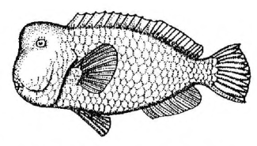

**Figure 2.24:** *Bolbometopon muricatum*, double-headed parrotfish

Parrotfish are closely related to the wrasses, although the latter are carnivorous. Parrotfish are herbivorous, typically large, the jaws with a bony beak. They are reef dwellers, feeding chiefly on vegetable matter, but their strong beaks easily crush molluscs and coral. Most pass through one to three colour phases. Juveniles are usually plain, with mottling; immatures usually patterned with red, brown or purple, adults with blue, green, yellow, orange or red patterns (Munro 1967: p.431). Like the wrasses they retreat into holes in the coral at night to sleep. Genera include *Scarus*, *Hipposcarus* and *Bolbometopon*.

| **PMP** |  | *[(k,q)]ulapi | ‘parrotfish’[^28] |
| --- | --- | --- | --- |
| **POc** |  | *(k,q)ulapi | ‘parrotfish spp., incl. *Hipposcarus longiceps*, long-nosed parrotfish’ |
| Adm | Lou | *kʷel* | ‘blue-speckled parrotfish (*Leptoscarus vaigiensis*)’ |
| Adm | Nali | *kuwei* | ‘blue-speckled parrotfish’ (Akimichi 1978) |
| Adm | Penchal | *kʷil* | ‘blue-speckled parrotfish’ |
| Adm | Andra | *ulah* | ‘*Hipposcarus harid*’[^29] |
| Adm | Loniu | *uleh* | ‘long-nosed parrotfish’ |
| Adm | Lenkau | *ulep* | ‘Scaridae, parrotfish’ |
| Adm | Titan | *ula* | ‘Scaridae’ |
| PT | Iduna | *ulahi* | ‘k.o. fish, large’ (for †*unavi*) |
| MM | Patpatar | *uleh* | ‘k.o. fish’ |
| MM | East Kara | *uləfi* | ‘k.o. fish’ |
| SES | Gela | *ulavi* | ‘*Hipposcarus longiceps*, longnose parrotfish’ |
| NCV | Dorig | *lov* | ‘*Cheilinus undulatus*’ |
| NCV | Uripiv | *n-uliv* | ‘*Hipposcarus longiceps*’ |
| Mic | Kiribati | *inai* | ‘*Scarus ghobban* (blue-barred or yellowscale parrotfish)’ |
| Mic | Mortlockese | *ilef* | ‘k.o. fish’ |
| Mic | Satawalese | *wilef* | ‘parrotfish’ |
| **PCP** |  | *qulavi | ‘*Hipposcarus longiceps*’ (Geraghty 1994) |
| Fij | Bauan | *ulavi* | ‘*Scarus* sp., red parrotfish’ |
| Fij | Wayan | *ulavi* | ‘generic for certain Scarus spp’ |
| **PPn** |  | *qulafi | ‘*Scaridae* spp.’ (Hooper 1994) |
| Pn | East Uvean | *ʔulafi* | ‘*Scarus brevifilis*’ |
| Pn | Tokelauan | *ulafi* | ‘*Scarus* sp.’ |
| Pn | Tuvalu | *ulafi* | ‘*Scarus* spp.’ |
| Pn | Tikopia | *urāfi* | ‘*Scarus* sp.’ |

The double-headed or hump-headed parrotfish, *Bolbometopon muricatum*, is distinguished by its size and the hump on its forehead. While most species of parrotfish are under 50 cm in length, the hump-headed parrotfish can reach 120 cm or more. The Admiralties forms below indicate that there was a final POc consonant, probably *-q.

| **POc** |  | *kam(a,i,u)tuq | ‘*Bolbometopon*, double-headed parrotfish’ |
| --- | --- | --- | --- |
| Adm | Andra | *kamidu* | ‘*Bolbometopon*’ |
| Adm | Titan | *kamatu* | ‘*Bolbometopon*, double-headed parrotfish’ |
| Adm | Drehet | *komusu* | ‘parrotfish’ |
| NNG | Lukep | *kamatu* | ‘large bottom-feeding reef fish that swims in groups and has a large protrusion on its head’ |
| NNG | Kove | *amatu* | ‘double-headed parrotfish’ |
| NNG | Bing | *kamtuw* | ‘like double-headed parrotfish, up to 1.8m long, larger than *maham* variety’ |
| MM | Patpatar | *amatu* | ‘k.o. fish, big and green’ |
| MM | Ramoaaina | *kamit* | ‘k.o. shiny fish’ |
| Mic | Woleaian | *xemasu(xur)* | ‘k.o. parrotfish’ |
| **PCP** |  | *kām(o,u)tu | ‘female *Scarus sordidus*’ (Geraghty 1994) |
| Fij | Kadavu | *kāmotu* | ‘female *Scarus sordidus*’ |
| **PPn** |  | *kamutu | ‘*Scarus* sp.’ (Hooper 1994) |
| Pn | Tongan | *kamutu* | ‘*Scarus* sp.’ (Geraghty 1994. Not in Churchward) |
| Pn | Tokelauan | *kāmutu* | ‘*Pseudoscarus jonesi*, female, green parrotfish’ |

cf. also:

| PT | Gumawana | *motu-motu(ya)* | ‘k.o. fish’ |
| --- | --- | --- | --- |
| SV | Anejom̃ | *n-aumat* | ‘k.o. small parrotfish’ |

| **POc** |  | *kosa | ‘k.o. parrotfish’ |
| --- | --- | --- | --- |
| PT | Bunama | *osa (ala alwa)* | ‘k.o. parrotfish’ |
| PT | Misima | *kosa* | ‘generic for certain coloured parrotfish spp.’ |
| PT | Kilivila | *kola-la* | ‘k.o. fish’ |
| SES | Langalanga | *kosa* | ‘parrotfish (generic): *Cetoscarus* (*kosa bulu* (black), *kosa abu* (red); *kosa marakʷa* (green); *kosa mara* (multicoloured)’ |
| SES | To’aba’ita | *kosa* | ‘parrotfish (generic). Five kinds are named according to colour’ (Barnett 1978) |
| Mic | Carolinian | *oṣa* | ‘large sp. of parrotfish’ |

The exact form of the next reconstruction is unclear, as (i) the vowels have switched places in some reflexes, and (ii) Gapapaiwa *-n-* reflects both POc *-l- and *-n-. *-l- is reflected in the Bauro and Rapa reflexes, *-n- in the remaining Polynesian reflexes.

| **POc** |  | *me[l,n]aŋa~ma[l,n]eŋa | ‘k.o. parrotfish’ |
| --- | --- | --- | --- |
| PT | Gapapaiwa | *mena-menaɣa* | ‘parrotfish’ |
| SES | Bauro | *mareŋa* | ‘parrotfish’ (Barnett 1978) |
| Pn | Niuatoputapu | *meneŋa* | ‘*Pseudoscarus jonesi*’ |
| Pn | Tongan | *meneŋa* | ‘parrotfish, greenish-blue’ |
| Pn | Niuean | *moneŋa* | ‘bluish parrotfish, *Scarus* sp.’ |
| Pn | Pukapukan | *māneŋa* | ‘*Chlororus microrhinos*, blunt-headed parrotfish’ |
| Pn | Rapa | *ma-mariŋa* | ‘*Scarus ghobban*, blue-barred parrotfish’ |
| Pn | Tuamotuan | *maneŋa* | ‘*Scarus gibbus* [Chlorurus microrhinos]’[^30] |

The colour term green/blue has been reconstructed as POc *[ma]karawa, PEOc *marawa (see vol.2,207). This is no doubt the source of the following term for the green parrotfish. The Motu term can carry a number of modifiers which are also colour terms: *karava vaiuri* (*vaiuri* = purplish), *karava kaka kaka* (red), *karava labora* (yellow) (Nigel Oram n.d.). The Micronesian forms reflect *maRawa, not *marawa.

| **POc** |  | *[m,k]arawa | ‘green parrotfish spp.’ |
| --- | --- | --- | --- |
| PT | Motu | *karava (gira-gira)* | ‘parrotfish: *Chlorurus strongylocephalus*, (purple-headed parrotfish); *Callyodon formosus*, (Kellogg’s parrotfish); *Scarus microrhinos* (blunt-headed parrotfish). *Gira gira* refers to colour. Face… |
| PT | Hula | *rawa* | ‘k.o. blue fish’ |
| PT | Misima | *aláwa* | ‘*Scarus flavipectoralis*, yellowfin parrotfish’ |
| PT | Molima | *ʔala-ʔalawa* | ‘parrotfish’ |
| MM | Lihir | *mar* | ‘*Scarus* spp. esp. *Scarus microrhinos*’ |
| SES | Gela | *mara* | ‘parrotfish generic’ (loss of *-wa unexplained) |
| SES | Lau | *mara* | ‘parrotfish’ (loss of *-wa unexplained) |
| SES | Arosi | *marawa* | ‘k.o. fish; green’ |
| SES | Arosi | *marawa-rawa* | ‘small green fish with crimson markings like a skeleton’ |
| Mic | Kiribati | *māwa* | ‘*Scarus frontalis*, green parrotfish’ (*māwawa* ‘green, blue’) |
| Mic | Ponapean | *māw* | ‘any blue parrotfish’ |

cf. also:

| NCV | Mota | *mera* | ‘k.o. fish’ |
| --- | --- | --- | --- |
| NCV | Dorig | *mer* | ‘*Scarus frenatus*’ |

| **POc** |  | *(ma)manu | ‘*Scarus* spp.’ |
| --- | --- | --- | --- |
| NNG | Kove | *manu(kaikai)* | ‘k.o. parrotfish’ |
| **PPn** |  | *mamanu | ‘*Scarus* spp.’ (Hooper 1994) |
| Pn | Tongan | *mamanu* | ‘parrot fish’ |
| Pn | East Uvean | *mamanu* | ‘*Choerodon transversalis*’ |
| Pn | Samoan | *mamanu* | ‘reddish-brown species of genus *Scarus* when about 30-60 cm long’ |
| Pn | Tokelauan | *mamanu* | ‘*Scarus chlorodon*, ocean parrot fish’ |
| Pn | Tuvalu | *mamanu* | ‘*Scarus* spp.’ |

cf. also:

| Adm | Loniu | *manaw* | ‘purple-headed parrotfish’ |
| --- | --- | --- | --- |

The Patpatar and Buma reflexes in the following cognate set indicate a monosyllable. The PCP form is probably the outcome of *bʷos + an unknown morpheme.

| **POc** |  | *bʷos | ‘*Scarus* sp., k.o. parrotfish’ |
| --- | --- | --- | --- |
| MM | Patpatar | *pos* | ‘long-nosed parrotfish’ |
| TM | Buma | *boro* | ‘*Scarus blochi*’ |
| **PCP** |  | *bōsē | ‘*Scarus* sp.’ (Geraghty 1994) |
| Fij | Lau (Eastern Fijian) | *bōsē* | ‘*Scarus* sp.’ |
| Pn | Niuatoputapu | *pōsē* | ‘parrotfish’ |

cf. also:

| Pn | Pukapukan | *mōyē* | ‘k.o. wrasse, *Stethojulis bandanensis*’ |
| --- | --- | --- | --- |

Lower-level reconstructions include PNCV *saumʷa ‘parrotfish, *Scarus sp.*’ (François 2005:499), PCP *bobo ‘*Scarus* sp.’ (Geraghty 1994: p. 160) and PPn *qufu ‘wrasse or parrotfish’ (Hooper 1994: p.217).

## 48. Sandperches, Grubfishes (Pinguipedidae, and also Mugiloididae, Parapercidae)

Fijian *iko-tokoto-nivōsai* and PNPn *takoto (E Uvean and Samoan), although evidently similar, are both independently derived from the verb PCP *(ta)koto ‘lie down’, which is typical sandperch behaviour (Geraghty 1994: p. 160). Samoan *taʔoto* is glossed ‘saury’, a fish from a different family, but one which also tends to lie on the bottom, sometimes burying itself in sand. No widespread cognate sets have been located.

## 49. Gobies, including mudskippers (Gobiidae), blennies (Blenniidae)

Gobies are very small sluggish fishes abundant about reefs and coral. They are usually found sheltering among weeds, under stones or in crevices, in rock pools and quiet water (Munro 1967: p.493). They constitute the largest family of marine fishes worldwide with several hundred species in New Guinea alone, but the paucity of terms in dictionaries for gobies suggests they are of little importance. There are some freshwater species. Mudskippers or land gobies can leave the water and hop or crawl over rocks or mud in search of food. They were formerly classified as Periopthalmidae, but are now considered a sub-family of Gobiidae. Blennies are small carnivorous fishes, living mainly in rock pools in the intertidal zone. They rarely swim free and spend most of their time concealed. Oceanic languages often group them with gobies which inhabit similar environments.

| **POc** |  | *kakawa | ‘goby, blenny’ |
| --- | --- | --- | --- |
| PT | Muyuw | *kʷak* | ‘gobies’ (Damon 1990) |
| SES | Gela | *kakau (pilo)* | ‘blennies generic, particularly incl. rockskippers’ (*pilo* ‘to wave about’) |
| SES | Lau | *akʷa-akʷa* | ‘sp. of walking fish in the mangroves’ (for †*ʔakʷa-ʔakʷa*) |
| SES | Arosi | *ʔaʔawa* | ‘blenny’ |
| SV | Anejom̃ | *ne-koa* | ‘*Ecsenius* sp., blenny’ |
| Mic | Woleaian | *xawe-xaw* | ‘*Chlorurus* spp., wrasse’ |
| Pn | Hawaiian | *ʔaʔawa* | ‘*Bodianus bilunulatus*, wrasse’ |

cf. also:

| Pn | Rennellese | *kagapa* | ‘small inedible rock-climbing black fish, prob. blennies’ (reflects a hypothetical *kalawa) |
| --- | --- | --- | --- |

Lower level reconstructions include PCP *(m,p)anoko ‘generic for gobies, mudskippers, blennies’, and PPn *l(o,a)kuya ‘blenny’, PNCV *lavo ‘skipper, blenny’, PPn *talae ‘mud skipper’ (Geraghty p.160, Clark 2009:125, Hooper 1994: p.218).

## 50. Sleepers, gudgeons (Eleotridae)

These fish are similar to gobies in their habit of lying on the bottom and rarely moving. Some species hover in cloud-like swarms over coral heads. Most are small and insignificant but there are some fresh water species which grow larger and are valued food fish in inland areas (Munro 1967: p.512).

| **PEOc** |  | *bakopu | ‘k.o. fish, possibly *Eleotris* sp.’ |
| --- | --- | --- | --- |
| SES | Gela | *baɣovu* | ‘sp. of freshwater fish, flat head, remains alive in mud’ |
| SES | Kwaio | *bakofu* | ‘needlefish’ |
| SES | Arosi | *baʔohu* | ‘k.o. fish found in swamps, taboo to children’ |
| Fij | Wayan | *bukovu* | ‘freshwater fish, gudgeon’ |
| Pn | Samoan | *paʔofu* | ‘*Eleotris fusca*’ |
| Pn | Rennellese | *paghabu* | ‘*Eleotris fusca*, highly prized goby fish at the Lake and in waterholes elsewhere’ |

Two lower-level reconstructions are PCP *uvi ‘k.o. fish, poss. Eleotridae’ and PCP *vo(q)o ‘k.o. small fish’, PFij *vō ‘Eleotridae’ (Geraghty 1994: p.168).

## 51. Whitebait

English folk taxonomies evidently use the term ‘whitebait’ for a range of very small silver schooling fishes from various families including Eleotridae, Atherinidae, Engraulidae, Clupeidae and Galaxiidae (smelts).

| **POc** |  | *jinŋana | ‘whitebait’ |
| --- | --- | --- | --- |
| MM | Roviana | *ziŋana* | ‘whitebait’ |
| NCV | Uripiv | *jiŋaŋ* | ‘whitebait’ |
| Fij | Bauan | *ðiŋana* | ‘whitebait’ |
| **PPn** |  | *(h)inaŋa | ‘whitebait’ |
| Pn | Samoan | *inaŋa, iŋaŋa* | ‘whitebait of the *paʔofu*, *Eleotris fusca*’ |
| Pn | Māori | *inaŋa* | ‘whitebait, *Galaxias*’ |

## 52. Flatheads (Platycephalidae)

These moderate-sized fish are adapted for life on the bottom where they bury themselves in sand with only the eyes exposed. Most are excellent eating (Munro 1967: p.526). Thus it is surprising that few terms have been recorded from contemporary languages and no reconstructions made.

## 53. Moorish idols (Zanclidae)

Moorish idols superficially resemble butterflyfish, with strongly marked bands of black, white and yellow, but have a distinctive protruding snout. They are found around coral reefs in shallow water. Formerly two species were recognised, *Zanclus canescens* and *Zanclus cornutus*, but the former is now considered the juvenile form of the latter (Kailola 1987-1991: p.459, FishBase). Hooper (1994: p.215) has reconstructed PNPn *laulau-fau ‘*Zanclus canescens*, Moorish idol’.

## 54. Unicornfishes, surgeonfishes, bristletooths, tangs (Acanthuridae)

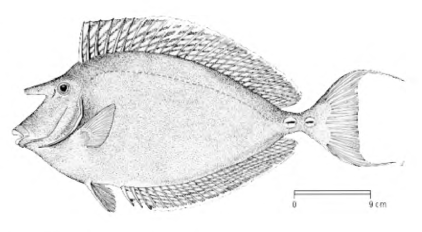

**Figure 2.25:** *Naso unicornis*, long-snouted unicornfish

All Acanthuridae are herbivorous coral reef fish, scraping algae with their fine teeth. Genera include *Naso*, *Acanthurus*, *Zebrasoma* and *Ctenochaetus*. They have thick leathery skin and a spine with one or more knife-like barbs on the tail which are capable of severe wounding. Surgeonfish are so named because of these lancetlike spines, unicorn fish because of the horn-like projection on the forehead. Juveniles differ greatly and are usually separately named in vernacular nomenclatures (Munro 1967: p.482). More POc reconstructions have been made for Acanthuridae than for any other family. Three refer to the genus Naso ‘unicornfish’, but only one, *qume, clearly refers to a single species, *Naso unicornis*.

| **PMP** |  | *qumay | ‘unicorn fish, *Naso* spp.’ (ACD) |
| --- | --- | --- | --- |
| **POc** |  | *qume | ‘*Naso unicornis*, long-snouted unicornfish’ |
| PT | Hula | *ɣume* | ‘*Naso unicornis*’ |
| SES | Kwaio | *ume* | ‘*Aluterus* sp. (prob. *Aluterus monoceros*, the unicorn leatherjacket)’ |
| SES | To’aba’ita | *umea* | ‘*Naso unicornis*’ |
| SES | Langalanga | *ume* | ‘*Naso unicornis*’ |
| SES | Lau | *ʔume* | ‘k.o. black flattish fish, good eating’ |
| SES | Ulawa | *ume (totoro)* | ‘*Naso unicornis*’ (*totoro* ‘crest’) |
| SES | Arosi | *ume* | ‘*Naso unicornis*’ |
| NCV | Mota | *ume* | ‘large fish with a lump on the forehead’ |
| NCV | Vera’a | *ʊm* | ‘*Naso tuberosus*’ (hump-nosed unicornfish) |
| NCV | Lewo | *me* | ‘unicorn fish’ |
| Mic | Woleaian | *xium* | ‘k.o. fish with long snout’ |
| Mic | Sonsorolese | *gume* | ‘*Naso unicornis*’ |
| Mic | Satawalese | *kim* | ‘*Naso unicornis*’ |
| **PPn** |  | *qume | ‘*Naso* sp., unicornfish’ (Hooper 1994) |
| Pn | Tongan | *ʔume* | ‘*Naso unicornis*’ |
| Pn | Niuatoputapu | *ʔume* | ‘*Naso* spp.’ |
| Pn | Samoan | *ume* | ‘name given to mature fishes of the genus *Naso* when about 30 cm long and over’ (*ume-lei* ‘*Naso* when about 15 cm long’) |
| Pn | Rennellese | *ʔume* | ‘k.o. large fish, similar to *punoŋi*, perhaps a unicorn fish or parrot fish’ |
| Pn | Rennellese | *ʔume (kan)* | ‘a unicorn fish’ (*kanu* ‘patterned’) |
| Pn | Rarotongan | *ume* | ‘fish sp., leather-jacket’ |
| Pn | Tikopia | *ume* | ‘*Naso unicornis*’ |

cf. also:

| PT | Kilivila | *gum* | ‘k.o. fish’ (*g-* for †*k*) |
| --- | --- | --- | --- |

In the next set, PNPn languages have added reflexes of PPn *tifi ‘tip, point, extremity’ to the reflex of POc *taRat.

| **PMP** |  | *taRat | ‘Naso spp., unicornfish’ |
| --- | --- | --- | --- |
| **POc** |  | *taRat | ‘Naso spp., incl. *Naso brevirostris*, short snouted unicornfish’ |
| NNG | Lukep | *tare* | ‘tang’ |
| PT | Gumawana | *(ia) tala* | ‘*Naso brevirostris*, short snouted unicorn fish’ |
| PT | Lala | *(iʔa) laka* | ‘k.o. fish’ (metathesis) |
| PT | Motu | *tara* | ‘k.o. fish’ |
| MM | Marovo | *tarasi* | ‘generic for several species of large surgeonfish’ (for †*tarata*) |
| **PCP** |  | *tā | ‘*Naso* sp.’ (Geraghty 1994) |
| Fij | Bauan | *tā* | ‘leatherjacket or unicorn fish’ |
| Fij | Wayan | *tā(tovu)* | ‘*Naso tuberosus*, humpnose unicorn fish’ |
| Pn | Tokelauan | *tā(tifi)* | ‘unicorn fish’ |
| Pn | Tikopia | *tā(tivi)* | ‘*Naso unicornis*’ |
| Pn | Tahitian | *ta(tihi)* | ‘*Naso brevirostris*, short-nosed unicorn fish’ |

| **POc** |  | *m(a,o)nuRV | ‘*Naso* sp., unicornfish’ |
| --- | --- | --- | --- |
| Adm | Titan | *mʷanoi* | ‘*Naso unicornis*, long-snouted unicornfish’ |
| Adm | Lenkau | *manoi* | ‘unicornfish’ |
| Adm | Loniu | *monoy* | ‘*Naso unicornis*’ |
| Adm | Mussau | *manoi* | ‘unicornfish’ |
| NNG | Bing | *manur* | ‘*Naso lituratus*, poll unicornfish’ (Also known as stripe-face or orange-spine unicornfish) |
| Mic | Satawalese | *mono* | ‘k.o. surgeonfish, *Naso* sp.’ |
| Pn | Pukapukan | *maono* | ‘*Acanthurus guttatus*, white-spotted surgeonfish’ (*o* unexpected) |

A number of terms for surgeonfish have been reconstructed. The following reconstruction, POc *piRa(q), is identical in form with the term for *Alocasia*, swamp taro, which, like *Zebrasoma veliferum*, is unpalatably acid unless the skin is carefully removed (Geraghty 1990:78). A parallel development is found in Rotuman, where *ʔapea* means both ‘swamp taro’ and ‘sailfin tang’.

| **PMP** |  | *biRaq | ‘*Zebrasoma veliferum*’ (also ‘*Alocasia*, wild taro’) (Blust 2002) |
| --- | --- | --- | --- |
| **POc** |  | *piRa(q) | ‘*Zebrasoma veliferum*, sailfin tang’ |
| Adm | Titan | *pa-pai* | ‘*Acanthurus* spp.’ (metathesis) |
| MM | Maringe | *(baba)fra* | ‘k.o. surgeonfish’ |
| SES | Gela | *(iga) vila* | ‘*Zebrasoma veliferum*, sailfin tang’ |
| NCV | Lewo | *piya(ewa)* | ‘fish with tough skin, sharp tail’ |
| **PFij** |  | *via | ‘*Zebrasoma veliferum*’ (Geraghty 1994) |
| Fij | Bauan | *via* | ‘k.o. fish, broad with large breast fins’ |

| **POc** |  | *bi[r,R]apa | ‘*Acanthurus lineatus*, blue-lined surgeonfish’ |
| --- | --- | --- | --- |
| PT | Kilivila | *bilawa-wa* | ‘k.o. fish’ |
| MM | Nehan | *berau* | ‘*Acanthurus triostegus*, convict surgeonfish’ |
| MM | Nduke | *be-bera* | ‘*Acanthurus lineatus*, blue-lined surgeonfish’ |
| SES | To’aba’ita | *belafa* | ‘*Acanthurus lineatus*’ |
| SES | Longgu | *belava* | ‘*Acanthurus lineatus*’ |
| SES | Arosi | *biraha* | ‘*Acanthurus lineatus*’ |
| NCV | Dorig | *brav* | ‘*Acanthurus lineatus*’ |
| NCV | Lakon | *pirav* | ‘*Acanthurus lineatus*’ |
| Mic | Satawalese | *parapar* | ‘*Acanthurus guttatus*’ (white-spotted surgeonfish) |
| Fij | Rotuman | *poraha* | ‘k.o. fish with sting in its tail, longitudinal yellow and blue stripes, *Acanthurus lineatus*’ |

| **POc** |  | *maRa | ‘*Acanthurus* sp., possibly *Acanthurus xanthopterus*, yellowfin surgeonfish’ |
| --- | --- | --- | --- |
| Adm | Andra | *ma* | ‘*Acanthurus xanthopterus*’ |
| Adm | Loniu | *may* | ‘surgeonfish or similar poison-spined fish’ |
| NNG | Mutu | *mara* | ‘*Acanthurus xanthopterus*’ |
| Pn | Pukapukan | *mā* | ‘*Ctenochaetus striatus*, bristle-toothed surgeon-fish’ |
| Pn | Tikopia | *ma* | ‘*Acanthurus bleekeri*, dark colour, about 30 cm.’ |

cf. also:

| PT | Kilivila | *mawa* | ‘*Acanthurus xanthopterus*’ |
| --- | --- | --- | --- |

| **PMP** |  | *katawan | ‘fish sp.’ (ACD) |
| --- | --- | --- | --- |
| **POc** |  | *katawan | ‘*Acanthurus* taxon, surgeonfish’ |
| PT | Misima | *tayan* | ‘*Acanthurus dussumieri*, ornate surgeonfish’ |
| SES | Arosi | *ʔāwa* | ‘fish sp.’ |
| Mic | Kiribati | *katāwa* | ‘*Acanthurus lineatus*, bluebanned surgeonfish’ |

| **PMP** |  | *paliR | ‘surgeonfish’ (Blust 2002: PWMP) |
| --- | --- | --- | --- |
| **POc** |  | *[qa]paliR | ‘*Acanthurus*, surgeonfish’ |
| PT | Misima | *havani* | ‘*Acanthurus nigricauda*, blackstreak surgeonfish’ (initial *h-* for †∅) |
| MM | Marovo | *valiri* | ‘generic for several medium sized dark surgeonfish’ |
| TM | Buma | *waviliro* | ‘*Acanthurus lineatus*, lined surgeonfish’ |
| **PCP** |  | *qavali | ‘*Acanthurus* sp.’ (Geraghty 1994) |
| Fij | Rotuman | *alahi* | ‘*Acanthurus* sp.’ (metathesis) |
| Pn | Niuatoputapu | *ʔafali* | ‘*Acanthurus blochii*’ |
| Pn | Rennellese | *ʔahaŋgi* | ‘*Acanthurus* sp.’ |

cf. also:

| Fij | Wayan | *bali-bali* | ‘possibly *Acanthurus lineatus*’ |
| --- | --- | --- | --- |

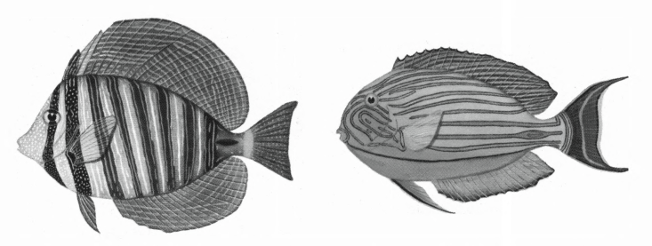

**Figure 2.26:** **Left** *Zebrasoma veliferum*, sailfin tang. **Right** *Acanthurus lineatus*, blue-lined surgeonfish.

| **POc** |  | *[s,j]abiŋ | ‘*Acanthurus* spp., incl. *Acanthurus guttatus*, white-spotted surgeonfish’ |
| --- | --- | --- | --- |
| Adm | Loniu | *capaŋ* | ‘possible tang or surgeonfish’ |
| Mic | Kiribati | *riba* | ‘*Acanthurus*, surgeonfish generic’ (vowel metathesis) |
| **PCP** |  | *(s,ð)abi | ‘*Acanthurus guttatus*, spotted surgeonfish’ (Geraghty 1994) |
| Fij | Lau (Eastern Fijian) | *sabi* | ‘*Acanthurus guttatus*’ |
| **PPn** |  | *hapi | ‘*Acanthurus guttatus*’ (Hooper 1994) |
| Pn | Tongan | *hapi* | ‘k.o. fish’ |
| Pn | Niuean | *hapi* | ‘*Acanthurus guttatus*, surf surgeonfish’ |
| Pn | Niuatoputapu | *hapi* | ‘*Acanthurus guttatus*’ |
| Pn | Rennellese | *api* | ‘some species of surgeonfishes’ |
| Pn | Tokelauan | *api* | ‘surgeonfish’ |
| Pn | Tikopia | *api* | ‘surgeonfish’ |

The transfer of meaning in Micronesian languages in the next set is unexplained.

| **PMP** |  | *qaroŋo | ‘*Acanthurus* spp.’[^31] |
| --- | --- | --- | --- |
| **POc** |  | *qaroŋo | ‘surgeonfish, *Acanthurus* sp.’ |
| Adm | Titan | *kaloŋ* | ‘*Ctenochaetus striatus*, orange-dotted hair-tooth surgeonfish’ |
| NNG | Takia | *aroŋ* | ‘*Acanthurus bleekeri*, yellowmask surgeon-fish’ |
| SV | Anejom̃ | *n-araŋ* | ‘*Acanthurus gahhm*’ (black surgeonfish) |
| **PMic** |  | *aroŋo | ‘*Carangid* fish, pompano, skipjack’ (Bender et al. 2003) |
| Mic | Kiribati | *(te)aoŋo* | ‘a jackfish’ |
| Mic | Chuukese | *aroŋ* | ‘k.o. fish’ |
| Mic | Carolinian | *aroŋ* | ‘fourth of five growth stages of the skipjack’ |
| Mic | Ponapean | *ɔroŋ* | ‘bluejack crevally’ |
| **PPn** |  | *qaloŋo | ‘*Acanthurus* sp., probably *Acanthurus lineatus*, blue-lined surgeonfish’ (Hooper 1994) |
| Pn | Tongan | *ʔaloŋo* | ‘*Acanthurus lineatus*’ |
| Pn | East Uvean | *ʔaloŋo* | ‘*Acanthurus lineatus*’ |
| Pn | Rennellese | *ʔagoŋo* | ‘surgeonfish, probably *Acanthurus lineatus*’ |
| Pn | Niuatoputapu | *aloŋo* | ‘surgeonfish’ |
| Pn | Samoan | *aloŋo* | ‘*Acanthurus*, when full grown’ |
| Pn | Tikopia | *aroŋo* | ‘*Acanthurus lineatus*’ |

| **POc** |  | *kir[i,au] | ‘Acanthuridae’ |
| --- | --- | --- | --- |
| Adm | Andra | *kirau* | ‘surgeonfish’ |
| NNG | Tami | *gilau* | ‘*Acanthurus bleekeri*, k.o. surgeonfish’ (*g-* for expected *k-*) |
| NNG | Bing | *kir* | ‘surgeonfish’ |
| NNG | Kove | *kiri* | ‘fish, unicornfish?’ |
| MM | Patpatar | *kilo* | ‘surgeonfish’ (*-l-* for †*-r-*) |
| Pn | Samoan | *ʔili(ū)* | ‘name of certain fishes of genera *Zebrasoma* and *Acanthurus*, the skin of which is said to be poisonous’ |
| Pn | Samoan | *ʔili-ʔilia* | ‘name of fishes of genus Naso when about 5 cm long’ |
| Pn | Kapingamarangi | *kili(ū)* | ‘*Zebrasoma* sp., tang’ |

The Loniu (Adm) reflex *(ña)pon* below could reflect either POc *bolo or *bone. Both reconstructions refer to small, dark Acanthuridae.

| **POc** |  | *bolo | ‘small dark surgeonfish, possibly *Ctenochaetus*’ |
| --- | --- | --- | --- |
| Adm | Loniu | *(ña)pon* | ‘surgeonfish’ |
| MM | Nehan | *bo-bol* | ‘*Acanthurus* sp., tang’ |
| SES | Gela | *bolo-bolo* | ‘*Ctenochaetus binotatus*, twospot bristletooth’ (a small dark fish) |
| SES | Lau | *bolo* | ‘k.o. small black surgeonfish’ |
| SES | Arosi | *boro (i asi)* | ‘k.o. fish’ |
| NCV | Mwotlap | *no-pʷol* | ‘*Acanthurus olivaceus*, surgeonfish with white band on tail’ |
| NCV | Mwotlap | *pʷol-pʷol* | ‘*Acanthurus leucopareius*?, smaller than *pʷol*’ |
| NCV | Vera’a | *pʷʊl* | ‘*Ctenochaetus striatus*, lined bristletooth’ |
| Fij | Rotuman | *polo* | ‘young blackfish’ |
| Pn | Rennellese | *pogo* | ‘some kinds of surgeonfish and tangs’ |

| **PEOc** |  | *bon(e,a) | ‘generic for various small Acanthuridae’ |
| --- | --- | --- | --- |
| SES | Gela | *bo-bona* | ‘generic for various spp. incl. *Acanthurus nigrofuscus* (dusky surgeonfish), *Ctenochaetus striatus* (lined bristletooth) and *Zebrasoma scopas* (blue-lined tang)’ |
| Fij | Lau (Eastern Fijian) | *pone* | ‘*Acanthurus nigrofuscus*’ |
| **PPn** |  | *pone | ‘*Acanthurus* sp. or *Ctenochaetus striatus*’ (Hooper 1994) |
| Pn | Tongan | *pone* | ‘k.o. fish, small, black, nearly circular; *Ctenochaetus striatus* and *Acanthurus* sp.’ |
| Pn | East Uvean | *pone* | ‘generic for some *Acanthurus* spp.’ |
| Pn | Samoan | *pone* | ‘*Acanthurus* spp. when about 15 cm long’ |
| Pn | Tikopia | *pone* | ‘*Acanthurus* spp., dark-coloured, said by Tikopia to be younger growth stage of ma (*Acanthurus mata*)’ |
| Pn | Tokelauan | *pone* | ‘name given to *Ctenochaetus striatus* (aloŋo) when it forms schools at spawning season’ |

cf. also:

| Pn | Rennellese | *ponoŋi* | ‘general name for unicornfish’ |
| --- | --- | --- | --- |

| **POc** |  | *ma(k,q)eto | ‘a dark fish, possibly *Ctenochaetus striatus*’ (POc *maqeto(m) ‘black’; cf. vol.2, p.206) |
| --- | --- | --- | --- |
| MM | Lihir | *(mats)maket* | ‘*Ctenochaetus striatus*’ |
| MM | Bola | *meto* | ‘k.o. fish’ (for †*maɣeto*) |
| SES | Lau | *mae(iʔa)* | ‘k.o. fish’ |
| SES | ’Are’are | *make* | ‘black’ |
| SES | Arosi | *maeo* | ‘black’ |
| NCV | Uripiv | *(ni)met* | ‘*Acanthurus blochii*’ |
| NCV | Paamese | *na-meto* | ‘k.o. black fish’ |
| Fij | Rotuman | *vaefa* | ‘*Acanthurus triostegus*’ (*v-* < POc *mʷ-)[^32] |
| **PPn** |  | *maqito | ‘Acanthuridae, possibly *Ctenochaetus striatus*, lined bristletooth’ (Hooper 1994) |
| Pn | Niuean | *meito* | ‘*Acanthurus xanthopterus*, yellowfin surgeonfish, edible’ |
| Pn | East Uvean | *maʔito* | ‘*Ctenochaetus striatus*’ |
| Pn | Pukapukan | *maito* | ‘*Ctenochaetus hawaiiensis*’ |
| Pn | Rennellese | *maʔito* | ‘*Acanthurus* sp.’ |
| Pn | Tahitian | *maito* | ‘*Ctenochaetus striatus*’ |
| Pn | Rapa | *maito* | ‘*Ctenochaetus striatus*, *Acanthurus nigrofuscus*’ |

cf. also:

| Mic | Kiribati | *mako* | ‘*Acanthurus xanthopterus*’ |
| --- | --- | --- | --- |

| **POc** |  | *bala(ŋ,k)i | ‘*Acanthurus* spp. and *Naso* spp.’ |
| --- | --- | --- | --- |
| Adm | Mussau | *balai* | ‘k.o. fish’ |
| NNG | Gedaged | *balai* | ‘fish about 60 cm long, red color’ |
| PT | Motu | *bai* | ‘fish sp.’ |
| SES | Lau | *balaʔi* | ‘*Epinephelus areolatus*, yellow-spotted rock cod’ |
| NCV | Namakir | *paraŋ* | ‘k.o. surgeonfish’ |
| Mic | Mokilese | *pʷilak* | ‘unicorn fish’ |
| Mic | Marshallese | *pɯilak* | ‘*Naso lituratus* (poll unicornfish)’ |
| Mic | Ponapean | *pʷulak* | ‘*Naso unicornis*’ |
| Mic | Kiribati | *pʷāpʷā* | ‘*Acanthurus guttatus*, spotted surgeonfish’ |
| **PCP** |  | *balaŋi | ‘*Acanthurus* spp.’ (Geraghty 1994) |
| Fij | Bauan | *balaŋi* | ‘*Teuthis* sp.’ (spinefoot sp.) |
| Fij | Wayan | *balaŋi* | ‘generic for *Acanthurus* spp., surgeonfish, tangs and unicorns’ |
| Fij | Kadavu | *balaŋi* | ‘*Acanthurus* spp. and *Naso* spp.’ |
| **PPn** |  | *palaŋi | ‘*Acanthurus* sp. of large size and elongate shape’ (Hooper 1994) |
| Pn | Tongan | *palaŋi* | ‘k.o. fish’ |
| Pn | Samoan | *palaŋi* | ‘name given to certain fishes of the genus *Acanthurus* (surgeon fishes) when about 30 cm long’ |
| Pn | Rennellese | *pagaŋi* | ‘k.o. surgeonfish, perhaps ring-tail surgeonfish: *Acanthurus xanthopterus*’ |
| Pn | Kapingamarangi | *palaŋi* | ‘*Acanthurus xanthopterus*, black-barred surgeonfish’ |
| Pn | Tikopia | *paraŋi* | ‘surgeonfish’ |
| Pn | Tahitian | *paraʔi* | ‘*Acanthurus xanthopterus*’ |
| Pn | Hawaiian | *palani* | ‘*Acanthurus dussumieri*, a surgeonfish famous for a strong odor’ |

cf. also:

| NNG | Kove | *balaŋu-ŋu* | ‘large fish’ (*b-* for †*v-*) |
| --- | --- | --- | --- |
| NNG | Manam | *bela-bela* | ‘*Naso lituratus*, poll unicorn fish’ |
| MM | Nehan | *lake-lak* | ‘*Naso lituratus*’ (no /k/ in Nehan?) |

| **PROc** |  | *manini | ‘*Acanthurus triostegus*, convict tang’ |
| --- | --- | --- | --- |
| NCV | Raga | *manini* | ‘*Acanthurus* spp. incl. *Acanthurus triostegus*’ |
| NCV | Namakir | *manin* | ‘k.o. surgeonfish’ |
| Fij | Lau (Eastern Fijian) | *manini* | ‘*Acanthurus triostegus*’ |
| Pn | Tongan | *manini* | ‘*Acanthurus triostegus*’ |
| Pn | East Futunan | *manini* | ‘*Acanthurus triostegus*’ |
| Pn | Samoan | *manini* | ‘*Acanthurus triostegus*’ |
| Pn | Tikopia | *manini* | ‘*Acanthurus triostegus*’ |
| Pn | Tahitian | *manini* | ‘*Acanthurus triostegus*’ |

Geraghty (1994: pp. 161-162) adds further PCP reconstructions: PCP *tusi ‘*Acanthurus* sp.’ (PPn *tusi ‘mark, stripe’); *masa ‘a small dark Acanthuridae, possibly *Zebrasoma scopas*. blue-lined tang or *Acanthurus pyroferus*, mimic surgeonfish’ and *ma(c,s)i-ma(c,s)i) ‘*Naso* sp.’.

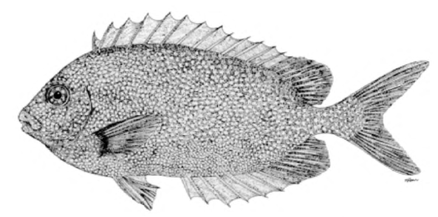

**Figure 2.27:** *Siganus punctatus*, gold-spotted spinefoot

## 55. Rabbitfishes, spinefeet (Siganidae)

Rabbitfish or spinefeet are herbivorous fish, inhabiting grassy shallow waters. Their fin spines are very sharp and can inflict painful stings. They have characteristic rabbit-shaped heads. Their flesh is edible. Oceanic languages usually distinguish several taxa. Two Polynesian terms in the next set refer instead to Epinephelidae which resemble the Siganidae in having dangerous spines.

| **PMP** |  | *kiteŋ | ‘rabbitfish’ (Blust 2002) |
| --- | --- | --- | --- |
| **POc** |  | *kitoŋ | ‘*Siganus* sp., possibly *Siganus punctatus*, gold-spotted spinefoot’ |
| PT | Kilivila | *kitiga* | ‘*Siganus chrysospilos*’ |
| PT | Misima | *kiton* | ‘*Siganus punctatus*, *Siganus lineatus*’ |
| MM | Teop | *sitono* | ‘*Siganus fuscescens*, mottled spinefoot’ (< *titoŋ) |
| MM | Marovo | *itoŋo* | ‘rabbitfish, possibly *Siganus corallinus*’ (ocellated orange spinefoot) |
| MM | Marovo | *it-itoŋo* | ‘spotted spinefoot, poss. *Siganus stellatus*’ |
| NCV | Mwotlap | *ɣıt* | ‘*Siganus doliatus*’ |
| Fij | Rotuman | *kifo* | ‘*Siganus rostratus*’ (rabbit-faced spinefoot) |
| Fij | Wayan | *kito* | ‘prob. *Siganus chrysospilos* [Siganus punctatus], black fish with orange spots’ |
| **PPn** |  | *kito | ‘*Epinephelus* spp.’ |
| Pn | Samoan | *tito* | ‘*Siganus punctatus*’ (< *titoŋ?) |
| Pn | Tuamotuan | *kito* | ‘*Epinephelus microdon* [camouflage grouper]’ |
| Pn | Rapa | *kito* | ‘*Epinephelus tuamotuensis*’ (reticulate grouper) |

cf. also:

| NCV | Southwest Bay | *n-ataŋ* | ‘rabbitfish’ (John Lynch, pers. comm.) |
| --- | --- | --- | --- |

| **PMP** |  | *muquŋ | ‘k.o. fish’ (ACD) |
| --- | --- | --- | --- |
| **POc** |  | *muqu(ŋ) | ‘Siganus taxon, poss. *Siganus spinus*’ |
| Adm | Loniu | *mu* | ‘*Siganus spinus*, pearl-spotted spinefoot’ |
| NNG | Gedaged | *mu* | ‘marine fish about 30 cm long, front part yellowish brown, shading off to yellowish toward the rear’ |
| NNG | Bukawa | *(i)-mbuʔ* | ‘k.o. spinefoot’ |
| NNG | Yabem | *(i)-muʔ* | ‘k.o. spinefoot’ |
| PT | Bunama | *mu-mu(ya)* | ‘k.o. spinefoot’ |
| PT | Misima | *mu-mu(ya)* | ‘*Siganus canaliculatus*, smudgepot spinefoot’ |
| PT | Motu | *mi-mi* | ‘*Siganus spinus*’ |
| MM | Vitu | *muɣu* | ‘rabbitfish’ |
| SES | Lau | *mū* | ‘k.o. white reef fish, good eating; spinefoot’ |
| SES | Langalanga | *mu* | ‘black spinefoot’ |

| **POc** |  | *roRo | ‘growth stage of *Siganus* spp.’ |
| --- | --- | --- | --- |
| Adm | Andra | *dro(ŋ)* | ‘*Siganus rostratus*, *Siganus argenteus*’ (*Siganus rostratus* is a junior synonym of *Siganus argenteus*) |
| **PCP** |  | *rō | ‘juvenile Siganus’ (Geraghty 1994) |
| Fij | Rotuman | *rō* | ‘small silvery fish’ (poss. loan from Samoan) |
| **PPn** |  | *rō | ‘*Siganus* sp.’ (Hooper 1994 has *ō ‘tuna baitfish, such as fry of *Siganus* spp. or *Caesio* spp.’; pp.192, 227) |
| Pn | Tongan | *ō* | ‘*Siganus vermiculatus*’ |
| Pn | Niuatoputapu | *ō* | ‘growth stage of Siganus’ |
| Pn | Samoan | *lō* | ‘*Siganus* sp.’ |
| Pn | Tokelauan | *lō(tala)* | ‘fry of *Siganus*’ |

cf. also:

| Pn | East Uvean | *ō* | ‘*Siganus* sp.’ (expect *lō*) |
| --- | --- | --- | --- |
| Pn | Tikopia | *ō* | ‘*Siganus rostratus* [Siganus argenteus], *Siganus punctatus*, spotted rabbitfish’ (expect *rō*) |
| Pn | Tokelauan | *ō* | ‘tiny fish which form dense, spherical schools outside the reef during dark phases of the moon’(Hooper 1994: p.192) |

The Admiralties languages below reflect *pajal(a), and it is possible that the POc form was *pajala, not *palaja.

| **POc** |  | *palaja | ‘*Siganus* spp., rabbitfish’ (ACD: POc *(p,b)ala-(p,b)ala ‘fish sp.’) |
| --- | --- | --- | --- |
| Adm | Penchal | *pacal* | ‘rabbitfish’ (metathesis) |
| Adm | Titan | *pacal* | ‘spinefoot (generic), Siganidae’ (metathesis) |
| Adm | Lou | *posowe* | ‘rabbitfish’ (*-w-* for †*-l-*) |
| MM | Lihir | *plats* | ‘*Siganus lineatus*, *Siganus guttatus*, *Siganus corallinus*’ |
| MM | Tolai | *pala-pala* | ‘fish sp.’ |
| SES | Lau | *falata* | ‘*Siganus* sp.’ (Akimichi 1978) |
| SES | Arosi | *harata* | ‘k.o. fish’ |
| SES | Kahua | *farata* | ‘*Siganus rostratus*’ |
| NCV | Vera’a | *basara* | ‘*Siganus canaliculatus*’ (metathesis) |
| NCV | South Efate | *fser* | ‘forktail rabbitfish (*Siganus argenteus*)’ (metathesis) |
| Mic | Ponapean | *pala-pal* | ‘*Siganus punctatus*’ (gold-spotted spinefoot) |
| Fij | Wayan | *volaða* | ‘*Siganus lineatus*’ (golden-lined spinefoot) |

| **POc** |  | *muroR | ‘*Siganus argenteus*, silver or rabbit-faced spinefoot’ |
| --- | --- | --- | --- |
| Adm | Nali | *mʷilou* | ‘*Siganus*, rabbit-faced spinefoot’ |
| Adm | Andra | *muleo* | ‘*Siganus javus*, rabbitfish’ |
| Adm | Lenkau | *mulow* | ‘rabbit-faced spinefoot, *Siganus*’ (*-l-* for †*-r-*) |
| MM | Nehan | *mur* | ‘spinefoot, rabbitfish’ |
| MM | Maringe | *morora* | ‘rabbit fish with yellow colouring’ |
| Pn | Rarotongan | *muro* | ‘k.o. fish caught at night with hand net’ (Buck) |

| **POc** |  | *marawa | ‘spinefoot sp.’ |
| --- | --- | --- | --- |
| NNG | Kove | *malava* | ‘k.o. fish’ |
| PT | Motu | *maraua* | ‘k.o. fish’ |
| Mic | Mokilese | *mār* | ‘k.o. spinefoot’ |
| Mic | Ponapean | *mār* | ‘*Siganus puellus*’ (blue-lined spinefoot) |
| **PPn** |  | *marawa | ‘rabbitfish, *Siganus rostratus*’ |
| Pn | Rennellese | *maŋgau* | ‘general name for some squirrelfish’ |
| Pn | Samoan | *mālava* | ‘k.o. fish’ |
| Pn | Pukapukan | *mālava* | ‘*Siganus rostratus*’ |
| Pn | Rarotongan | *marava* | ‘*Siganus rostratus*’ |
| Pn | Tokelauan | *malava* | ‘*Siganus rostratus*’ |
| Pn | Tahitian | *marava* | ‘*Siganus rostratus*’ |
| Pn | Marquesan | *maʔava* | ‘*Siganus argenteus*’ |

Two terms similar in form to *marawa, PCP/PPn *maqawa ‘*Siganus rostratus*’ and PPn *paqaua ‘*Siganus spinus*’, have also been reconstructed (Geraghty 1994: pp. 163-164).

## 56. Snake mackerels, oilfishes (Gempylidae)

Snake mackerels (*Gempylus serpens*, *Promethichthys prometheus*, *Ruvettus pretiosus*) inhabit deeper coastal and oceanic waters, and are sometimes found at depths as great as 600 metres. The flesh is edible but oily. Davis (1999: 164) writes that *Ruvettus pretiosus* is so oily that eating even a small amount of its flesh has a strongly laxative effect. In some parts of Polynesia *Ruvettus pretiosus* is known by reflexes of PPn *palu, whose range of reference may also include jobfish and other deep-sea snappers. Both oilfish and deep-sea snappers are found at great depths (§30). As mentioned earlier (p.78), the ability to fish water at these depths was probably a late Samoic-Outlier innovation. Some local terminologies group snake mackerels with barracudas, also elongated and slender with powerful dentition. In places they may also be identified with catfish (Pukapukan and Tokelauan *kapoa* ‘*Promethichthys prometheus*’ > POc *kaboRa ‘catfish’). *Promethichthys prometheus* has also been known as Bermuda catfish. Hooper has reconstructed PPn *maŋā ‘k.o. fish’ with meaning in Eastern Polynesian languages ‘*Promethichthys prometheus*, snake mackerel’.

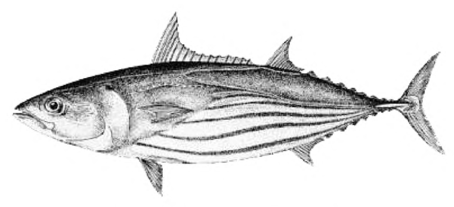

**Figure 2.28:** *Katsuwonus pelamis*, skipjack tuna

## 57. Skipjacks, Spanish mackerels, mackerels, tunas, tunnies, albacores, wahoos (Scombridae)

Munro recognised distinct families: Katsuwonidae (skipjack and dogtooth tuna), Scombero-moridae (Spanish mackerel), Scombridae (mackerel), Thunnidae (albacore, tunnies, big eye, bluefin and yellowfin tuna), and Acanthocybidae (wahoo), but these have now been combined as one family, Scombridae (Kailola (1987-1991:467, FishBase). These fish are mostly large, fast surface predators, highly regarded both for food and sport. There is considerable variation in English glosses within cognate sets, due possibly to variable popular usage of terms like tuna, bonito, tunny and mackerel by wordlist compilers. In particular, although the English vernacular term bonito typically refers to *Katsuwonus pelamis* (skipjack), it is sometimes extended to include any pelagic fish caught by trolling from fast canoes, including *Katsuwonus*, *Gymnosarda* and *Thunnus*. Reflexes of POc *qatun may be similarly applied in both narrow and extended senses. *Katsuwonus* (skipjacks) and *Gymnosarda* (dogtooth tunas) are generally distinguished from *Thunnus* (true tunas) by the former’s apparently scaleless body. Most skipjacks (bonito) are school fishes, found around the outer edges of reefs where they can be taken by trolling. They travel in large schools offshore along the coast at certain seasons, the schools often boiling at the surface. These fish have a special role in many parts of the Oceanic world. Simbo speakers in the NW Solomons divide fin fishes into three categories: *baɣea* ‘sharks’, *iso* ‘bonito’ and *iɣana* ‘generic for all fish other than sharks and bonito’ (Bill Palmer pers. comm.). Ivens (1927:130) writes that “to the Melanesian of the Southeast Solomons the catching of the bonito is one of the things for which he exists. To him it is the king of fish”. Solomon Islanders incorporate them in initiating ceremonies and associate them with various taboos (1927:130-131, 314, 329-330). Many different names are used for bonito in particular roles, a reflection of their importance in these communities. In similar vein, bonito fishing in Kapingamarangi is described by local fishermen as “their sport of kings” (Lieber 1994:77). In Tonga also, the bonito is considered the king of fish (Dye 1983:251-2).

[output not shown]

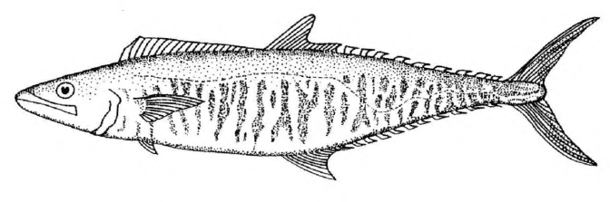

**Figure 2.29:** *Scomberomorus commerson*, Spanish mackerel

Blust (2002:130) notes that Tagalog is the only non-Oceanic language known to have a presumptive cognate, *atun* ‘tunny fish’, albeit with an unexpected high vowel, and concludes that ‘*qatun probably was a lexical innovation in POc and that the early Spanish explorers in the Pacific borrowed the term from an Oceanic language (most likely in the western Solomon Islands) that preserved final consonants, and then introduced it into the Philippines’.

| **PROc** |  | *tawa-tawa | ‘growth stage of skipjack or dogtooth tuna’ |
| --- | --- | --- | --- |
| Mic | Kiribati | *tawa-tawa* | ‘*Euthynnus affinis*, mackerel tuna’ |
| Mic | Puluwatese | *yawo(rɔpʷ)* | ‘large growth stage of skipjack’ |
| **PPn** |  | *tawa-tawa | ‘*Euthynnus yaito* [Euthynnus affinis], black tuna, or *Gymnosarda unicolor*, juvenile, dogtooth tuna’ (Hooper: PNPn) |
| Pn | Pukapukan | *tava-tava* | ‘*Gymnosarda unicolor*’ |
| Pn | Samoan | *tava-tava* | ‘name given to bonito when about 30cm long’ |
| Pn | Tokelauan | *tava-tava* | ‘*Gymnosarda unicolor* when 40-60 cm’ |
| Pn | Māori | *tawa-tawa* | ‘*Scomber australasicus*’ |
| Pn | Hawaiian | *kawa-kawa* | ‘*Euthynnus yaito*’ |

cf. also:

| Pn | Tongan | *kava-kava* | ‘*Euthynnus yaito*’ (wrong initial) |
| --- | --- | --- | --- |

*Scomberomorus* (Spanish mackerels) are moderate to large predatory fishes occurring in schools in coastal waters. Larger ones are caught by trolling near the surface in the vicinity of coral reefs, rocky headlands and sunken shoals. Flesh is white, sweet, rather boneless and highly esteemed. There are perhaps four species of *Scomberomorus*. The largest, *Scomberomorus commerson*, the narrow-barred Spanish mackerel, has been known to grow to over two metres, although average size is considerably smaller (Munro 1967: p.200). Although the following PMP reconstruction is glossed ‘*Scomberomorus commerson*, Spanish mackerel’, Oceanic cognates do not support a species-specific gloss for POc.

| **PMP** |  | *taŋiRi | ‘*Scomberomorus commerson*, Spanish mackerel’ (ACD) |
| --- | --- | --- | --- |
| **POc** |  | *taŋiRi | ‘*Scombridae* spp., prob. incl. *Scomberomorus commerson*, narrow-barred Spanish mackerel, and *Acanthocybium solandri*, wahoo’ |
| Adm | Mussau | *taŋini* | ‘Spanish mackerel’ (*-n-* by assimilation) |
| Adm | Titan | *taŋini* | ‘*Scomberomorus niphonius*. Spanish mackerel’ (*-n-* by assimilation) |
| NNG | Gedaged | *taŋiḷ* | ‘white marine fish about 75 cm long, like a mackerel’ |
| NNG | Bing | *taŋir* | ‘tuna sp., albacore’ |
| NNG | Gitua | *taŋir* | ‘mackerel, wahoo’ |
| NNG | Mutu | *taŋir* | ‘wahoo, mackerel’ |
| NNG | Bukawa | *(i)daŋi* | ‘k.o. Spanish mackerel’ (*i* ‘fish’) |
| MM | Patpatar | *taŋir* | ‘k.o. fish that leaps from the water’ |
| MM | Lihir | *taŋir* | ‘*Scomberomorus commerson*, *Acanthocybium solandri*, *Grammatorcynus bicarinatus*, Spanish mackerel, wahoo and double-lined mackerel’ |
| MM | Teop | *tanini* | ‘wahoo, barred Spanish mackerel’ |
| MM | Roviana | *taŋiri* | ‘fish generally got by trolling, k.o. kingfish’ |
| MM | Maringe | *taŋiri* | ‘kingfish’ |
| MM | Marovo | *taŋiri* | ‘kingfish’ |
| SES | Arosi | *aŋiri* | ‘shoal of porpoises’ |
| Mic | Kiribati | *tani* | ‘yellowfin tuna’ |
| Mic | Chuukese | *seŋir* | ‘large *Thunnus albacares*, yellowfin tuna’ |
| Mic | Puluwatese | *hœŋir* | ‘yellowfin tuna’ |
| Mic | Woleaian | *taŋiẓi* | ‘king-size tuna’ |
| Mic | Satawalese | *sœŋir* | ‘the largest tuna, *Thunnus* sp.’ |
| Pn | Samoan | *taŋī* | ‘k.o. fish’ |

cf. also:

| MM | Nehan | *taŋili* | ‘striped tuna, skipjack’ (*-l-* for exp. *-r-*) |
| --- | --- | --- | --- |
| MM | Marovo | *ta-taliŋi* | ‘small yellowfin tuna’ (metath.; *-l-* for exp. *-r-*) |
| SES | Gela | *ili* | ‘wahoo’ |
| Pn | Pukapukan | *tani* | ‘*Thunnus alalunga*, Albacore’ |
| Pn | Rennellese | *taŋili* | ‘the large wahoo or jack mackerel’ (probably borrowed from a Solomons language) |

| **POc** |  | *walu | ‘*Scombridae* sp. or spp.’ |
| --- | --- | --- | --- |
| PT | Motu | *vai(na)-vai(na)* | ‘Australian Spanish mackerel’ |
| SES | Gela | *alu* | ‘barracuda’ |
| Mic | Ponapean | *weli-wel* | ‘tuna’ |
| **PCP** |  | *walu | ‘k.o. pelagic fish’ (Geraghty 1994) |
| Fij | Wayan | *walu* | ‘generic for Spanish mackerel and wahoo’ |
| **PPn** |  | *walu | ‘Scombridae’ (Hooper 1994) |
| Pn | Tongan | *valu* | ‘general name for tuna spp.’ (*valu louniu* ‘wahoo’) |
| Pn | Niuean | *valu* | ‘*Gymnosarda unicolor*, dogtooth tuna’ |
| Pn | East Uvean | *valu* | ‘genus *Thunnus* (generic)’ |
| Pn | Tokelauan | *valu* | ‘*Gymnosarda unicolor* when large’ |
| Pn | Kapingamarangi | *walu* | ‘*Gymnosarda* sp., dogtooth tuna’ |
| Pn | Marquesan | *vaʔu* | ‘Scombridae’ |

*Scomber* and *Rastrelliger* (mackerels) are small to moderate pelagic fishes, typically under a metre in length, which migrate in schools and comprise some of the more important food fishes of the world. Munro (p. 197) reports that they inhabit shallow coastal New Guinea waters where they are caught by seines or fixed traps.

| **POc** |  | *jalala | ‘*Rastrelliger*, k.o. small mackerel’ |
| --- | --- | --- | --- |
| NNG | Bing | *dalāl* | ‘tuna-mackerel family, small’ |
| PT | Roro | *rae* | ‘k.o. fish’ |
| PT | Motu | *dae* | ‘*Scomber* or *Rastrelliger* spp.’ |
| SES | ’Are’are | *tarara* | ‘k.o. fish’ |
| NCV | Uripiv | *jelel* | ‘*Rastrelliger kanagurta*’ |
| NCV | Neve’ei | *(ni)silal* | ‘*Rastrelliger*’ |
| **PCP** |  | *salala | ‘*Rastrelliger*’ (Geraghty 1994) |
| Fij | Bauan | *salala* | ‘mackerel’ |
| Fij | Wayan | *salala* | ‘small grey schooling fish, prob. *Rastrelliger* sp.’ |
| Pn | Tuvalu | *salala* | ‘*Decapterus pinnulatus*, mackerel scad’ |

cf. also:

| PT | Misima | *dayaya* | ‘*Rastrelliger kanagurta*, long-jawed mackerel’ |
| --- | --- | --- | --- |

*Thunnus* (bluefin and northern bluefin tuna, yellowfin tuna, albacore, bigeye tuna) are heavy-bodied pelagic school fish. Most belong to deeper waters, but some inhabit the sea over the continental shelf and may be taken by trolling around reefs. Flesh, usually dark, is excellent, one species dubbed ‘chicken of the sea’ (Munro 1967: p.200).

| **POc** |  | *taku(a,o) | ‘*Thunnus albacares*, yellowfin tuna’ |
| --- | --- | --- | --- |
| Adm | Titan | *drou* | ‘*Thunnus* sp., tuna’ |
| Adm | Nali | *drou* | ‘*Thunnus albacares*, yellowfin tuna’ |
| Mic | Chuukese | *toku* | ‘*Thunnus albacares*, yellowfin tuna’ |
| Mic | Woleaian | *taxuw* | ‘yellowfin tuna’ |
| **PPn** |  | *taku(a,o) | ‘large tuna or skipjack’ (Hooper 1994) |
| Pn | Niuean | *takua* | ‘skipjack tuna, bonito’ |
| Pn | Tongan | *takuō* | ‘k.o. fish’ |
| Pn | Pukapukan | *takuo* | ‘pelagic fish caught by noosing (obsolete term known from chants)’ |
| Pn | Samoan | *taʔuo* | ‘large bonito’ |
| Pn | Rennellese | *takua* | ‘k.o. very rare porpoise or fish, no longer seen’ |
| Pn | Tokelauan | *takuo* | ‘yellowfin tuna when very large’ |
| Pn | Kapingamarangi | *takua* | ‘*Thunnus albacares*, yellowfin tuna’ |
| Pn | Tikopia | *takua* | ‘*Xiphias gladius*, swordfish; *Makaira indicus*, black marlin’ |

François (2005:499) reconstructs PNCV *rowou ‘bonito, *Thunnus* sp.’. Hooper has PNPn *kakasi ‘*Thunnus albacares*, yellowfin tuna’, possibly related to the Marovo and Roviana terms for bonito, *makasi*. The wahoo, *Acanthocybium solandri*, is the sole member of its genus. It is solitary, pelagic, has fine sweet flesh and is rated a splendid sporting fish. The only reconstruction, PPn *paqala ‘*Acanthocybium solandri*, wahoo’ is from Hooper (p.222). In Wayan and Tongan the term for a wahoo is a taxon of PCP *walu.

## 58. Marlins and sailfishes (Istiophoridae); swordfishes (Xiphiidae)

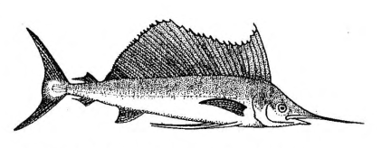

**Figure 2.30:** *Istiophorus platypterus*, Pacific sailfish

The Istiophoridae are identified by an upper jaw in the form of a long sword. They are big-game fish, large, fast and powerful, and pelagic in open waters. Three marlins are recognised, *Makaira indicus* (black marlin), *Makaira mazara* (blue marlin) and *Tetrapturus audax* (striped marlin). The sailfish (*Istiophorus platypterus*) has an extremely elevated dorsal fin forming a sail-like structure which folds into a groove. The swordfish (*Xiphias gladius*) is readily known by its particularly long blade-like rostrum. The adult swordfish differs from the marlin and sailfish in having no scales. The name for the sailfish in PMP and POc, *saku-layaR, is a compound, derived from *saku ‘needlefish, garfish, long toms’ (§13) plus *layaR ‘sail’ (see vol.1,194). Referential range in reflexes often includes swordfishes and marlin as well as sailfishes, although the first two lack the sail-like dorsal fin.

| **PMP** |  | *saku-layaR | ‘sailfish, swordfish’ (ACD) |
| --- | --- | --- | --- |
| **POc** |  | *saku-layaR | ‘sailfish’ |
| Adm | Loniu | *colay* | ‘sailfish, marlin, possibly also swordfish’ |
| Adm | Titan | *colay* | ‘generic for swordfish, marlin’ |
| Mic | Chuukese | *tekulār* | ‘*Makaira* sp., marlins; *Istiophorus* sp., sailfish’ |
| Mic | Mokilese | *tak-lar* | ‘swordfish’ |
| Mic | Puluwatese | *tāki-lār* | ‘sailfish, swordfish’ |
| Mic | Ponapean | *teki-lār* | ‘swordfish, sailfish, blue marlin’ |
| **PCP** |  | *saku-laya | ‘swordfish, sailfish’ (Geraghty 1994) |
| Fij | Bauan | *saku-laya* | ‘the saw-fish proper’ (*saku* swordfish *Makaira* spp.) |
| **PPn** |  | *sakulā | ‘swordfish, sailfish’ (Hooper 1994) |
| Pn | Tongan | *hakulā* | ‘swordfish’ (*haku* ‘young *hakulā*’) |
| Pn | Niuean | *hakulā* | ‘true swordfish’ (compare *hakupin* ‘sailfish’, *haku taŋata* ‘marlin’) |
| Pn | East Uvean | *hakulā* | ‘*Makaira mazara*, blue marlin’ |
| Pn | Samoan | *saʔulā* | ‘name given to sword-fish and saw-fish’ |
| Pn | Tokelauan | *hakulā* | ‘*Xyphias gladius* and other swordfish spp.’ |
| Pn | Tikopia | *sakura* | ‘sailfish’ |
| Pn | Kapingamarangi | *hakulā (tuakua)* | ‘*Makaira* sp., marlin’ |
| Pn | Kapingamarangi | *hakulā-hakulā* | ‘*Istiophorus* sp., sailfish’ |

The following reflect only the first element, *sakw.

| NNG | Wogeo | *sak barema* | ‘sailfish’ |
| --- | --- | --- | --- |
| NNG | Lukep | *sau-rere* | ‘sailfish’ |
| NCV | Paamese | *me-sau koaa sesali* | ‘*Tetrapturus audax*, marlin’ (lit. ‘fish which spears’) |
| SV | Ura | *yayo* | ‘marlin’ |
| Fij | Wayan | *saku vorowaga* | ‘generic incl. most Istiophoridae, marlins and sailfishes’ (*vorowaga* ‘boat-eating’) |
| Fij | Wayan | *saku vorowaga tāŋwane* | ‘blue marlin’ (lit. male boat-eating marlin’) |
| Pn | Hawaiian | *aʔu* | ‘swordfish’ (*aʔu-lepe* ‘sailfish’, *aʔu-kii* ‘marlin’; for `†*haʔu*) |

There is a second term which probably refered to a particular species or subgroup of Istiophoridae in POc. In some languages of the Solomons it has replaced *sakulayaR as the name for the sailfish. This may be a reduplicated form of POc *piRu(q) ‘fan palm’ (vol.3,222), whose fronds resemble the large dorsal fin of the sailfish.

| **POc** |  | *piRu-piRu | ‘Istiophoridae’ |
| --- | --- | --- | --- |
| MM | Nakanai | *vilu-vilu* | ‘sawfish’ |
| MM | Marovo | *viru-viru* | ‘*Istiophorus platypterus*, sailfish’ |
| MM | Roviana | *viru-viru* | ‘k.o. swordfish, smaller than *ikutaina*’ |
| SES | Gela | *vilu-vilu* | ‘swordfish’ |
| SES | Lau | *filu-filu* | ‘*Istiophorus orientalis*, Indo-Pacific sailfish’ |
| SES | ’Are’are | *(ia)hiru* | ‘marlin’ |
| SES | Kwaio | *fī-filu* | ‘blue marlin’ |
| SES | Arosi | *hiru-hiru* | ‘large fish which swims in circles and is the sign of a shark being near’ |
| SES | Longgu | *(koi) vilu-vilu* | ‘sailfish’ |
| SES | Langalanga | *filu-filu* | ‘sailfish’ |
| SES | Owa | *(aiga)firu* | ‘long-bill swordfish, sailfish’ |
| Mic | Kiribati | *ir-iri* | ‘sailfish’ |

## 59. Flounders and soles: left-eye flounders (Bothidae), toothed flounders (Paralichthyidae), right-eye flounders (Pleuronectidae), soles (Soleidae)

Flatfishes are poorly represented in tropical waters in comparison with their abundance in cooler regions. Flounders, toothed flounders and soles are bilaterally asymmetrical, adapted for life on the bottom where they bury themselves in sand or mud. Most inhabit shallow coastal waters and estuaries. Larger ones are good eating (Munro 1967: p.124). Flatheads have a similar habit of burying themselves in sand, but lack the distinctive oval shape of flounders and soles. Many contemporary languages have a generic term for flatfishes. We have two reconstructions, both with generalised gloss. In the next set both POc *alali and *lalali are reflected.

| **PCEMP** |  | *alali | ‘halibut, flounder’[^33] |
| --- | --- | --- | --- |
| **POc** |  | *[l]alali | ‘flatfish incl. flounders, soles’ |
| Adm | Seimat | *alal* | ‘flounder, *Platichthys* spp.’ |
| Adm | Wuvulu | *alali* | ‘flounder, *Platichthys* spp.’ |
| PT | Dobu | *nenai* | ‘flounder, sole’ |
| PT | Kilivila | *(bu)lali* | ‘fish the shape and size of a dinner plate’ (Lawton) |
| MM | Patpatar | *lel* | ‘sole’ |
| MM | Lihir | *lel* | ‘Bothidae, Pleuronectidae and Soleidae, flounders and soles’ |
| MM | Sursurunga | *lal* | ‘left-eye flounder’ |
| MM | Nehan | *lalen* | ‘halibut, flounder, sole’ |
| MM | Halia | *lal* | ‘flounder, halibut’ |
| MM | Marovo | *lali* | ‘generic for flounders’ |
| SES | Owa | *rarari* | ‘a flat fish’ |
| NCV | Mwotlap | *lel* | ‘flat fish’ |
| SV | Anejom̃ | *n-acac* | ‘flatfish, adapted for life on sand’ |
| NCal | Iaai | *nʰen* | ‘*Bothus* sp.’ |
| **PCP** |  | *lalali, *ali | ‘flatfish’ (Geraghty 1994: *(y)ali) |
| Fij | Bauan | *lālali* | ‘large flounder’ |
| **PPn** |  | *ali | ‘*Bothus* spp., flounder’ (Hooper 1994) |
| Pn | Niuean | *ali* | ‘*Bothus* sp., flatfish, flounder’ |
| Pn | Tongan | *ali* | ‘flounder’ |
| Pn | Rennellese | *agi* | ‘general name for flatfishes, flounders, soles etc.’ |
| Pn | Samoan | *ali* | ‘name given to flatfish, esp. some flounders’ |
| Pn | Tokelauan | *ali* | ‘*Bothus* sp., flounder’ |
| Pn | West Futunan | *ari* | ‘*Bothus* sp., flounder’ |

| **POc** |  | *lapaq | ‘various flat fishes incl. sole and flounder’ |
| --- | --- | --- | --- |
| Adm | Titan | *lapa* | ‘flathead, Platycephalidae’ |
| Adm | Loniu | *lapak* | ‘sole spp.’ |
| NNG | Mutu | *lab-lab* | ‘various sole and flounder spp.’ |
| PT | Iduna | *nafaya* | ‘flatfish’ |
| PT | Gumawana | *napai* | ‘flounder’ |
| PT | Kilivila | *napai* | ‘Bothus pantherinus’ |
| MM | Maringe | *glapi* | ‘flounder’ (final vowel unexplained) |
| Mic | Chuukese | *lippə(r)* | ‘all flatfishes’ |
| Mic | Satawalese | *nippæ(r)* | ‘left eye flounder’ |

cf. also:

| Pn | Kapingamarangi | *pai-pai* | ‘Arnoglossus, flounder’ |
| --- | --- | --- | --- |

## 60. Stonefishes (Synanceiidae)

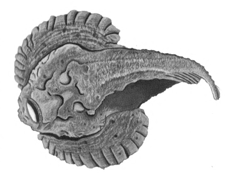

**Figure 2.31:** *Synanceia verrucosa*, reef stonefish

Scorpionfishes and lionfishes were formerly included with stonefishes as Scorpaenidae, but stonefishes have now been classified as a separate family, Synanceiidae. The latter are shallowwater fishes, very sluggish, spending most of their life concealed in mud or among rocks and coral. Most have grotesquely misshapen heads and bodies covered with rough warty skin. If trodden on, they can inject an extremely painful neurotoxin which, in some cases, has proved fatal to man (Munro 1967: p.538). Reflexes of POc *[ñ,n]opu(q) are numerous and widespread. Most Oceanic languages have merged /ñ/ and /n/, so provide no evidence for choosing between competing reconstructions, but Sudest reflects *ñ only, while Titan, Loniu and Wayan reflect *n* only. Lynch (pers. comm.) suggests the *i* of the Naman term *(ni)niv* might be evidence supporting initial *ñ-. Although the referent is consistent throughout almost all Western Oceanic languages, it has apparently become a generic for fishes with poisonous spines, including at least some scorpionfishes in Micronesia, Wayan Fijian and parts of Polynesia.

| **PMP** |  | *ñepuq | ‘stonefish’ (ACD) |
| --- | --- | --- | --- |
| **POc** |  | *(ñ,n)opu(q) | ‘*Synanceia* spp., stonefishes’ |
| Adm | Mussau | *nou* | ‘stonefish’ |
| Adm | Titan | *no* | ‘stonefish, Synanceiidae’ |
| Adm | Loniu | *noh* | ‘k.o. poisonous fish’ |
| NNG | Kove | *nou* | ‘stonefish’ |
| NNG | Tuam | *nov* | ‘stonefish’ |
| NNG | Malai | *nob* | ‘stonefish’ |
| NNG | Tami | *noʔ* | ‘stonefish’ |
| NNG | Takia | *nou* | ‘stonefish’ |
| NNG | Kaiep | *nou* | ‘stonefish’ |
| NNG | Manam | *nou* | ‘stonefish’ |
| PT | Duau | *nohu* | ‘stonefish’ |
| PT | Misima | *nou* | ‘generic for lionfishes, firefishes and stonefishes’ |
| PT | Molima | *novu* | ‘stonefish’ |
| PT | Sudest | *ño* | ‘stonefish’ |
| PT | Motu | *nohu* | ‘stonefish, *Synanceia trachynis*’ |
| PT | Kilivila | *lou, nou* | ‘stonefish’ |
| MM | Vitu | *novu* | ‘stonefish’ |
| MM | Bulu | *novu* | ‘stonefish’ |
| MM | Patpatar | *nuh* | ‘stonefish’ |
| MM | Halia | *nohu* | ‘poisonous stonefish’ |
| MM | Marovo | *novu* | ‘*Synanceia verrucosa*, reef stonefish’ |
| SES | Gela | *novu* | ‘most species of the family Scorpaenidae’ |
| SES | Kwaio | *nofu* | ‘stonefish’ |
| SES | ’Are’are | *nohu* | ‘small black fish with poisonous spikes on head and back, a prick causing severe pain for several days’ |
| SES | Arosi | *nohu* | ‘k.o. fish with spiny ridge’ |
| **PNCV** |  | *novu | ‘scorpion, venomous fish’ (Clark 2009: 158) |
| NCV | Tamambo | *novu* | ‘stonefish, up to 20 cm, changes colour and has poisonous fins’ |
| NCV | Raga | *(bʷati)novu* | ‘*Synanceia* spp., prob. *Synanceia verrucosa*, stonefish’ |
| NCV | Naman | *(ni)niv* | ‘stonefish’ |
| NCV | Kiai | *novu* | ‘scorpion’ |
| SV | Anejom̃ | *ne-no* | ‘*Synanceia verrucosa*’ |
| NCal | Voh-Koné | *neuk* | ‘stonefish’ |
| NCal | Pije | *neuk* | ‘*Synanceia verrucosa*’ |
| Mic | Kiribati | *nou* | ‘Scorpaenidae’ |
| Mic | Chuukese | *nou* | ‘*Synanceia verrucosa*, stonefish’ |
| Mic | Puluwatese | *nōw* | ‘scorpionfish’ |
| **PCP** |  | *novu | ‘*Synanceja verrucosa*, stonefish’ (Geraghty: PCP *hovu) |
| Fij | Rotuman | *nohu* | ‘fish that buries itself in the sand and can inflict a poisonous sting with its fin’ |
| Fij | Bauan | *novu* | ‘fish of an ashen colour, resembling a stone, very rough horny skin’ |
| Fij | Wayan | *novu* | ‘generic for all stonefish and certain scorpionfish which resemble stonefish in appearance and deadly sting’ |
| **PPn** |  | *nofu | ‘*Synanceia verrucosa*, *Scorpaenidae* spp.’ (Hooper 1994) |
| Pn | Tongan | *nofu* | ‘k.o. fish with poisonous spikes’ |
| Pn | Niuean | *nofu* | ‘scorpionfish; stonefish’ |
| Pn | East Uvean | *nofu* | ‘*Synanceia verrucosa*’ |
| Pn | Rennellese | *nohu* | ‘k.o. poisonous fish’ |
| Pn | Pukapukan | *nou (watu)* | ‘*Synanceia verrucosa*’ (*watu* ‘stone’) |
| Pn | Samoan | *nofu* | ‘k.o. fish with poisonous spines, Scorpaenopsis and *Synanceia*’ |
| Pn | Tikopia | *nofu* | ‘stonefish’ |
| Pn | Hawaiian | *nohu* | ‘scorpionfish’ |

## 61. Triggerfishes (Balistidae); filefishes and leatherjackets (Monacanthidae)

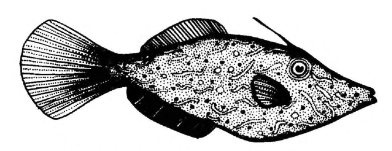

**Figure 2.32:** Monacanthus sp., scribbled leatherjacket

Triggerfishes (Balistidae) are characterised by a football shape, leathery skin, and small mouth with powerful jaws. They are feeble swimmers, herbivorous, generally solitary in habit, seeking shelter among coral heads and weeds. The flesh of many is poisonous, although others are used for food (Munro 1967: p.557). Closely related to Balistidae are the Monacanthidae (formerly Aluteridae), leatherjackets and filefishes. They differ from triggerfish in skin texture, leatherjackets having a leathery skin while that of filefish is rough and velvety (Munro 1967: p.564). Four POc terms are reconstructable, with *jumu the most likely candidate for a generic term. *bubu and *[bʷaRu]bʷaRu may, like *lio-lio, have had more specific reference. Variability of gloss frequently indicates only variability of common names for the same species. For instance, common names for Pseudobalistesfuscus include the yellow-spotted triggerfish (Allen & Swainston 1993) or brown triggerfish (Kailola 1987-1991). Although juveniles have yellow lines and spots, adults have overall dark coloration.

| **POc** |  | *jumu | ‘Balistidae, triggerfish and possibly Monacanthidae, leatherjackets’[^34] |
| --- | --- | --- | --- |
| NNG | Tami | *sum* | ‘*Pseudobalistes flavimarginatus*’ (yellow-margin triggerfish) |
| NNG | Lukep | *dum* | ‘triggerfish, leatherjacket’ |
| PT | Motu | *dumu* | ‘k.o. triggerfish’ |
| NCV | Tamambo | *jumu* | ‘k.o. big fish with strong skin’ |
| NCV | Namakir | *him* | ‘triggerfish’ |
| SV | Anejom̃ | *ne-θomʷ* | ‘*Rhinecanthus* sp., triggerfish’ |
| NCal | Iaai | *(wa)jimü* | ‘*Balistes* sp.’ |
| **PCP** |  | *cumu | ‘Balistoidei, triggerfish’ (Geraghty 1994) |
| Fij | Rotuman | *sumi* | ‘leather jacket’ |
| Fij | Bauan | *sumu-sumu* | ‘fish like the porcupine fish, but with no prickles. *Tetrodon* spp.’ |
| Fij | Wayan | *ðum* | ‘generic for Balistidae and some or all Monacanthidae’ |
| Fij | Kadavu | *ðumu* | ‘*Balistes* and *Cantherhines* spp., smaller than *gau*’ |
| **PPn** |  | *sumu | ‘Balistidae’ (Hooper 1994) |
| Pn | Tongan | *humu* | ‘k.o. fish’ |
| Pn | Niuatoputapu | *humu* | ‘Balistidae, *Rhinecanthus aculeatus*’ (black-barred triggerfish) |
| Pn | Niuean | *humu* | ‘triggerfish’ |
| Pn | East Uvean | *humu* | ‘*Balistes* spp.’ (*humu-humu* ‘generic for Balistidae’) |
| Pn | Samoan | *sumu* | ‘triggerfish of genera *Balistes* and *Balistapus*’ |
| Pn | Tokelauan | *humu* | ‘triggerfish’ |
| Pn | Tikopia | *sumu* | ‘triggerfish and related types, Balistidae and Monocanthidae’ |
| Pn | Hawaiian | *humu-humu* | ‘triggerfish (generic)’ |

| **POc** |  | *bubu | ‘*Balistes* taxon, triggerfish’ |
| --- | --- | --- | --- |
| Adm | Titan | *bupʷ* | ‘triggerfish, Balistidae’ |
| Adm | Seimat | *pup* | ‘k.o. reef fish with one large thorn on the back and several by the tail, good to eat’ |
| NNG | Mangap | *bubu* | ‘k.o. fish’ |
| NNG | Manam | *bubu* | ‘triggerfish’ |
| NNG | Gedaged | *bub* | ‘*Pseudobalistes flavimarginatus*’ (green triggerfish) (Mueller 1985) |
| NNG | Takia | *bub* | ‘*Pseudobalistes flavimarginatus*’ (Mueller 1985) |
| PT | Ubir | *fofo* | ‘k.o. fish’ |
| MM | Sursurunga | *bobo* | ‘triggerfish’ |
| MM | Lihir | *bombo* | ‘*Balistoides viridescens*, *Pseudobalistes flavimarginatus*, larger triggerfishes’ |
| MM | Lihir | *bum* | ‘*Balistopus undulatus*, orange-lined triggerfish, a notorious bait-stealer’ |
| MM | Ramoaaina | *bubu* | ‘k.o. fish’ |
| MM | Teop | *bobo* | ‘some triggerfish spp.’ |
| SES | Lau | *bubu* | ‘triggerfish’ |
| SES | Kwaio | *bubu* | ‘reef triggerfish’ |
| SES | ’Are’are | *pupu* | ‘small fish’ |
| SES | Arosi | *bubu* | ‘k.o. fish, *Balistes*’ (also *bubu baru-baru*) |
| SES | Bauro | *pupu* | ‘*Balistoides viridescens*’ |
| NCV | Vera’a | *bum* | ‘Balistidae’ |
| Mic | Satawalese | *pʷūpʷ* | ‘triggerfish (generic)’ |
| Mic | Kiribati | *pʷupʷu* | ‘generic for triggerfish’ |
| Mic | Chuukese | *pʷūpʷ* | ‘family name for triggerfishes’ |
| Mic | Carolinian | *bʷūbʷ* | ‘triggerfish, Balistidae’ |
| Mic | Mokilese | *pʷupʷ* | ‘triggerfish’ |
| Mic | Ponapean | *pʷūpʷ* | ‘leatherjacket’ (Christian 1899) |

| **POc** |  | *[bʷaRu]bʷaRu | ‘*Balistes* taxon, triggerfish’ |
| --- | --- | --- | --- |
| PT | Sinaugoro | *balu* | ‘*Balistoides conspicillum*, big-spotted triggerfish’ |
| PT | Motu | *baru-baru* | ‘triggerfish, general term’ |
| PT | Lala | *balu-balu* | ‘k.o. reef fish’ |
| PT | Roro | *paru-paru* | ‘k.o. fish’ |
| MM | Lihir | *pial-pial* | ‘Odontus niger, redtooth triggerfish’ |
| MM | Marovo | *baru-baru* | ‘small triggerfish, prob. *Rhinecanthus acideatus*’ |
| SES | Longgu | *balu-balu* | ‘*Balistoides viridescens*’ |
| SES | Langalanga | *balu-balu* | ‘*Balistoides viridescens*’ |
| SES | Arosi | *(bubu)baru-baru* | ‘a large sp. of *Balistes*’ |
| SES | Kahua | *paru-paru* | ‘*Balistoides viridescens*’ |
| NCV | Dorig | *pʷar-pʷar* | ‘Balistoides viridiscens, *Balistoides conspicillum*’ |
| NCV | Namakir | *buru-bar* | ‘triggerfish’ |
| NCV | South Efate | *pʷar-pʷor* | ‘triggerfish’ |
| SV | Anejom̃ | *na-pʷou* | ‘k.o. triggerfish’ |
| NCal | Nêlêmwa | *fʷa* | ‘*Balistes* sp.’ |
| Fij | Nadrogā | *gʷau* | ‘large Balistidae’ |
| Fij | Lau (Eastern Fijian) | *gau* | ‘large Balistidae’ |
| Fij | Kadavu | *gau* | ‘*Balistes* spp., larger than cumu.’ |

cf. also:

| Adm | Titan | *pʷalus* | ‘triggerfish’ |
| --- | --- | --- | --- |
| Adm | Penchal | *pulot* | ‘triggerfish, Balistidae’ |
| Adm | Drehet | *pʷalap* | ‘archerfish, 30-40 cm with alternating black and white triangle pattern’ |
| Mic | Chuukese | *pʷɨnɨ-ɨnɨ* | ‘*Balistoides viridescens*, moustache triggerfish, Titan triggerfish’ |
| Mic | Satawalese | *pœ̄n* | ‘*Pseudobalistes fuscus*, brown triggerfish’ |

The Titan and Penchal forms above reflect *bʷalusV, which may resemble POc *bʷaRu either through chance or by borrowing.

| **POc** |  | *lio-lio | ‘*Pseudobalistes fuscus*, brown triggerfish’ |
| --- | --- | --- | --- |
| MM | Marovo | *(makoto) li-lio* | ‘k.o. large triggerfish’ |
| MM | Nehan | *lio* | ‘triggerfish (generic)’ |
| Mic | Ponapean | *lio-li* | ‘large dark blue species of leatherjacket’ (Christian 1899) |
| Mic | Mokilese | *lio-li* | ‘yellow-spotted triggerfish’ |
| Mic | Kiribati | *nuo-nuo* | ‘fish with poisonous darts on tail, *Balistes fuscus*’ |
| Fij | Rotuman | *lio-lio* | ‘large leatherjacket, called when young *sum fea*’ (*fea* ‘pale’) |